Skip to main content

# Fire weather index trends in the Okanagan basin under the 2025 Canadian Forest Fire Danger Rating System

Author

Seamus Murphy

Published

November 27, 2026

Abstract

In 2025, Canada revised the equations and weather input of its Fire Weather Index System. Published fire danger trends had been computed under earlier versions, as had the fixed index values at which agencies rated danger high or extreme. No study had tested whether these revisions changed those trends. This study used hourly records from five stations in the Okanagan basin, British Columbia, each holding 6 to 27 complete fire seasons between 1991 and 2025. Daily indices were computed under both versions from the 13:00 local time observation and under the 2025 version from hourly weather, giving three series. Trends in twelve metrics were estimated by Theil-Sen slope and Mann-Kendall test with Hamed and Rao’s autocorrelation correction, and slope differences by moving-block bootstrap. Of 144 trends, 140 were positive and 35 passed false discovery rate correction, 33 of them at one station. No slope difference between series excluded zero, so the revision changed no trend detectably. Instead, days per season above a Fine Fuel Moisture Code of 91 rose from 57 to 62 when the 2025 version ran on hourly weather. Combining the two versions in one record would thus add 4.7 days caused by the revision rather than the weather. Under the 2025 version, days above a Fire Weather Index of 19 stayed at 78 on hourly weather but rose to 85 on the 13:00 observation. Fire danger trends could therefore be compared between the two versions, but counts of days above a fixed index value could not.

Keywords

Forest Fire Weather Index System, fire occurrence and ignition, British Columbia, Okanagan, fire danger rating, trend detection

```r
## ---------------------------------------------------------------------------
## Statistical functions for forest-fire-index-trends.
##
## Written 2026-08-15. These are defined here and called from the chunks that
## follow, so that the manuscript carries the machinery it runs.
##
## Three things are done here and each carries a decision that has to be stated
## wherever a number from it is reported.
##
## Trend estimation. The estimator is the Theil-Sen slope, the median of all
## pairwise slopes, chosen because seasonal counts of extreme days are skewed and
## a least squares slope on them is pulled by single seasons. Significance is
## Mann-Kendall with the Hamed and Rao (1998) variance correction, which inflates
## the variance of the S statistic by the autocorrelation actually present in the
## series rather than assuming independence. Serial correlation in seasonal fire
## danger is real and untreated Mann-Kendall over-rejects in its presence, so the
## uncorrected test is reported alongside only to show the size of the effect.
##
## Slope differences between series. The three series are computed from one
## weather record, so they are strongly dependent and a two-sample test on their
## slopes is wrong. The difference is bootstrapped by resampling whole seasons
## with replacement, recomputing both slopes on the same resampled seasons each
## time. The pairing is preserved by construction, so the interval is on the
## difference and not on two separately noisy slopes.
##
## Multiple testing. A metric family is corrected within each series by the
## Benjamini and Hochberg (1995) false discovery rate procedure. The family is
## declared at the call site, not here, because what counts as one family is a
## judgement about the question and not about the arithmetic.
## ---------------------------------------------------------------------------

## Theil-Sen slope with a Mann-Kendall test corrected for serial correlation.
##
## Returns one row: the slope, its bootstrap interval, the corrected and
## uncorrected p values, Kendall's tau, and the effective sample size ratio that
## the correction used. A series shorter than `min_n` returns NA rather than a
## number, because a slope over eight seasons is not an estimate.
## Moving-block bootstrap indices over an ordered season sequence.
##
## Resampling single seasons keeps the pairing between series that share a
## weather record but discards serial correlation within a series. Blocks of
## consecutive seasons keep it (Kunsch 1989). Block length is the cube root of
## the number of seasons, rounded up and at least two, which grows with the
## record but more slowly than it, as Kunsch's consistency condition requires.
## Blocks are drawn from the seasons in order of occurrence, so a gap in the
## record falls inside a block rather than being closed up.
block_length <- function(n) max(2L, as.integer(ceiling(n^(1/3))))
block_indices <- function(n, l = block_length(n)) {
  starts <- sample.int(n - l + 1L, ceiling(n / l), replace = TRUE)
  idx <- as.vector(vapply(starts, function(s) s:(s + l - 1L), integer(l)))
  idx[seq_len(n)]
}

trend_test <- function(year, value, min_n = 15, n_boot = 2000, seed = 20260815) {
  ok <- is.finite(year) & is.finite(value)
  year <- year[ok]; value <- value[ok]
  o <- order(year); year <- year[o]; value <- value[o]
  n <- length(value)

  na_row <- data.frame(n = n, slope = NA_real_, lower = NA_real_, upper = NA_real_,
                       p_corrected = NA_real_, p_uncorrected = NA_real_,
                       tau = NA_real_, n_over_nstar = NA_real_)
  if (n < min_n || length(unique(value)) < 3) return(na_row)

  mk <- tryCatch(modifiedmk::mmkh(as.vector(value)), error = function(e) NULL)
  if (is.null(mk)) return(na_row)

  ## Theil-Sen on the actual years, so a gap in the season sequence is honoured
  ## rather than treated as a step of one.
  slope <- theil_sen(year, value)

  set.seed(seed)
  bs <- vapply(seq_len(n_boot), function(i) {
    k <- block_indices(n)
    theil_sen(year[k], value[k])
  }, numeric(1))

  data.frame(
    n = n,
    slope = slope,
    lower = unname(quantile(bs, 0.025, na.rm = TRUE)),
    upper = unname(quantile(bs, 0.975, na.rm = TRUE)),
    p_corrected = unname(mk["new P-value"]),
    p_uncorrected = unname(mk["old P.value"]),
    tau = unname(mk["Tau"]),
    n_over_nstar = unname(mk["N/N*"])
  )
}

## Median of all pairwise slopes. Returns NA when fewer than two distinct x
## values survive, which happens inside a bootstrap resample.
##
## Written with outer() rather than an index expansion because the bootstraps
## above call it several hundred thousand times and the allocation cost of
## building index vectors on every call dominated the runtime.
theil_sen <- function(x, y) {
  n <- length(x)
  if (n < 3) return(NA_real_)
  dx <- outer(x, x, "-")
  dy <- outer(y, y, "-")
  keep <- lower.tri(dx) & dx != 0
  if (!any(keep)) return(NA_real_)
  median(dy[keep] / dx[keep])
}

## Paired bootstrap on the difference between two series' Theil-Sen slopes.
##
## `wide` must hold one row per season with columns `year`, `a` and `b`. Seasons
## are resampled whole, so both slopes are recomputed on the same seasons in
## every replicate and the dependence between the series is carried through.
slope_difference <- function(wide, n_boot = 4000, seed = 20260815) {
  wide <- wide[is.finite(wide$a) & is.finite(wide$b), ]
  n <- nrow(wide)
  if (n < 15) {
    return(data.frame(n = n, slope_a = NA_real_, slope_b = NA_real_,
                      difference = NA_real_, lower = NA_real_, upper = NA_real_,
                      p_two_sided = NA_real_))
  }
  sa <- theil_sen(wide$year, wide$a)
  sb <- theil_sen(wide$year, wide$b)

  wide <- wide[order(wide$year), ]
  set.seed(seed)
  d <- vapply(seq_len(n_boot), function(i) {
    k <- block_indices(n)
    theil_sen(wide$year[k], wide$b[k]) - theil_sen(wide$year[k], wide$a[k])
  }, numeric(1))
  d <- d[is.finite(d)]

  ## Two sided bootstrap p value computed under the null hypothesis, following
  ## the first guideline of Hall and Wilson (1991): the resampled differences
  ## are centred on the observed difference, and p is the share whose distance
  ## from it is at least as large as the observed difference is from zero,
  ## floored at the resolution the number of replicates can resolve.
  obs <- sb - sa
  p <- mean(abs(d - obs) >= abs(obs))
  data.frame(
    n = n, slope_a = sa, slope_b = sb, difference = sb - sa,
    lower = unname(quantile(d, 0.025)), upper = unname(quantile(d, 0.975)),
    p_two_sided = max(p, 1 / length(d))
  )
}
```

```r
## Benjamini and Hochberg false discovery rate over a declared family.
fdr <- function(p) p.adjust(p, method = "BH")

## Negative binomial count model of daily ignitions on daily fire danger.
##
## Season is a factor, so the danger coefficient is identified only from
## day-to-day variation inside a season. That is deliberate. Reporting
## completeness and cause coding both change between seasons and neither changes
## within one, so a between-season contrast would confound the danger effect with
## the record keeping, and a within-season contrast cannot.
##
## Day of year enters as a pair of annual harmonics, which absorbs the seasonal
## march of both fuel dryness and human activity without spending a parameter per
## day.
ignition_model <- function(d, response, danger, extra = NULL) {
  d <- d[is.finite(d[[danger]]) & is.finite(d[[response]]), ]
  d$.y <- d[[response]]
  d$.x <- d[[danger]]
  d$.s1 <- sin(2 * pi * d$doy / 365.25); d$.c1 <- cos(2 * pi * d$doy / 365.25)
  d$.s2 <- sin(4 * pi * d$doy / 365.25); d$.c2 <- cos(4 * pi * d$doy / 365.25)
  d$.year <- factor(d$year)
  f <- ".y ~ .x + .s1 + .c1 + .s2 + .c2 + .year"
  if (!is.null(extra)) f <- paste(f, "+", extra)
  MASS::glm.nb(as.formula(f), data = d, control = glm.control(maxit = 100))
}

## Out of sample predictive skill, by leaving one season out at a time.
##
## Returns the mean held-out log likelihood per day under the negative binomial
## fitted without that season. Comparing series on held-out likelihood rather
## than on in-sample fit is the point: three series computed from one weather
## record will all fit, and the question is which predicts.
loso_skill <- function(d, response, danger, extra = "n_stations") {
  years <- sort(unique(d$year))
  ll <- numeric(0)
  ## A coefficient can come back NA when its term is collinear inside a training
  ## fold; treating it as zero keeps the fold rather than dropping it silently.
  cf <- function(co, nm) if (nm %in% names(co) && is.finite(co[[nm]])) co[[nm]] else 0

  for (y in years) {
    train <- d[d$year != y, ]
    test <- d[d$year == y, ]
    if (nrow(test) < 30 || length(unique(train$year)) < 5) next
    m <- tryCatch(ignition_model(train, response, danger, extra = extra),
                  error = function(e) NULL)
    if (is.null(m)) next
    ## The held-out season has no fitted year effect, so prediction uses the mean
    ## of the fitted year effects: the model is asked for a typical season, which
    ## is what a forecast for an unobserved season can know.
    co <- coef(m)
    yr_terms <- co[grepl("^\\.year", names(co))]
    eta <- cf(co, "(Intercept)") + mean(c(0, yr_terms), na.rm = TRUE) +
      cf(co, ".x") * test[[danger]] +
      cf(co, ".s1") * sin(2 * pi * test$doy / 365.25) +
      cf(co, ".c1") * cos(2 * pi * test$doy / 365.25) +
      cf(co, ".s2") * sin(4 * pi * test$doy / 365.25) +
      cf(co, ".c2") * cos(4 * pi * test$doy / 365.25)
    if (!is.null(extra) && extra == "n_stations")
      eta <- eta + cf(co, "n_stations") * test$n_stations
    mu <- exp(eta)
    ll <- c(ll, dnbinom(test[[response]], size = m$theta, mu = mu, log = TRUE))
  }
  if (!length(ll)) return(data.frame(n_days = 0L, mean_loglik = NA_real_,
                                     total_loglik = NA_real_))
  data.frame(n_days = length(ll), mean_loglik = mean(ll), total_loglik = sum(ll))
}

## Minimum trend a window of n seasons can detect, at the observed noise level.
##
## Solves for the slope at which a Mann-Kendall test would reject at alpha with
## power 1 - beta, given the residual standard deviation of the series about its
## own Theil-Sen line. This is the quantitative form of what a 35 season window
## cannot resolve, and it is computed rather than asserted.
minimum_detectable_trend <- function(year, value, alpha = 0.05, power = 0.9) {
  ok <- is.finite(year) & is.finite(value)
  year <- year[ok]; value <- value[ok]
  n <- length(value)
  if (n < 10) return(NA_real_)
  s <- theil_sen(year, value)
  resid <- value - (s * (year - mean(year)) + median(value - s * (year - mean(year))))
  sigma <- sd(resid)
  ## Standard error of an ordinary least squares slope is the relevant scale;
  ## Theil-Sen is about 93 per cent as efficient as least squares under normal
  ## errors, so the result is divided by that efficiency to stay honest.
  se <- sigma / sqrt(sum((year - mean(year))^2))
  ## Serial correlation inflates the standard error of a trend by
  ## sqrt((1 + phi) / (1 - phi)) for first-order autoregressive noise with lag-one
  ## autocorrelation phi (Weatherhead et al. 1998). phi is estimated from the
  ## residuals in season order and bounded to [0, 0.9], so that a negative sample
  ## estimate cannot shrink the detectable trend below the independent case.
  r <- resid[order(year)]
  phi <- if (length(r) > 2) suppressWarnings(stats::cor(r[-1], r[-length(r)])) else 0
  phi <- min(max(ifelse(is.finite(phi), phi, 0), 0), 0.9)
  (qnorm(1 - alpha / 2) + qnorm(power)) * se * sqrt((1 + phi) / (1 - phi)) / 0.93
}


## Percentile exceedance counts with the in-base bootstrap correction of Zhang,
## Hegerl, Zwiers and Kenyon (2005).
##
## A threshold estimated from a fixed base period carries sampling error that
## biases counts low inside the base period and high outside it, which a trend
## fitted across the boundary reads as a trend. Zhang et al. removed the jump by
## estimating the count for each in-base year from thresholds that exclude that
## year. For each in-base season j, the base sample is rebuilt with season j
## removed and another base season i duplicated in its place, the threshold is
## re-estimated, and the count in season j is taken; the count for j is the mean
## over every i other than j. Out-of-base seasons use the threshold from the whole
## base period. Zhang et al. estimated calendar-day thresholds; here, as in the
## uncorrected metric, the threshold is estimated from all days of the season
## pooled, so the procedure is adapted to a seasonal rather than daily threshold.
## Quantiles use type 7, the numpy default the uncorrected metric used, and the
## comparison is strictly greater than, as in the uncorrected metric.
inbase_corrected_counts <- function(daily, series, probs = c(90, 95),
                                    reference = c(1991, 2020), min_ref = 500,
                                    component = "fwi") {
  col <- paste0(series, "_", component)
  out <- list()
  for (stn in unique(daily$station_name)) {
    g <- daily[daily$station_name == stn & is.finite(daily[[col]]), c("year", col)]
    names(g)[2] <- "v"
    by_year <- split(g$v, g$year)
    years <- as.integer(names(by_year))
    base <- years[years >= reference[1] & years <= reference[2]]
    base_vals <- unlist(by_year[as.character(base)], use.names = FALSE)
    for (p in probs) {
      if (length(base_vals) < min_ref) {
        cnt <- rep(NA_real_, length(years))
      } else {
        full <- unname(stats::quantile(base_vals, p / 100, type = 7))
        cnt <- vapply(years, function(y) {
          v <- by_year[[as.character(y)]]
          if (!(y %in% base)) return(sum(v > full))
          others <- setdiff(base, y)
          without <- unlist(by_year[as.character(others)], use.names = FALSE)
          mean(vapply(others, function(i) {
            thr <- stats::quantile(c(without, by_year[[as.character(i)]]), p / 100,
                                   type = 7, names = FALSE)
            sum(v > thr)
          }, numeric(1)))
        }, numeric(1))
      }
      out[[length(out) + 1]] <- data.frame(station_name = stn, series = series,
                                           year = years, prob = p, count = cnt)
    }
  }
  do.call(rbind, out)
}
```

```r
# ---------------------------------------------------------------------------
# Which official boundary is "the entire Okanagan watershed"?
#
# Written 2026-08-14, on Seamus's instruction to settle the study area from
# official government geographic data rather than from the identifier the
# framing document carried. The framing named Freshwater Atlas identifier 212,
# which is Turnagain River in the far north of the province and cannot be what
# was meant.
#
# Three official definitions exist and they disagree by a factor of two, so the
# choice has to be made on evidence rather than on the first layer that returns
# a polygon named Okanagan. This script retrieves all three, measures them, and
# measures what the differences between them consist of. Every number the
# framing document and the review protocol quote about the study-area ruling is
# computed here.
#
#   1. WHSE_BASEMAPPING.FWA_WATERSHED_GROUPS_POLY, WATERSHED_GROUP_ID 161, code
#      OKAN. The Freshwater Atlas is the province's authoritative hydrological
#      framework at 1:20,000.
#   2. WHSE_BASEMAPPING.BC_MAJOR_WATERSHEDS, MAJOR_WATERSHED_CODE WA2, named
#      "Okanagan River".
#   3. WHSE_IMAGERY_AND_BASE_MAPS.DRP_SUB_SUB_DRAINAGES_1M_SP, sub-sub-drainage
#      08NM, named "Okanagan". This is the federal Standard Drainage Area
#      Classification of the Water Survey of Canada, generalised to 1:1,000,000
#      and independent of the provincial framework.
#
# Nothing here computes an outcome. It measures polygons.
#
# ---------------------------------------------------------------------------

# The comparison is planar in BC Albers over areas of a few thousand square
# kilometres, where the projection is the appropriate measurement surface and
# s2's spherical predicates only introduce edge cases on the boundary overlaps.
sf::sf_use_s2(FALSE)

CRS_WORK <- 3005                    # NAD83 / BC Albers, metric, per framing

derived_dir <- file.path(root, "02.inputs", "derived")
boundary_csv <- file.path(derived_dir, "study-area-boundary-candidates.csv")

WFS <- "https://openmaps.gov.bc.ca/geo/pub/wfs"

wfs_get <- function(layer, cql = NULL, page = 10000) {
  q <- c(service = "WFS", version = "2.0.0", request = "GetFeature",
         typeName = layer, outputFormat = "application/json",
         srsName = paste0("EPSG:", CRS_WORK), count = page)
  url <- paste0(WFS, "?", paste0(names(q), "=",
                                 vapply(q, utils::URLencode, "", reserved = TRUE),
                                 collapse = "&"))
  if (!is.null(cql))
    url <- paste0(url, "&CQL_FILTER=", utils::URLencode(cql, reserved = TRUE))
  sf::st_make_valid(sf::st_read(url, quiet = TRUE))
}

ha <- function(x) as.numeric(sum(sf::st_area(x))) / 1e4
msg <- function(...) cat(sprintf(...), "\n")

if (!file.exists(boundary_csv)) {
# --- The three candidates --------------------------------------------------
# Freshwater Atlas Watershed Groups, https://catalogue.data.gov.bc.ca/dataset/freshwater-atlas-watershed-groups
fwa <- wfs_get("WHSE_BASEMAPPING.FWA_WATERSHED_GROUPS_POLY",
               "WATERSHED_GROUP_ID=161")
# BC Major Watersheds, https://catalogue.data.gov.bc.ca/dataset/bc-major-watersheds
bcmw <- wfs_get("WHSE_BASEMAPPING.BC_MAJOR_WATERSHEDS",
                "MAJOR_WATERSHED_SYSTEM LIKE '%kanagan%'")
# Water Survey of Canada Sub-Sub-Drainage Areas, https://catalogue.data.gov.bc.ca/dataset/water-survey-of-canada-sub-sub-drainage-areas
wsc <- wfs_get("WHSE_IMAGERY_AND_BASE_MAPS.DRP_SUB_SUB_DRAINAGES_1M_SP",
               "SUB_SUB_DRAINAGE_AREA_CD='08NM'")
# Freshwater Atlas Watershed Groups, https://catalogue.data.gov.bc.ca/dataset/freshwater-atlas-watershed-groups
groups <- wfs_get("WHSE_BASEMAPPING.FWA_WATERSHED_GROUPS_POLY")
# Province of British Columbia, https://catalogue.data.gov.bc.ca/dataset/province-of-british-columbia-legally-defined-administrative-areas-of-bc
prov <- wfs_get("WHSE_LEGAL_ADMIN_BOUNDARIES.ABMS_PROVINCE_SP")

msg("FWA watershed group 161 OKAN   %10.0f ha", ha(fwa))
msg("BC major watershed WA2         %10.0f ha", ha(bcmw))
msg("WSC sub-sub-drainage 08NM      %10.0f ha", ha(wsc))

# --- What BC's major watershed adds ----------------------------------------
# Decomposing WA2 against the Freshwater Atlas groups, rather than eyeballing
# the polygon, is what identifies the extra basin by name.
decompose <- function(target, label) {
  ix <- suppressWarnings(sf::st_intersection(groups, sf::st_union(target)))
  ix$ha <- as.numeric(sf::st_area(ix)) / 1e4
  ix$frac <- ix$ha / groups$AREA_HA[match(ix$WATERSHED_GROUP_ID,
                                          groups$WATERSHED_GROUP_ID)]
  ix <- ix[ix$frac > 0.01, ]
  ix <- ix[order(-ix$ha), ]
  msg("\nFreshwater Atlas groups making up %s:", label)
  for (i in seq_len(nrow(ix)))
    msg("  %-20s %9.0f ha  %5.1f%% of that group",
        ix$WATERSHED_GROUP_NAME[i], ix$ha[i], 100 * ix$frac[i])
  ix
}
wa2_parts <- decompose(bcmw, "BC major watershed WA2 Okanagan River")
nm_parts <- decompose(wsc, "WSC sub-sub-drainage 08NM Okanagan")

# --- Where the federal unit's excess lies ----------------------------------
# 08NM is larger than the Freshwater Atlas group. The question is whether that
# excess is Canadian drainage the provincial group omits, which would matter, or
# the United States portion of the basin, which does not, because the ignition
# record and the fire weather network are both provincial.
resid <- suppressWarnings(sf::st_difference(sf::st_union(wsc), sf::st_union(fwa)))
resid_bc <- suppressWarnings(sf::st_intersection(resid, sf::st_union(prov)))
resid_ha <- ha(resid)
resid_bc_ha <- ha(resid_bc)
msg("\n08NM outside the Freshwater Atlas group: %.0f ha", resid_ha)
msg("  inside British Columbia:  %8.0f ha", resid_bc_ha)
msg("  outside British Columbia: %8.0f ha", resid_ha - resid_bc_ha)

ll <- sf::st_bbox(sf::st_transform(wsc, 4326))
msg("08NM southern limit: %.3f degrees north (the border is 49.000)", ll["ymin"])

# --- Record ----------------------------------------------------------------
similkameen <- wa2_parts$ha[wa2_parts$WATERSHED_GROUP_NAME == "Similkameen River"]
out <- data.frame(
  item = c("fwa_okan_ha", "bcmw_wa2_ha", "wsc_08nm_ha",
           "wa2_similkameen_ha", "nm_outside_fwa_ha", "nm_outside_fwa_in_bc_ha",
           "nm_outside_fwa_outside_bc_ha", "nm_south_limit_deg",
           "agreement_fwa_vs_wsc_in_bc_pct"),
  value = c(round(ha(fwa)), round(ha(bcmw)), round(ha(wsc)),
            round(if (length(similkameen)) similkameen else NA_real_),
            round(resid_ha), round(resid_bc_ha), round(resid_ha - resid_bc_ha),
            round(as.numeric(ll["ymin"]), 3),
            round(100 * resid_bc_ha / ha(fwa), 2)),
  stringsAsFactors = FALSE)
write.csv(out, boundary_csv, row.names = FALSE)
msg("\nWritten 02.inputs/derived/study-area-boundary-candidates.csv")
}

# --- The ruling this evidence supports --------------------------------------
# Recorded here so the reasoning sits beside the numbers rather than only in the
# framing document.
#
# BC's major watershed WA2 is the Freshwater Atlas Okanagan group plus the
# Similkameen group. The two are joined in that layer because the Similkameen
# reaches the Okanogan River in Washington State, not because the Similkameen
# drains to Okanagan Lake. It is a separate valley with its own climate and its
# own fire regime, and no ordinary use of "the Okanagan watershed" includes it.
#
# The federal unit 08NM is the whole binational basin. Almost all of its excess
# over the Freshwater Atlas group is south of the international boundary. Within
# Canada the two frameworks describe the same basin, differing by about one per
# cent, which is what a 1:1,000,000 generalisation costs against 1:20,000.
#
# The study area is therefore Freshwater Atlas watershed group 161, OKAN,
# Okanagan River: the Canadian portion of the Okanagan watershed, entire. The
# United States portion is excluded because the ignition record is the BC
# Wildfire Service historical incident layer and the validation weather is the
# BC Fire Weather Network, neither of which crosses the border. That exclusion
# is a stated boundary of the study, not an oversight.
```

```r
# ---------------------------------------------------------------------------
# Study area layers for the located methods figure.
#
# Written 2026-08-14. Retrieves every layer the study-area map draws, from the
# BC Data Catalogue WFS and the AWS terrain tiles, and writes them to one
# GeoPackage with a checksum manifest. Nothing is hand-digitised and nothing is
# hand-placed: every feature on the map comes from a named public layer that
# this script fetched, so the figure regenerates from code alone.
#
# Study area. Settled 2026-08-14 by Seamus's ruling that the study area is the
# entire Okanagan watershed as official government data defines it. The framing
# document had named "Freshwater Atlas identifier 212", which is Turnagain River
# in the far north and cannot have been meant.
#
# Three official boundaries carry the name and they disagree by a factor of two.
# The chunk above retrieves and measures all three, and
# writes 02.inputs/derived/study-area-boundary-candidates.csv. Its finding: BC's
# major watershed WA2 "Okanagan River", 1,554,467 ha, is this group plus the
# Similkameen, joined only because the Similkameen reaches the Okanogan River in
# Washington; and the federal Water Survey of Canada sub-sub-drainage 08NM,
# 1,203,045 ha, is the whole binational basin, 402,172 ha of it south of the
# border. Within Canada the federal and provincial frameworks agree to 10,327
# ha, 1.3 per cent.
#
# The study area is therefore WATERSHED_GROUP_ID 161, code OKAN, Okanagan River,
# 795,417 ha: the Canadian portion of the Okanagan watershed, entire. The United
# States portion is excluded because neither the BC Wildfire Service incident
# record nor the BC Fire Weather Network crosses the border, and that exclusion
# is a stated boundary of the study.
#
# Nothing here computes an outcome. It retrieves geometry and counts features.
#
# ---------------------------------------------------------------------------

GROUP_ID <- 161                     # FWA watershed group, Okanagan River
FIRST_YEAR <- 1980                  # Framing: 1980 to 2025 fire seasons
LAST_YEAR <- 2025
CRS_WORK <- 3005                    # NAD83 / BC Albers, metric, per framing

spatial_dir <- file.path(root, "02.inputs", "spatial")
derived_dir <- file.path(root, "02.inputs", "derived")
dir.create(spatial_dir, recursive = TRUE, showWarnings = FALSE)
gpkg <- file.path(spatial_dir, "study-area.gpkg")

WFS <- "https://openmaps.gov.bc.ca/geo/pub/wfs"

# The service caps a response at 10,000 features, so every call pages by
# startIndex until a page comes back short. A silent truncation here would put
# the wrong ignition count on the figure, which is exactly the kind of number
# that never gets questioned once it is drawn.
wfs_get <- function(layer, cql = NULL, page = 5000) {
  out <- list()
  start <- 0
  repeat {
    q <- c(service = "WFS", version = "2.0.0", request = "GetFeature",
           typeName = layer, outputFormat = "application/json",
           srsName = paste0("EPSG:", CRS_WORK), count = page,
           startIndex = start)
    url <- paste0(WFS, "?", paste0(names(q), "=", vapply(q, utils::URLencode,
                                                         "", reserved = TRUE),
                                   collapse = "&"))
    if (!is.null(cql))
      url <- paste0(url, "&CQL_FILTER=", utils::URLencode(cql, reserved = TRUE))
    got <- sf::st_read(url, quiet = TRUE)
    out[[length(out) + 1]] <- got
    if (nrow(got) < page) break
    start <- start + page
  }
  do.call(rbind, out)
}

msg <- function(...) cat(sprintf(...), "\n")

if (!file.exists(gpkg)) {
# --- Basin -----------------------------------------------------------------
# Freshwater Atlas Watershed Groups, https://catalogue.data.gov.bc.ca/dataset/freshwater-atlas-watershed-groups
basin <- wfs_get("WHSE_BASEMAPPING.FWA_WATERSHED_GROUPS_POLY",
                 sprintf("WATERSHED_GROUP_ID=%d", GROUP_ID))
stopifnot(nrow(basin) == 1)
msg("Basin: %s (%s), %.0f ha", basin$WATERSHED_GROUP_NAME,
    basin$WATERSHED_GROUP_CODE, basin$AREA_HA)
bb <- sf::st_bbox(basin)
bbox_cql <- sprintf("BBOX(SHAPE,%f,%f,%f,%f,'EPSG:%d')",
                    bb["xmin"], bb["ymin"], bb["xmax"], bb["ymax"], CRS_WORK)

# --- Ignitions -------------------------------------------------------------
# Retrieved on the bounding box, then clipped to the basin polygon, because the
# WFS spatial filter is a rectangle. The clip is what the count reports.
# BC Wildfire Fire Incident Locations, Historical, https://catalogue.data.gov.bc.ca/dataset/bc-wildfire-fire-incident-locations-historical
inc <- wfs_get("WHSE_LAND_AND_NATURAL_RESOURCE.PROT_HISTORICAL_INCIDENTS_SP",
               sprintf("%s AND FIRE_YEAR>=%d AND FIRE_YEAR<=%d",
                       bbox_cql, FIRST_YEAR, LAST_YEAR))
msg("Incidents in bounding box, %d to %d: %d", FIRST_YEAR, LAST_YEAR, nrow(inc))
inc <- inc[lengths(sf::st_intersects(inc, basin)) > 0, ]
msg("Incidents inside the basin: %d", nrow(inc))

# --- Landscape features ----------------------------------------------------
# Freshwater Atlas Lakes, https://catalogue.data.gov.bc.ca/dataset/freshwater-atlas-lakes
lakes <- wfs_get("WHSE_BASEMAPPING.FWA_LAKES_POLY",
                 sprintf("WATERSHED_GROUP_ID=%d AND AREA_HA>100", GROUP_ID))
lakes <- lakes[lengths(sf::st_intersects(lakes, basin)) > 0, ]
msg("Lakes over 100 ha: %d, of which named: %d", nrow(lakes),
    sum(!is.na(lakes$GNIS_NAME_1)))

# Freshwater Atlas Stream Network, https://catalogue.data.gov.bc.ca/dataset/freshwater-atlas-stream-network
streams <- wfs_get("WHSE_BASEMAPPING.FWA_STREAM_NETWORKS_SP",
                   sprintf("WATERSHED_GROUP_ID=%d AND STREAM_ORDER>=5",
                           GROUP_ID))
msg("Stream segments of order 5 or greater: %d", nrow(streams))

# --- Placenames ------------------------------------------------------------
# Municipal boundaries carry the authoritative name; the label goes on the
# centroid. BCGN geographical names is not served on this endpoint.
# Municipalities, Legally Defined Administrative Areas of BC, https://catalogue.data.gov.bc.ca/dataset/municipalities-legally-defined-administrative-areas-of-bc
munis <- wfs_get("WHSE_LEGAL_ADMIN_BOUNDARIES.ABMS_MUNICIPALITIES_SP",
                 bbox_cql)
munis <- munis[lengths(sf::st_intersects(munis, basin)) > 0, ]
places <- sf::st_centroid(sf::st_geometry(munis))
places <- sf::st_sf(name = munis$ADMIN_AREA_NAME,
                    type = munis$ADMIN_AREA_BOUNDARY_TYPE,
                    geometry = places)
msg("Municipalities intersecting the basin: %d", nrow(places))
```

```r
# --- Weather ---------------------------------------------------------------
# BC Fire Weather Network stations. The framing names these as the validation
# source for whatever gridded product is adopted at the design gate.
# BC Wildfire Active Weather Stations, https://catalogue.data.gov.bc.ca/dataset/bc-wildfire-active-weather-stations
stations <- wfs_get("WHSE_LAND_AND_NATURAL_RESOURCE.PROT_WEATHER_STATIONS_SP",
                    bbox_cql)
stations <- stations[lengths(sf::st_intersects(stations, basin)) > 0, ]
msg("Fire weather stations inside the basin: %d", nrow(stations))

# ERA5-Land grid, the leading candidate weather input. Its cells are a fixed
# 0.1 degree geographic graticule, so the geometry is constructed rather than
# downloaded: drawing it states the support at which a candidate climate input
# would be resolved, which is the point of putting it on a methods map. No
# ERA5-Land values are retrieved, because the weather source is not settled.
b_ll <- sf::st_bbox(sf::st_transform(basin, 4326))
gx <- seq(floor(b_ll["xmin"] * 10) / 10, ceiling(b_ll["xmax"] * 10) / 10, 0.1)
gy <- seq(floor(b_ll["ymin"] * 10) / 10, ceiling(b_ll["ymax"] * 10) / 10, 0.1)
era5 <- sf::st_as_sf(sf::st_make_grid(
  sf::st_as_sfc(sf::st_bbox(c(xmin = min(gx), ymin = min(gy),
                              xmax = max(gx), ymax = max(gy)),
                            crs = 4326)),
  cellsize = 0.1, offset = c(min(gx), min(gy))))
names(era5)[1] <- "geometry"
sf::st_geometry(era5) <- "geometry"
era5 <- sf::st_transform(era5, CRS_WORK)
era5 <- era5[lengths(sf::st_intersects(era5, basin)) > 0, ]
msg("ERA5-Land 0.1 degree cells intersecting the basin: %d", nrow(era5))

# --- Province, for the inset -----------------------------------------------
# Province of British Columbia, https://catalogue.data.gov.bc.ca/dataset/province-of-british-columbia-legally-defined-administrative-areas-of-bc
prov <- wfs_get("WHSE_LEGAL_ADMIN_BOUNDARIES.ABMS_PROVINCE_SP")
msg("Province polygons: %d", nrow(prov))

# --- Terrain ---------------------------------------------------------------
# Landscape relief. AWS terrain tiles via elevatr, zoom 9, roughly 300 m in
# these latitudes, which is enough for a hillshade at page scale and small
# enough to keep on an 8 GB machine.
dem_path <- file.path(spatial_dir, "dem-z9.tif")
if (!file.exists(dem_path)) {
  # AWS Terrain Tiles, https://registry.opendata.aws/terrain-tiles/
  dem <- elevatr::get_elev_raster(
    locations = sf::st_as_sf(sf::st_as_sfc(sf::st_bbox(
      sf::st_buffer(basin, 5000)))),
    z = 9, clip = "bbox", prj = sf::st_crs(basin)$wkt)
  terra::writeRaster(terra::rast(dem), dem_path, overwrite = TRUE)
}
dem <- terra::rast(dem_path)
msg("DEM: %d by %d cells, %.0f m resolution, elevation %.0f to %.0f m",
    nrow(dem), ncol(dem), terra::res(dem)[1],
    terra::global(dem, "min", na.rm = TRUE)[1, 1],
    terra::global(dem, "max", na.rm = TRUE)[1, 1])

# --- Write -----------------------------------------------------------------
if (file.exists(gpkg)) file.remove(gpkg)
w <- function(x, layer) sf::st_write(x, gpkg, layer, quiet = TRUE, append = FALSE)
w(basin, "basin"); w(inc, "ignitions"); w(lakes, "lakes"); w(streams, "streams")
w(places, "places"); w(stations, "stations"); w(era5, "era5_grid")
w(prov, "province")
msg("\nWritten %s", gpkg)

# --- Counts the manuscript cites -------------------------------------------
# Written to derived/ and committed, because the prose quotes them and no number
# may be quoted from code that was not saved.
cause <- as.character(inc$FIRE_CAUSE)
cause[is.na(cause) | cause == ""] <- "Unknown"
counts <- data.frame(
  item = c("watershed_group_id", "watershed_group_name", "basin_area_ha",
           "first_year", "last_year", "n_seasons",
           "ignitions_total", sprintf("ignitions_%s", sort(unique(cause))),
           "fire_weather_stations", "era5_land_cells",
           "dem_min_elev_m", "dem_max_elev_m"),
  value = c(GROUP_ID, basin$WATERSHED_GROUP_NAME, round(basin$AREA_HA),
            FIRST_YEAR, LAST_YEAR, LAST_YEAR - FIRST_YEAR + 1,
            nrow(inc), as.integer(table(cause)[sort(unique(cause))]),
            nrow(stations), nrow(era5),
            round(terra::global(dem, "min", na.rm = TRUE)[1, 1]),
            round(terra::global(dem, "max", na.rm = TRUE)[1, 1])),
  stringsAsFactors = FALSE)
write.csv(counts, file.path(derived_dir, "study-area-counts.csv"),
          row.names = FALSE)

# Per-season ignition counts by cause, so the figure's inset series and any
# prose about the record come from one saved file.
season <- data.frame(year = inc$FIRE_YEAR, cause = cause)
tab <- as.data.frame(table(season$year, season$cause))
names(tab) <- c("fire_year", "fire_cause", "n")
tab$fire_year <- as.integer(as.character(tab$fire_year))
write.csv(tab[order(tab$fire_year, tab$fire_cause), ],
          file.path(derived_dir, "ignitions-by-season.csv"), row.names = FALSE)

msg("Written %s and %s", "02.inputs/derived/study-area-counts.csv",
    "02.inputs/derived/ignitions-by-season.csv")

# --- Integrity manifest ----------------------------------------------------
files <- list.files(spatial_dir, full.names = TRUE, pattern = "[.](gpkg|tif)$")
sums <- vapply(files, function(f) as.character(tools::md5sum(f)), "")
writeLines(sprintf("%s  %s", sums, basename(files)),
           file.path(spatial_dir, "MD5SUMS.txt"))
msg("Retrieved %s. No outcome variable computed.", format(Sys.Date()))
}
```

```python
"""Retrieve the hourly fire weather record for the Okanagan basin stations.

Written 2026-08-15. Source is the BC Wildfire Service weather data mart, a public
directory published by the BC Ministry of Forests at

    https://www.for.gov.bc.ca/ftp/HPR/external/!publish/BCWS_DATA_MART/

The archive is stored two ways and this script reads both. Seasons 1987 to 2023
are one comma-separated file per year, province wide, named
``<year>/<year>_BCWS_WX_OBS.csv``, the largest of which is roughly 210 MB.
Seasons 2024 onward are one file per calendar day, named ``<year>/<date>.csv``.
Nothing here holds a whole provincial year in memory: each response is streamed
and every row whose station code is not one of the basin stations is dropped as
it arrives.

Station selection is not by bounding box. The five stations are the ones the
BC Data Catalogue layer ``WHSE_LAND_AND_NATURAL_RESOURCE.PROT_WEATHER_STATIONS_SP``
places inside Freshwater Atlas watershed group 161, already clipped to the basin
polygon by the study area chunk above and stored in the ``stations`` layer
of ``02.inputs/spatial/study-area.gpkg``. This script reads that layer rather
than repeating the spatial test, so the two cannot disagree.

The columns kept are the raw hourly observations, the operational FWI1987 codes
that BC Wildfire Service itself computed at the time, and the daily
accumulated precipitation. The operational codes are kept for one purpose: they
are an independent check on this project's own FWI1987 implementation, computed
by a different party with different code, and the series computation chunk
reports the agreement.

Output is written uncompressed to ``02.inputs/weather/bcws-okanagan-hourly.csv``,
which is gitignored for size, together with a small retrieval log at
``02.inputs/derived/fire-weather-retrieval-log.csv`` that is committed.
"""
```

```python
from __future__ import annotations

import csv
import datetime as dt
import io
import os
import sys
import time

import requests

BASE = "https://www.for.gov.bc.ca/ftp/HPR/external/!publish/BCWS_DATA_MART"

# Columns carried forward from the data mart. The names are the data mart's own.
KEEP = [
    "STATION_CODE",
    "STATION_NAME",
    "DATE_TIME",
    "HOURLY_PRECIPITATION",
    "HOURLY_TEMPERATURE",
    "HOURLY_RELATIVE_HUMIDITY",
    "HOURLY_WIND_SPEED",
    "HOURLY_WIND_DIRECTION",
    "HOURLY_FINE_FUEL_MOISTURE_CODE",
    "HOURLY_INITIAL_SPREAD_INDEX",
    "HOURLY_FIRE_WEATHER_INDEX",
    "PRECIPITATION",
    "FINE_FUEL_MOISTURE_CODE",
    "DUFF_MOISTURE_CODE",
    "DROUGHT_CODE",
    "INITIAL_SPREAD_INDEX",
    "BUILDUP_INDEX",
    "FIRE_WEATHER_INDEX",
]


def basin_station_codes(root: str) -> dict[str, str]:
    """Station codes inside watershed group 161, read from the study area package."""
    import geopandas as gpd

    gpkg = os.path.join(root, "02.inputs", "spatial", "study-area.gpkg")
    st = gpd.read_file(gpkg, layer="stations")
    return {str(int(c)): str(n) for c, n in zip(st["STATION_CODE"], st["STATION_NAME"])}


def stream_csv(url: str, session: requests.Session, retries: int = 4):
    """Yield dict rows from a remote CSV without holding the file in memory."""
    for attempt in range(retries):
        try:
            with session.get(url, stream=True, timeout=(30, 600)) as r:
                if r.status_code == 404:
                    return
                r.raise_for_status()
                lines = (
                    b.decode("utf-8-sig", errors="replace")
                    for b in r.iter_lines(chunk_size=1 << 20)
                )
                for row in csv.DictReader(lines):
                    yield row
                return
        except Exception as exc:  # network faults are expected over 4 GB of transfer
            if attempt == retries - 1:
                raise
            print(f"    retry {attempt + 1} after {type(exc).__name__}: {exc}", flush=True)
            time.sleep(5 * (attempt + 1))


def main() -> None:
    first, last = 1987, 2025
    root = os.path.abspath("..")
    stations = basin_station_codes(root)
    print("Basin stations:", ", ".join(f"{c} {n}" for c, n in sorted(stations.items())), flush=True)

    out_dir = os.path.join(root, "02.inputs", "weather")
    os.makedirs(out_dir, exist_ok=True)
    out_path = os.path.join(out_dir, "bcws-okanagan-hourly.csv")
    log_path = os.path.join(root, "02.inputs", "derived", "fire-weather-retrieval-log.csv")

    session = requests.Session()
    session.headers["User-Agent"] = "forest-fire-index-trends/1.0 (research; contact repository owner)"

    log: list[dict] = []
    kept_total = 0

    with open(out_path, "w", newline="") as fh:
        writer = csv.DictWriter(fh, fieldnames=KEEP, extrasaction="ignore")
        writer.writeheader()

        for year in range(first, last + 1):
            t0 = time.time()
            kept = 0
            seen = 0

            # BCWS Weather Data Mart, https://www.for.gov.bc.ca/ftp/HPR/external/!publish/BCWS_DATA_MART/
            # Seasons 1987 to 2023: one provincial file per year.
            annual = f"{BASE}/{year}/{year}_BCWS_WX_OBS.csv"
            got_annual = False
            for row in stream_csv(annual, session):
                got_annual = True
                seen += 1
                if str(row.get("STATION_CODE", "")).strip().strip('"') in stations:
                    writer.writerow(row)
                    kept += 1

            # Seasons 2024 onward: one file per calendar day.
            if not got_annual:
                day = dt.date(year, 1, 1)
                end = dt.date(year, 12, 31)
                while day <= end:
                    url = f"{BASE}/{year}/{day.isoformat()}.csv"
                    for row in stream_csv(url, session):
                        seen += 1
                        if str(row.get("STATION_CODE", "")).strip().strip('"') in stations:
                            writer.writerow(row)
                            kept += 1
                    day += dt.timedelta(days=1)

            kept_total += kept
            elapsed = round(time.time() - t0, 1)
            layout = "annual" if got_annual else "daily"
            print(f"{year}  {layout:6s}  rows seen {seen:>9,}  kept {kept:>7,}  {elapsed:>7.1f}s", flush=True)
            log.append(
                {"year": year, "layout": layout, "rows_seen": seen, "rows_kept": kept, "seconds": elapsed}
            )

    with open(log_path, "w", newline="") as fh:
        w = csv.DictWriter(fh, fieldnames=["year", "layout", "rows_seen", "rows_kept", "seconds"])
        w.writeheader()
        w.writerows(log)

    print(f"\nWrote {kept_total:,} hourly observations to {out_path}", flush=True)
    print(f"Retrieval log at {log_path}", flush=True)


if not os.path.exists(os.path.join("..", "02.inputs", "weather", "bcws-okanagan-hourly.csv")):
    main()
```

```python
"""The 1987 Canadian Forest Fire Weather Index System, daily, from the 13:00 observation.

Written 2026-08-15. This is FWI1987 as specified by Van Wagner (1987), Forestry
Technical Report 35, whose equations are the FORTRAN listing of Van Wagner and
Pickett (1985), Forestry Technical Report 33. The two changes FWI2025 makes to
the fire behaviour outputs are deliberately NOT applied here: the Initial Spread
Index uses the original wind function, not the Fire Behaviour Prediction System
limiter, because the point of this module is to reproduce the legacy system that
every published Canadian fire danger trend rests on.

Day length factors are the standard Canadian tables. The Duff Moisture Code
factors Le are Van Wagner's table for 46 degrees north and the Drought Code
factors Lf are his table for the same latitude. Canadian operational practice
applies these tables across the country rather than interpolating by latitude,
and BC Wildfire Service does so at the stations used here, so the same tables are
used rather than a latitude adjustment that the comparison series would not share.

Nothing in this module is original. It exists so that FWI1987 and FWI2025 are
computed inside one process from one weather record, and it is checked twice:
against the CRAN package cffdrs, an independent published implementation, and
against the FWI1987 codes BC Wildfire Service itself computed operationally at
these stations at the time. Both checks are run by
the next two chunks and their results are reported in the Results rather than
asserted here.

References
    Van Wagner, C.E. 1987. Development and structure of the Canadian Forest Fire
        Weather Index System. Forestry Technical Report 35. Canadian Forestry
        Service, Ottawa.
    Van Wagner, C.E.; Pickett, T.L. 1985. Equations and FORTRAN program for the
        Canadian Forest Fire Weather Index System. Forestry Technical Report 33.
        Canadian Forestry Service, Ottawa.
"""
```

```python
from __future__ import annotations

import math

import numpy as np
import pandas as pd

# Van Wagner (1987) Table 3.1: effective day length for the DMC, 46 degrees north.
DAY_LENGTH_DMC = [6.5, 7.5, 9.0, 12.8, 13.9, 13.9, 12.4, 10.9, 9.4, 8.0, 7.0, 6.0]

# Van Wagner (1987) Table 4.1: day length adjustment for the DC, 46 degrees north.
DAY_LENGTH_DC = [-1.6, -1.6, -1.6, 0.9, 3.8, 5.8, 6.4, 5.0, 2.4, 0.4, -1.6, -1.6]

# The coefficient of the FFMC to moisture content transform. Van Wagner (1987,
# equations 2a and 2b, p. 4) and the 1985 FORTRAN listing (statements 110 and
# 150, p. 14) both print 147.2. The value used here is 59.5 * 250 / 101 =
# 147.27722772, which gives a moisture content of exactly 250 per cent at a
# code of zero. The cffdrs package 1.9.2 (FFMC_COEFFICIENT) and the FWI2025
# reference implementation (C_FFMC = 14875 / 101) both use it, and a rounded
# constant would put a difference of its own into the version comparison.
FFMC_COEFFICIENT = 147.2772277227723

# Startup values, Van Wagner (1987) section 6, and the defaults the NG-CFFDRS
# reference implementation uses, so the three series start from one point.
FFMC_START = 85.0
DMC_START = 6.0
DC_START = 15.0


def ffmc(temp: float, rh: float, ws: float, prec: float, ffmc_prev: float) -> float:
    """Fine Fuel Moisture Code. Van Wagner (1987) equations 1 to 10."""
    mo = FFMC_COEFFICIENT * (101.0 - ffmc_prev) / (59.5 + ffmc_prev)  # eq 1

    if prec > 0.5:                                                  # eq 2, 3a, 3b
        rf = prec - 0.5
        # Both the test and the second term take the moisture content before the
        # rain is applied, not after it. Van Wagner writes mo on the right hand
        # side of 3b throughout.
        wetting = 42.5 * rf * math.exp(-100.0 / (251.0 - mo)) * (1.0 - math.exp(-6.93 / rf))
        if mo > 150.0:
            wetting += 0.0015 * (mo - 150.0) ** 2 * math.sqrt(rf)
        mo = min(mo + wetting, 250.0)

    ed = (                                                          # eq 4
        0.942 * rh ** 0.679
        + 11.0 * math.exp((rh - 100.0) / 10.0)
        + 0.18 * (21.1 - temp) * (1.0 - math.exp(-0.115 * rh))
    )

    if mo > ed:
        ko = 0.424 * (1.0 - (rh / 100.0) ** 1.7) + 0.0694 * math.sqrt(ws) * (
            1.0 - (rh / 100.0) ** 8
        )                                                           # eq 6a
        kd = ko * 0.581 * math.exp(0.0365 * temp)                    # eq 6b
        m = ed + (mo - ed) * 10.0 ** (-kd)                           # eq 8
    else:
        ew = (                                                       # eq 5
            0.618 * rh ** 0.753
            + 10.0 * math.exp((rh - 100.0) / 10.0)
            + 0.18 * (21.1 - temp) * (1.0 - math.exp(-0.115 * rh))
        )
        if mo < ew:
            kl = 0.424 * (1.0 - ((100.0 - rh) / 100.0) ** 1.7) + 0.0694 * math.sqrt(
                ws
            ) * (1.0 - ((100.0 - rh) / 100.0) ** 8)                  # eq 7a
            kw = kl * 0.581 * math.exp(0.0365 * temp)                # eq 7b
            m = ew - (ew - mo) * 10.0 ** (-kw)                       # eq 9
        else:
            m = mo

    return max(0.0, min(101.0, 59.5 * (250.0 - m) / (FFMC_COEFFICIENT + m)))  # eq 10


def dmc(temp: float, rh: float, prec: float, dmc_prev: float, month: int) -> float:
    """Duff Moisture Code. Van Wagner (1987) equations 11 to 17."""
    p = dmc_prev

    if prec > 1.5:                                                   # eq 11
        re = 0.92 * prec - 1.27
        # eq 12, in the FORTRAN listing's form, 280 / exp(0.023 P), rather than
        # the paper's 20 + exp((244.72 - P) / 43.43). The two agree to about one
        # part in four thousand and the listing is what the published code runs.
        mo = 20.0 + 280.0 / math.exp(0.023 * p)                       # eq 12
        if p <= 33.0:                                                # eq 13a
            b = 100.0 / (0.5 + 0.3 * p)
        elif p <= 65.0:                                              # eq 13b
            b = 14.0 - 1.3 * math.log(p)
        else:                                                        # eq 13c
            b = 6.2 * math.log(p) - 17.2
        mr = mo + 1000.0 * re / (48.77 + b * re)                      # eq 14
        # eq 15, again in the listing's form: 43.43 (5.6348 - ln(Mr - 20)) rather
        # than the paper's 244.72 - 43.43 ln(Mr - 20). 43.43 x 5.6348 = 244.7194.
        p = max(0.0, 43.43 * (5.6348 - math.log(mr - 20.0)))          # eq 15

    if temp > -1.1:                                                   # eq 16
        k = 1.894 * (temp + 1.1) * (100.0 - rh) * DAY_LENGTH_DMC[month - 1] * 1e-6
    else:
        k = 0.0

    return max(0.0, p + 100.0 * k)                                    # eq 17


def dc(temp: float, prec: float, dc_prev: float, month: int) -> float:
    """Drought Code. Van Wagner (1987) equations 18 to 23."""
    d = dc_prev

    if prec > 2.8:                                                    # eq 18
        rd = 0.83 * prec - 1.27
        qo = 800.0 * math.exp(-d / 400.0)                              # eq 19
        qr = qo + 3.937 * rd                                           # eq 20
        d = max(0.0, 400.0 * math.log(800.0 / qr))                     # eq 21

    v = 0.36 * (max(temp, -2.8) + 2.8) + DAY_LENGTH_DC[month - 1]      # eq 22
    v = max(0.0, v)

    return max(0.0, d + 0.5 * v)                                       # eq 23


def isi(ws: float, ffmc_val: float) -> float:
    """Initial Spread Index, the original wind function. Van Wagner (1987) eq 24 to 26.

    FWI2025 replaces the wind function here with the Fire Behaviour Prediction
    System form, which limits the effect of winds above 40 km/h. That change is
    not applied in this module by design.
    """
    m = FFMC_COEFFICIENT * (101.0 - ffmc_val) / (59.5 + ffmc_val)      # eq 1
    fw = math.exp(0.05039 * ws)                                        # eq 24
    ff = 91.9 * math.exp(-0.1386 * m) * (1.0 + m ** 5.31 / 4.93e7)     # eq 25
    return 0.208 * fw * ff                                             # eq 26


def bui(dmc_val: float, dc_val: float) -> float:
    """Buildup Index. Van Wagner (1987) equations 27a and 27b."""
    if dmc_val == 0.0 and dc_val == 0.0:
        return 0.0
    if dmc_val <= 0.4 * dc_val:                                        # eq 27a
        u = 0.8 * dmc_val * dc_val / (dmc_val + 0.4 * dc_val)
    else:                                                              # eq 27b
        u = dmc_val - (1.0 - 0.8 * dc_val / (dmc_val + 0.4 * dc_val)) * (
            0.92 + (0.0114 * dmc_val) ** 1.7
        )
    return max(0.0, u)


def fwi(isi_val: float, bui_val: float) -> float:
    """Fire Weather Index. Van Wagner (1987) equations 28 to 31."""
    if bui_val <= 80.0:                                                # eq 28a
        fd = 0.626 * bui_val ** 0.809 + 2.0
    else:                                                              # eq 28b
        fd = 1000.0 / (25.0 + 108.64 * math.exp(-0.023 * bui_val))
    b = 0.1 * isi_val * fd                                             # eq 29
    if b > 1.0:                                                        # eq 30
        return math.exp(2.72 * (0.434 * math.log(b)) ** 0.647)
    return b                                                           # eq 31


def dsr(fwi_val: float) -> float:
    """Daily Severity Rating. Van Wagner (1987) equation 32."""
    return 0.0272 * fwi_val ** 1.77


def fwi1987_run(
    df: pd.DataFrame,
    ffmc_old: float = FFMC_START,
    dmc_old: float = DMC_START,
    dc_old: float = DC_START,
) -> pd.DataFrame:
    """Run FWI1987 over one station-season of daily 13:00 observations.

    Parameters
    ----------
    df
        Daily weather with columns ``yr``, ``mon``, ``day``, ``temp``, ``rh``,
        ``ws``, ``prec``, in chronological order, one row per day, no gaps.
        Temperature in degrees Celsius, relative humidity in per cent, wind speed
        in kilometres per hour at 10 m, precipitation the 24 hour total in
        millimetres ending at the observation.
    ffmc_old, dmc_old, dc_old
        Startup values carried into the first day.

    Returns
    -------
    The input frame with ``ffmc``, ``dmc``, ``dc``, ``isi``, ``bui``, ``fwi`` and
    ``dsr`` appended.
    """
    out = {k: np.empty(len(df)) for k in ("ffmc", "dmc", "dc", "isi", "bui", "fwi", "dsr")}
    f, p, d = ffmc_old, dmc_old, dc_old

    for i, row in enumerate(df.itertuples(index=False)):
        t, h, w, r, mon = row.temp, row.rh, row.ws, row.prec, int(row.mon)
        # Van Wagner's equations are undefined outside these ranges and the
        # operational convention is to clamp rather than to drop the day.
        h = min(max(h, 0.0), 100.0)
        w = max(w, 0.0)
        r = max(r, 0.0)

        f = ffmc(t, h, w, r, f)
        p = dmc(t, h, r, p, mon)
        d = dc(t, r, d, mon)
        i_ = isi(w, f)
        u = bui(p, d)
        s = fwi(i_, u)

        out["ffmc"][i], out["dmc"][i], out["dc"][i] = f, p, d
        out["isi"][i], out["bui"][i], out["fwi"][i] = i_, u, s
        out["dsr"][i] = dsr(s)

    return df.assign(**out)
```

```python
"""Check this project's FWI1987 module against an independent implementation.

Written 2026-08-15. The FWI1987 chunk above is code written for this study, so
no number it produces is reportable until something else produces the same
number. This script runs the first of two checks: the CRAN package ``cffdrs``,
the implementation published with Wang et al. (2017) and maintained by the
Canadian Forest Service, run over the same input through R.

The test input is the Petawawa Research Forest 2007 daily weather that ships
with the NG-CFFDRS repository, used here only because it is a public file with a
known provenance that both implementations can read. The second check, against
the FWI1987 codes BC Wildfire Service computed operationally at the Okanagan
stations, is run inside the series computation chunk where those codes are
already in hand.

Writes ``02.inputs/derived/fwi1987-validation.csv``, which is committed.
"""
```

```python
from __future__ import annotations

import os
import subprocess
import sys
import tempfile

import numpy as np
import pandas as pd

ROOT = os.path.abspath("..")
HERE = os.path.join(ROOT, "05.scripts")

R_BIN = "/usr/local/bin/R"

R_SCRIPT = r"""
suppressPackageStartupMessages(library(cffdrs))
inp <- read.csv("{inp}")
inp$long <- -abs(inp$long)
# lat.adjust = FALSE holds the day length tables at Van Wagner's 46 degrees north
# values, which is what the Python module uses and what Canadian operational
# practice applies across the country.
out <- fwi(inp, init = c(ffmc = 85, dmc = 6, dc = 15, lat = inp$lat[1]),
           lat.adjust = FALSE)
write.csv(out[, c("FFMC", "DMC", "DC", "ISI", "BUI", "FWI", "DSR")],
          "{out}", row.names = FALSE)
"""


def main() -> None:
    # NG-CFFDRS reference implementation test record, https://github.com/nrcan-cfs-fire/cffdrs-ng
    src = os.path.join(HERE, "vendor", "cffdrs-ng", "PRF2007_daily_wx.csv")
    daily = pd.read_csv(src)

    mine = fwi1987_run(daily.copy())

    with tempfile.TemporaryDirectory() as tmp:
        inp = os.path.join(tmp, "in.csv")
        outp = os.path.join(tmp, "out.csv")
        daily.to_csv(inp, index=False)
        script = os.path.join(tmp, "run.R")
        with open(script, "w") as fh:
            fh.write(R_SCRIPT.format(inp=inp, out=outp))
        res = subprocess.run(
            [R_BIN, "--vanilla", "--quiet", "-f", script],
            capture_output=True,
            text=True,
        )
        if not os.path.exists(outp):
            sys.exit(f"cffdrs run failed:\n{res.stdout}\n{res.stderr}")
        theirs = pd.read_csv(outp)

    rows = []
    for a, b in [("ffmc", "FFMC"), ("dmc", "DMC"), ("dc", "DC"),
                 ("isi", "ISI"), ("bui", "BUI"), ("fwi", "FWI"), ("dsr", "DSR")]:
        x, y = mine[a].to_numpy(float), theirs[b].to_numpy(float)
        rows.append(
            {
                "component": b,
                "n": len(x),
                "max_abs_diff": float(np.nanmax(np.abs(x - y))),
                "mean_abs_diff": float(np.nanmean(np.abs(x - y))),
                "max_value": float(np.nanmax(y)),
            }
        )

    res = pd.DataFrame(rows)
    dest = os.path.join(ROOT, "02.inputs", "derived", "fwi1987-validation.csv")
    res.to_csv(dest, index=False)
    print(res.to_string(index=False))
    print(f"\nWrote {dest}")


if not os.path.exists(os.path.join("..", "02.inputs", "derived", "fwi1987-validation.csv")):
    main()
```

```python
# The FWI2025 reference implementation against its own distributed standard
# output, the Petawawa Research Forest 2007 hourly record that ships with it.
# NG-CFFDRS reference implementation and test record,
# https://github.com/nrcan-cfs-fire/cffdrs-ng, vendored at the commit recorded in
# 05.scripts/vendor/cffdrs-ng/COMMIT.txt.
def _check_fwi2025_reference():
    import os, sys
    root = os.path.abspath("..")
    out = os.path.join(root, "02.inputs", "derived", "fwi2025-reference-check.csv")
    if os.path.exists(out):
        return
    import pandas as pd
    vend = os.path.join(root, "05.scripts", "vendor", "cffdrs-ng")
    sys.path.insert(0, vend)
    from NG_FWI import hFWI
    wx = pd.read_csv(os.path.join(vend, "PRF2007_hourly_wx.csv"))
    std = pd.read_csv(os.path.join(vend, "PRF2007_standard_hourly_FWI.csv"))
    run = hFWI(wx, silent=True)
    both = std.merge(run, on=["yr", "mon", "day", "hr"], suffixes=("_std", "_run"))
    assert len(both) == len(std) == len(run)
    pd.DataFrame([{"component": c, "hours": len(both),
                   "max_abs_diff": float((both[c + "_run"] - both[c + "_std"]).abs().max())}
                  for c in ["ffmc", "dmc", "dc", "isi", "bui", "fwi", "dsr"]]).to_csv(out, index=False)

_check_fwi2025_reference()
```

```r
ref_chk <- read.csv(file.path(derived, "fwi2025-reference-check.csv"))
```

```python
"""Compute the three fire danger series from one Okanagan weather record.

Written 2026-08-15. The design question is that FWI1987 and FWI2025 differ in two
respects at once, the version of the system and the resolution of the weather
driving it, so a two way comparison could not attribute a difference to either.
Three series are computed from a single hourly weather record so that each
contrast moves one thing:

    S1  FWI1987, driven by the daily 13:00 observation.
    S2  FWI2025, driven by the same daily 13:00 observation, pathway C.
    S3  FWI2025, driven by the observed hourly weather, pathway A.

S1 against S2 isolates the version change at fixed input. S2 against S3 isolates
the input resolution change at fixed version. S1 against S3 is the operational
contrast an agency faces and is the sum of the other two.

Weather record
    BC Wildfire Service hourly observations at the five fire weather stations
    inside Freshwater Atlas watershed group 161, retrieved by
    the retrieval chunk above. Timestamps are Pacific Standard Time
    year round, which this script does not assume but verifies: the daily
    FWI1987 codes that BC Wildfire Service computed operationally appear in the
    record at hour 12 and at no other hour, and the standard fire weather
    observation is 13:00 Local Daylight Time, so hour 12 is 13:00 LDT and the
    stamp is Local Standard Time, UTC-8.

Season window
    A fixed calendar window, not a weather derived one. The Canadian rule in
    GLC-X-42 section C-2.3, three days above 12 degrees Celsius where snow cover
    cannot be observed, was implemented first and then abandoned, because these
    stations do not report through the winter and the rule fired on whatever day
    a station was switched on. It produced a "season" of three days at Brenda
    Mines in 1991 and 244 days at Fintry in 1999, and those numbers describe
    field operations rather than climate.

    The window is therefore 1 May to 30 September, 153 days, with the calculation
    spun up from 1 April so that thirty days of weather precede the first reported
    day. One consequence is stated rather than repaired: fire season length cannot
    be estimated from a network whose stations are switched on and off for
    operational reasons, so it is not among the metrics, and the seasonal metrics
    that remain are counts and sums over a window of fixed length.

Startup and overwintering
    Each station season starts from FFMC 85, DMC 6, DC 15, the values Van Wagner
    (1987) gives and the NG-CFFDRS reference implementation defaults to. The
    Drought Code is not overwintered. These stations do not report through the
    winter, so an overwintering calculation would have no weather to run on. The
    same startup is used for all three series, so it cannot bias a contrast
    between them.

Daily summary of the hourly series
    FWI1987 produces one value per day. FWI2025 produces one per hour, and
    GLC-X-42 section 3.1.1 says the daily interpretation may be taken either at a
    user selected hour or at the modelled peak. This script writes both. The
    primary daily value is taken at 16:00 LST, which is 17:00 Local Daylight Time,
    the conventional peak burn hour and, in this record, the modal hour of daily
    maximum temperature. The daily maximum over all 24 hours is written alongside
    it as ``*_max``, and is a sensitivity rather than the primary, because the
    maximum of 24 draws exceeds a single daily value for reasons that have
    nothing to do with the version change.

Gaps
    The reference implementation requires a gap free hourly stream. Runs of
    missing temperature, humidity or wind up to 24 hours are filled by linear
    interpolation; missing precipitation is filled with zero, since rain cannot be
    invented. A station season is kept only when at least 95 per cent of the hours
    from 1 April to 30 September were observed and no single gap exceeded 24
    hours. Every drop is recorded in the coverage table rather than being silently
    absorbed.

    Filling a gap with no rain makes a missing wet spell look dry and pushes fire
    danger up. The direction matters and is stated here: coverage is worse in the
    early record than the late, so this bias, where it acts at all, inflates
    danger early and therefore works against an increasing trend rather than for
    one. It is identical across S1, S2 and S3 by construction, since all three run
    on the same filled record, so it cannot move a contrast between versions.

Outputs, all written to ``02.inputs/derived``:
    ``fwi-series-daily.csv``          one row per station-day, the three series.
    ``fwi-station-season-coverage.csv``  what was kept, what was dropped, and why.
    ``fwi1987-operational-check.csv``    S1 against BC Wildfire Service's own codes.

Each station season is independent, because the moisture codes are carried forward
within a season and reset at its start, so nothing crosses the boundary. The work
could be split across processes; the hourly loop inside the reference
implementation is pure Python and is the whole cost of this chunk.
"""
```

```python
from __future__ import annotations

import os
import sys
import warnings

import numpy as np
import pandas as pd

ROOT = os.path.abspath("..")
HERE = os.path.join(ROOT, "05.scripts")
# NG-CFFDRS reference implementation, https://github.com/nrcan-cfs-fire/cffdrs-ng,
# vendored at the commit recorded in 05.scripts/vendor/cffdrs-ng/COMMIT.txt.
sys.path.insert(0, os.path.join(HERE, "vendor", "cffdrs-ng"))
from make_minmax import daily_to_minmax  # noqa: E402
from make_hourly import minmax_to_hourly  # noqa: E402
from NG_FWI import hFWI  # noqa: E402
from daily_summaries import generate_daily_summaries  # noqa: E402

warnings.filterwarnings("ignore", category=FutureWarning)

TIMEZONE = -8.0          # Pacific Standard Time, verified below, not assumed
NOON_HOUR = 12           # 13:00 Local Daylight Time, the standard observation
PEAK_HOUR = 16           # 17:00 Local Daylight Time, the conventional peak burn hour

SPINUP_MONTH_DAY = (4, 1)   # calculation starts here, 30 days before reporting
WINDOW_START = (5, 1)       # metrics are reported from here
WINDOW_END = (9, 30)        # to here, 153 days

MAX_GAP_HOURS = 24
MIN_OBSERVED_FRACTION = 0.95

COMPONENTS = ["ffmc", "dmc", "dc", "isi", "bui", "fwi", "dsr"]

# The station season whose hourly output is written out whole for the mechanism
# figure. Penticton RS, station 328, is the longest record in the basin, and 2003
# is the season of the Okanagan Mountain Park fire.
EXAMPLE_SEASON = ("328", 2003)


def load_hourly(path: str | None = None) -> pd.DataFrame:
    """Read the retrieved record and put it into the reference implementation's names."""
    path = path or os.path.join(ROOT, "02.inputs", "weather", "bcws-okanagan-hourly.csv")
    d = pd.read_csv(path, low_memory=False)
    d["DATE_TIME"] = d["DATE_TIME"].astype(str).str.strip().str.strip('"')
    d = d[d["DATE_TIME"].str.len() == 10].copy()

    d["yr"] = d["DATE_TIME"].str[0:4].astype(int)
    d["mon"] = d["DATE_TIME"].str[4:6].astype(int)
    d["day"] = d["DATE_TIME"].str[6:8].astype(int)
    d["hr"] = d["DATE_TIME"].str[8:10].astype(int)

    for src, dst in [
        ("HOURLY_TEMPERATURE", "temp"),
        ("HOURLY_RELATIVE_HUMIDITY", "rh"),
        ("HOURLY_WIND_SPEED", "ws"),
        ("HOURLY_PRECIPITATION", "prec"),
    ]:
        d[dst] = pd.to_numeric(d[src], errors="coerce")

    d["id"] = d["STATION_CODE"].astype(str).str.strip().str.strip('"')
    d["timestamp"] = pd.to_datetime(
        dict(year=d.yr, month=d.mon, day=d.day, hour=d.hr), errors="coerce"
    )
    d = d[d["timestamp"].notna()].copy()
    return d.sort_values(["id", "timestamp"]).reset_index(drop=True)


def verify_timezone(d: pd.DataFrame) -> dict:
    """Confirm that the operational daily codes sit at hour 12 and nowhere else."""
    by_hour = d.groupby("hr")["FINE_FUEL_MOISTURE_CODE"].apply(lambda s: s.notna().sum())
    at_noon = int(by_hour.get(NOON_HOUR, 0))
    elsewhere = int(by_hour.drop(index=NOON_HOUR, errors="ignore").sum())
    if at_noon == 0 or elsewhere > 0:
        sys.exit(
            "Daily codes are not stamped exclusively at hour 12; the timezone "
            f"assumption fails. At hour 12: {at_noon}. At other hours: {elsewhere}."
        )
    summer = d[(d.mon.isin([6, 7, 8])) & d.temp.notna()].copy()
    peak = summer.loc[summer.groupby(["id", "yr", "mon", "day"])["temp"].idxmax(), "hr"]
    return {
        "daily_codes_at_hour_12": at_noon,
        "daily_codes_at_other_hours": elsewhere,
        "modal_hour_of_max_temp_summer": int(peak.mode().iloc[0]),
    }


def quality_control(d: pd.DataFrame) -> pd.DataFrame:
    """Void observations outside the physically possible range for this basin."""
    d.loc[(d.temp < -50) | (d.temp > 50), "temp"] = np.nan
    d.loc[(d.rh < 0) | (d.rh > 100), "rh"] = np.nan
    d.loc[(d.ws < 0) | (d.ws > 200), "ws"] = np.nan
    d.loc[(d.prec < 0) | (d.prec > 200), "prec"] = np.nan
    return d


def window_bounds(year: int) -> tuple[pd.Timestamp, pd.Timestamp, pd.Timestamp]:
    """Spin-up start, reporting start and reporting end for one season."""
    spin = pd.Timestamp(year, *SPINUP_MONTH_DAY)
    start = pd.Timestamp(year, *WINDOW_START)
    end = pd.Timestamp(year, *WINDOW_END)
    return spin, start, end


def fill_gaps(h: pd.DataFrame) -> tuple[pd.DataFrame, int, int]:
    """Reindex to a complete hourly stream and fill short gaps.

    Returns the filled frame, the number of hours filled, and the longest run of
    consecutive filled hours.
    """
    full = pd.date_range(h["timestamp"].min(), h["timestamp"].max(), freq="h")
    h = h.set_index("timestamp").reindex(full)
    h.index.name = "timestamp"

    missing = h[["temp", "rh", "ws"]].isna().any(axis=1)
    n_filled = int(missing.sum())
    longest = 0
    run = 0
    for flag in missing.to_numpy():
        run = run + 1 if flag else 0
        longest = max(longest, run)

    for c in ("temp", "rh", "ws"):
        h[c] = h[c].interpolate(limit_direction="both")
    h["prec"] = h["prec"].fillna(0.0)

    h = h.reset_index()
    h["yr"] = h.timestamp.dt.year
    h["mon"] = h.timestamp.dt.month
    h["day"] = h.timestamp.dt.day
    h["hr"] = h.timestamp.dt.hour
    return h, n_filled, longest


def noon_daily(h: pd.DataFrame) -> pd.DataFrame:
    """The daily 13:00 LDT observation with the preceding 24 hours of rain.

    The 24 hour total is accumulated from the hourly record over the window that
    ends at the observation, which is what the FWI1987 input is defined to be,
    rather than the calendar day total.
    """
    h = h.sort_values("timestamp").reset_index(drop=True)
    # Rolling 24 hour rainfall ending at each hour, inclusive of that hour.
    h = h.set_index("timestamp")
    h["prec24"] = h["prec"].rolling("24h").sum()
    h = h.reset_index()

    noon = h[h.hr == NOON_HOUR].copy()
    noon["prec"] = noon["prec24"]
    noon["date"] = noon["timestamp"].dt.normalize()
    return noon[["id", "lat", "long", "timezone", "yr", "mon", "day", "date",
                 "temp", "rh", "ws", "prec"]].reset_index(drop=True)
```

```python
def summarise_hourly(res: pd.DataFrame, tag: str) -> pd.DataFrame:
    """Reduce an hourly FWI2025 run to one row per day, three ways.

    The primary daily value is taken at a fixed hour, so that it is one draw and
    not the maximum of 24. The daily maximum is carried alongside as a
    sensitivity. The specification's own daily summary is carried too, because it
    reports two quantities FWI1987 cannot produce at all: the hour at which peak
    burning conditions occur, and the number of hours the burning window stays
    open. Those are a capability difference rather than a level difference and
    they are reported as such.
    """
    res = res.copy()
    res["date"] = pd.to_datetime(dict(year=res.yr, month=res.mon, day=res.day))

    at_peak = res[res.hr == PEAK_HOUR].set_index("date")[COMPONENTS]
    at_peak.columns = [f"{tag}_{c}" for c in COMPONENTS]

    daily_max = res.groupby("date")[COMPONENTS].max()
    daily_max.columns = [f"{tag}_{c}_max" for c in COMPONENTS]

    out = at_peak.join(daily_max, how="outer")

    try:
        rep = generate_daily_summaries(res, silent=True)
        rep["date"] = pd.to_datetime(dict(year=rep.yr, month=rep.mon, day=rep.day))
        rep = rep.set_index("date")[["peak_hr", "duration", "isi_smooth"]]
        rep.columns = [f"{tag}_{c}" for c in rep.columns]
        out = out.join(rep, how="left")
    except Exception as exc:  # the summary is supplementary, not load bearing
        print(f"    daily summaries unavailable for {tag}: {exc}", flush=True)

    return out


def _run_station_season(task):
    """Compute the three series for one station season.

    Returns a tuple of (coverage record, daily output or None, operational check
    rows, example frame or None, progress message). Written as a free function
    taking one argument so that it can be handed to a process pool: the season is
    the natural unit of parallelism, because the moisture codes are carried
    forward within a season and reset at its start, so nothing crosses the
    boundary.
    """
    sid, yr, (lat, lon, name, elev), g = task

    if g is None:
        return ({
            "station_code": sid, "station_name": name, "year": int(yr),
            "elevation_m": elev, "expected_hours": np.nan, "observed_hours": 0,
            "observed_fraction": 0.0, "filled_hours": np.nan,
            "longest_gap_h": np.nan, "status": "station not reporting",
        }, None, [], None, None)

    g = g.sort_values("timestamp")
    spin, wstart, wend = window_bounds(int(yr))
    expected = int((wend + pd.Timedelta(days=1) - spin).total_seconds() // 3600)

    window = g[(g.timestamp >= spin) & (g.timestamp < wend + pd.Timedelta(days=1))].copy()
    # One row per hour: the data mart occasionally repeats a timestamp.
    window = window.drop_duplicates(subset="timestamp", keep="first")
    observed = int(window[["temp", "rh", "ws"]].notna().all(axis=1).sum())

    rec = {
        "station_code": sid,
        "station_name": name,
        "year": int(yr),
        "elevation_m": elev,
        "expected_hours": expected,
        "observed_hours": observed,
        "observed_fraction": round(observed / expected, 4),
    }

    if observed == 0:
        rec.update(status="no data in window", filled_hours=np.nan, longest_gap_h=np.nan)
        return (rec, None, [], None, None)

    # Reindex over the whole spin-up-to-window span, not merely over the hours the
    # station happened to report, so that a station switched on in July counts the
    # preceding months as missing rather than as absent.
    window = window.set_index("timestamp").reindex(
        pd.date_range(spin, wend + pd.Timedelta(hours=23), freq="h")
    ).reset_index(names="timestamp")

    h, n_filled, longest = fill_gaps(window[["timestamp", "temp", "rh", "ws", "prec"]])
    h["id"], h["lat"], h["long"], h["timezone"] = sid, lat, lon, TIMEZONE

    rec.update(filled_hours=n_filled, longest_gap_h=longest)
    if rec["observed_fraction"] < MIN_OBSERVED_FRACTION or longest > MAX_GAP_HOURS:
        rec["status"] = "dropped, coverage"
        return (rec, None, [], None, None)
    rec["status"] = "kept"

    daily = noon_daily(h)
    if len(daily) < 150:
        rec["status"] = "dropped, short season"
        return (rec, None, [], None, None)

    # S1: FWI1987 on the daily 13:00 observation.
    s1 = fwi1987_run(daily.copy())
    s1 = s1.set_index("date")[COMPONENTS]
    s1.columns = [f"s1_{c}" for c in COMPONENTS]

    # S2: FWI2025 pathway C, the same daily observation estimated to hourly.
    d13 = daily[["id", "lat", "long", "timezone", "yr", "mon", "day",
                 "temp", "rh", "ws", "prec"]].copy()
    mm = daily_to_minmax(d13, silent=True)
    hourly_c = minmax_to_hourly(mm, silent=True)
    run_c = hFWI(hourly_c, silent=True)
    s2 = summarise_hourly(run_c, "s2")

    # S3: FWI2025 pathway A, the observed hourly weather.
    hourly_a = h[["id", "lat", "long", "timezone", "yr", "mon", "day", "hr",
                  "temp", "rh", "ws", "prec"]].copy()
    run_a = hFWI(hourly_a, silent=True)
    s3 = summarise_hourly(run_a, "s3")

    # One station season of the hourly runs is kept whole, so that the mechanism
    # figure in the manuscript draws real hourly output rather than an illustration.
    example = None
    if (sid, int(yr)) == EXAMPLE_SEASON:
        ex = run_a[["yr", "mon", "day", "hr", "temp", "rh", "ws", "prec",
                    "ffmc", "isi", "fwi", "sunrise", "sunset"]].copy()
        ex.columns = [c if c in ("yr", "mon", "day", "hr") else f"s3_{c}"
                      for c in ex.columns]
        exc = run_c[["yr", "mon", "day", "hr", "temp", "rh", "ws", "prec",
                     "ffmc", "isi", "fwi"]].copy()
        exc.columns = [c if c in ("yr", "mon", "day", "hr") else f"s2_{c}"
                       for c in exc.columns]
        example = ex.merge(exc, on=["yr", "mon", "day", "hr"], how="inner")

    out = s1.join(s2, how="left").join(s3, how="left")
    # April is spin-up only. The codes it produces are still carrying the startup
    # values and are not reported.
    out = out[(out.index >= wstart) & (out.index <= wend)]
    out.insert(0, "station_code", sid)
    out.insert(1, "station_name", name)
    out.insert(2, "year", int(yr))
    out = out.reset_index()
```

```python
    # Independent check: BC Wildfire Service's own operational FWI1987 codes.
    checks = []
    ops = g[g.hr == NOON_HOUR][
        ["timestamp", "FINE_FUEL_MOISTURE_CODE", "DUFF_MOISTURE_CODE",
         "DROUGHT_CODE", "INITIAL_SPREAD_INDEX", "BUILDUP_INDEX", "FIRE_WEATHER_INDEX"]
    ].copy()
    ops["date"] = ops["timestamp"].dt.normalize()
    merged = ops.set_index("date").join(s1, how="inner")
    for a, b in [("FINE_FUEL_MOISTURE_CODE", "s1_ffmc"),
                 ("DUFF_MOISTURE_CODE", "s1_dmc"),
                 ("DROUGHT_CODE", "s1_dc"),
                 ("INITIAL_SPREAD_INDEX", "s1_isi"),
                 ("BUILDUP_INDEX", "s1_bui"),
                 ("FIRE_WEATHER_INDEX", "s1_fwi")]:
        x = pd.to_numeric(merged[a], errors="coerce")
        y = merged[b]
        ok = x.notna() & y.notna()
        if ok.sum() >= 20:
            checks.append({
                "station_code": sid, "year": int(yr), "component": a,
                "n": int(ok.sum()),
                "pearson_r": float(np.corrcoef(x[ok], y[ok])[0, 1]),
                "mean_bias": float((y[ok] - x[ok]).mean()),
                "rmse": float(np.sqrt(((y[ok] - x[ok]) ** 2).mean())),
            })

    msg = f"  {name:14s} {yr}  days {len(daily):>3}  filled {n_filled:>3}"
    return (rec, out, checks, example, msg)


def main() -> None:
    # One process. The pool below needs a module to spawn from, which a chunk
    # is not, so the station seasons run in sequence.
    jobs = 1

    d = load_hourly()
    tz_check = verify_timezone(d)
    print("Timezone verification:", tz_check, flush=True)

    d = quality_control(d)

    stations = pd.read_csv(
        os.path.join(ROOT, "02.inputs", "derived", "station-metadata.csv")
    ) if os.path.exists(
        os.path.join(ROOT, "02.inputs", "derived", "station-metadata.csv")
    ) else None
    if stations is None:
        import geopandas as gpd

        st = gpd.read_file(
            os.path.join(ROOT, "02.inputs", "spatial", "study-area.gpkg"), layer="stations"
        )
        stations = st[["STATION_CODE", "STATION_NAME", "LATITUDE", "LONGITUDE", "ELEVATION"]].copy()
        stations["STATION_CODE"] = stations["STATION_CODE"].astype(int).astype(str)
        stations.to_csv(
            os.path.join(ROOT, "02.inputs", "derived", "station-metadata.csv"), index=False
        )
    # The station code is an identifier, not a number. Reading the cached CSV
    # back turns it into an integer and the join against the weather record,
    # whose codes are strings, then silently matches nothing.
    stations["STATION_CODE"] = stations["STATION_CODE"].astype(str).str.strip()
    meta = {
        r.STATION_CODE: (float(r.LATITUDE), float(r.LONGITUDE), r.STATION_NAME, float(r.ELEVATION))
        for r in stations.itertuples()
    }
    if not set(meta) & set(d["id"].unique()):
        sys.exit(f"No station code in the weather record matches the station table: "
                 f"{sorted(meta)} against {sorted(d['id'].unique())}")

    # Enumerate the full station by season grid rather than only the pairs the
    # record happens to contain, so that a season a station did not report at all
    # appears in the coverage table as an absence instead of vanishing from it.
    present = {k: v for k, v in d.groupby(["id", "yr"], sort=True)}
    all_years = range(int(d.yr.min()), int(d.yr.max()) + 1)
    grid = [(sid, yr) for sid in sorted(meta) for yr in all_years]

    tasks = [(sid, int(yr), meta[sid], present.get((sid, yr))) for sid, yr in grid]

    # Each station season is independent: the codes are carried forward within a
    # season and reset at its start, so nothing crosses the boundary and the work
    # parallelises exactly. The hourly loop inside the reference implementation is
    # pure Python and is the whole cost of this script.
    if jobs > 1:
        import multiprocessing as mp

        # imap rather than map, so results stream back and the run reports
        # progress instead of going silent for half an hour.
        pool = mp.get_context("spawn").Pool(jobs)
        results = pool.imap(_run_station_season, tasks, chunksize=1)
    else:
        pool = None
        results = (_run_station_season(t) for t in tasks)

    rows, coverage, op_check = [], [], []
    for rec, out, checks, example, msg in results:
        coverage.append(rec)
        if out is not None:
            rows.append(out)
        op_check.extend(checks)
        if example is not None:
            example.to_csv(
                os.path.join(ROOT, "02.inputs", "derived", "example-season-hourly.csv"),
                index=False,
            )
        if msg:
            print(msg, flush=True)

    if pool is not None:
        pool.close()
        pool.join()

    derived = os.path.join(ROOT, "02.inputs", "derived")
    series = pd.concat(rows, ignore_index=True) if rows else pd.DataFrame()
    series.to_csv(os.path.join(derived, "fwi-series-daily.csv"), index=False)
    pd.DataFrame(coverage).to_csv(
        os.path.join(derived, "fwi-station-season-coverage.csv"), index=False
    )
    pd.DataFrame(op_check).to_csv(
        os.path.join(derived, "fwi1987-operational-check.csv"), index=False
    )
    pd.DataFrame([tz_check]).to_csv(
        os.path.join(derived, "timezone-verification.csv"), index=False
    )

    print(f"\nWrote {len(series):,} station-days across "
          f"{series['station_code'].nunique() if len(series) else 0} stations, "
          f"{series['year'].nunique() if len(series) else 0} seasons.")


if not os.path.exists(os.path.join("..", "02.inputs", "derived", "fwi-series-daily.csv")):
    main()
```

```python
"""Seasonal fire danger metrics, and the daily basin series, from the three series.

Written 2026-08-15. Reads ``02.inputs/derived/fwi-series-daily.csv`` and writes
three tables the manuscript reads directly.

Thresholding is where the second objective lives, so both schemes are built and
neither is preferred here.

    Absolute thresholds are fixed numbers on the index scale, applied unchanged
    to all three series. They are the scheme an agency uses, because a danger
    class is a number in a manual. Three are used. FFMC 91 is taken from
    GLC-X-42 section 4.1, which states that "an FFMC of 91 in FWI1987 should
    correspond to an FFMC of approximately 91 in FWI2025"; counting days above it
    tests that sentence directly. FWI 19 and FWI 30 are the Canadian high and
    extreme class boundaries in common use.

    Relative thresholds are percentiles of each series' own distribution over a
    common reference period, 1991 to 2020, the current World Meteorological
    Organization normal. A day exceeding a series' own 90th percentile means the
    same thing in each series by construction, so a difference in trend under
    relative thresholds cannot be an artefact of the two systems sitting at
    different levels. The Initial Spread Index gets its own 95th percentile,
    following Richardson et al. (2022), so the component whose wind function
    FWI2025 changed enters the count comparison directly.

    The prediction under test is that the two schemes disagree: that the version
    change widens the upper tail without moving the level, so absolute counts
    diverge and relative counts do not. Agreement under both schemes, or under
    neither, refutes that mechanism. Building both is what makes the hypothesis
    falsifiable, so both are computed here whatever they show.

Reference distributions are per station and per series. Pooling stations would
mix a 492 m valley station with a 1,463 m ridge station, and the percentile would
then describe the network rather than the site.

Outputs, in ``02.inputs/derived``:
    ``seasonal-metrics.csv``      one row per station, season and series.
    ``basin-daily.csv``           basin mean daily danger, for the ignition models.
    ``threshold-percentiles.csv`` where each absolute threshold falls in each
                                  series' own distribution, the direct test of the
                                  comparability claim.
"""
```

```python
from __future__ import annotations

import os

import numpy as np
import pandas as pd

ROOT = os.path.abspath("..")
DERIVED = os.path.join(ROOT, "02.inputs", "derived")

SERIES = {"s1": "FWI1987, 13:00 observation",
          "s2": "FWI2025, 13:00 observation",
          "s3": "FWI2025, hourly observation"}

REFERENCE = (1991, 2020)      # WMO normal, fixed before any metric was computed
ABSOLUTE = {"ffmc": [91.0], "fwi": [19.0, 30.0]}
PERCENTILES = [90, 95]


def main() -> None:
    daily = pd.read_csv(os.path.join(DERIVED, "fwi-series-daily.csv"), parse_dates=["date"])
    if daily.empty:
        raise SystemExit("fwi-series-daily.csv is empty; the series chunk did not run")

    rows = []
    pct_rows = []

    for (sid, name), g in daily.groupby(["station_code", "station_name"], sort=True):
        ref = g[(g.year >= REFERENCE[0]) & (g.year <= REFERENCE[1])]

        for s in SERIES:
            fwi_col, ffmc_col = f"{s}_fwi", f"{s}_ffmc"
            if fwi_col not in g.columns:
                continue

            # Relative thresholds from this station's own reference distribution.
            rel = {}
            ref_fwi = ref[fwi_col].dropna()
            for p in PERCENTILES:
                rel[p] = float(np.percentile(ref_fwi, p)) if len(ref_fwi) >= 500 else np.nan
            ref_isi = ref[f"{s}_isi"].dropna()
            rel_isi95 = float(np.percentile(ref_isi, 95)) if len(ref_isi) >= 500 else np.nan

            # Where the absolute thresholds fall in this series' own distribution.
            for comp, cuts in ABSOLUTE.items():
                col = f"{s}_{comp}"
                v = ref[col].dropna()
                for cut in cuts:
                    pct_rows.append({
                        "station_code": sid, "station_name": name, "series": s,
                        "component": comp, "threshold": cut,
                        "reference_n": len(v),
                        "percentile_of_threshold": (
                            float((v <= cut).mean() * 100) if len(v) >= 500 else np.nan
                        ),
                        "reference_median": float(v.median()) if len(v) else np.nan,
                    })

            for yr, gy in g.groupby("year"):
                fwi = gy[fwi_col]
                rec = {
                    "station_code": sid, "station_name": name, "series": s, "year": int(yr),
                    "n_days": int(fwi.notna().sum()),
                    "mean_fwi": float(fwi.mean()),
                    "max_fwi": float(fwi.max()),
                    "mean_ffmc": float(gy[ffmc_col].mean()),
                    "peak_bui": float(gy[f"{s}_bui"].max()),
                    "ssr": float(gy[f"{s}_dsr"].sum()),
                    # Added 2026-10-26 so that every component whose equations
                    # FWI2025 rewrote is trend tested directly: the spread
                    # index, the duff moisture code and the drought code.
                    "mean_isi": float(gy[f"{s}_isi"].mean()),
                    "mean_dmc": float(gy[f"{s}_dmc"].mean()),
                    "peak_dc": float(gy[f"{s}_dc"].max()),
                    "n_ffmc_gt91": int((gy[ffmc_col] > 91.0).sum()),
                    "n_fwi_gt19": int((fwi > 19.0).sum()),
                    "n_fwi_gt30": int((fwi > 30.0).sum()),
                }
                for p in PERCENTILES:
                    rec[f"n_fwi_p{p}"] = (
                        int((fwi > rel[p]).sum()) if np.isfinite(rel[p]) else np.nan
                    )
                    rec[f"threshold_p{p}"] = rel[p]
                rec["n_isi_p95"] = (
                    int((gy[f"{s}_isi"] > rel_isi95).sum()) if np.isfinite(rel_isi95) else np.nan
                )
                rec["threshold_isi_p95"] = rel_isi95

                # The two quantities FWI2025 can report and FWI1987 cannot:
                # when peak burning conditions occur and how long the burning
                # window stays open. A capability difference, not a level one.
                if f"{s}_peak_hr" in gy.columns:
                    rec["mean_peak_hr"] = float(gy[f"{s}_peak_hr"].mean())
                    rec["mean_duration"] = float(gy[f"{s}_duration"].mean())
                    rec["n_duration_ge6"] = int((gy[f"{s}_duration"] >= 6).sum())

                # The daily maximum variants, carried as a sensitivity on the
                # choice of daily summary hour.
                mx = f"{s}_fwi_max"
                if mx in gy.columns:
                    rec["mean_fwi_max"] = float(gy[mx].mean())
                    rec["n_fwi_max_gt19"] = int((gy[mx] > 19.0).sum())
                    rec["n_ffmc_max_gt91"] = int((gy[f"{s}_ffmc_max"] > 91.0).sum())
                rows.append(rec)

    metrics = pd.DataFrame(rows)
    metrics.to_csv(os.path.join(DERIVED, "seasonal-metrics.csv"), index=False)
    pd.DataFrame(pct_rows).to_csv(
        os.path.join(DERIVED, "threshold-percentiles.csv"), index=False
    )

    # The basin daily series for the ignition models. Averaging across whichever
    # stations happened to report that day would let the basin value jump when a
    # station joins or leaves, which is a change in the network rather than in
    # the weather. The mean is therefore taken over a core set: the stations
    # present in at least 80 per cent of the seasons the analysis keeps.
    #
    # No station is present in every kept season, so a strictly balanced panel
    # would be empty and the 80 per cent rule is the compromise. The residual
    # composition effect is recorded rather than hidden: ``n_stations`` is
    # written alongside every day and enters the ignition models as a covariate.
    # It cannot affect the comparison between series in any case, since all three
    # are averaged over exactly the same stations on exactly the same days.
    kept_years = sorted(daily["year"].unique())
    per_station_years = daily.groupby("station_code")["year"].nunique()
    core = per_station_years[
        per_station_years >= 0.8 * len(kept_years)
    ].index.tolist()
    if not core:
        core = [per_station_years.idxmax()]
    balanced = daily[daily["station_code"].isin(core)]
    cols = [f"{s}_{c}" for s in SERIES for c in ("ffmc", "dmc", "dc", "isi", "bui", "fwi", "dsr")]
    cols = [c for c in cols if c in balanced.columns]
    basin = balanced.groupby("date")[cols].mean().reset_index()
    basin["n_stations"] = balanced.groupby("date")["station_code"].nunique().values
    basin["year"] = basin["date"].dt.year
    basin["doy"] = basin["date"].dt.dayofyear
    basin["core_stations"] = ";".join(map(str, core))
    basin.to_csv(os.path.join(DERIVED, "basin-daily.csv"), index=False)

    print(f"Seasonal metrics: {len(metrics):,} rows, "
          f"{metrics.station_code.nunique()} stations, {metrics.year.nunique()} seasons")
    print(f"Core panel stations ({len(core)} of {len(per_station_years)}): {core}")
    print(f"Basin daily series: {len(basin):,} days")


if not os.path.exists(os.path.join(DERIVED, "seasonal-metrics.csv")):
    main()
```

```python
"""Daily ignition counts for the Okanagan basin, split by cause and by size.

Written 2026-08-15. The outcome series for the third objective. Source is the BC
Wildfire Service historical incident record,
``WHSE_LAND_AND_NATURAL_RESOURCE.PROT_HISTORICAL_INCIDENTS_SP``, already clipped
to Freshwater Atlas watershed group 161 by the study area chunk above and
stored in the ``ignitions`` layer of ``02.inputs/spatial/study-area.gpkg``. This
chunk only counts; it retrieves nothing.

Two threats govern the design and neither is repaired here, because neither can
be. They are made visible instead.

Cause attribution is not stationary. Of the 8,176 incidents in the basin over the
1980 to 2025 seasons, 3,633 carry no recorded cause, and the unattributed share
runs from about five per cent in the 1980s to about sixty-eight per cent in the
2000s. A lightning caused count that falls after 2000 may therefore be recording
a change in how cause was coded rather than a change in ignition. Three response
series are written for that reason: lightning, person, and all causes together.
The all-cause series cannot be affected by cause coding at all, so it is the one
that carries the weight when the three disagree.

Reporting of small fires is not stationary either. Detection improved over the
record, so an apparent rise in ignitions per unit danger is confounded with it.
The control is a minimum size, and the threshold cannot be chosen by looking at
the count series, since that is the outcome. Counts are therefore written at
three fixed sizes, no size limit, one hectare and four hectares, and every
result that uses them is reported at all three. A conclusion that survives only
at one threshold is reported as not surviving.

Writes ``02.inputs/derived/ignitions-daily.csv``, one row per basin-day within
the observed fire season window, and ``02.inputs/derived/ignition-attribution.csv``,
the decade by decade cause attribution table that documents the first threat.
"""
```

```python
from __future__ import annotations

import os

import geopandas as gpd
import numpy as np
import pandas as pd

ROOT = os.path.abspath("..")

FIRST_YEAR, LAST_YEAR = 1980, 2025
SIZE_THRESHOLDS = [0.0, 1.0, 4.0]


def main() -> None:
    # BC Wildfire Fire Incident Locations, Historical, https://catalogue.data.gov.bc.ca/dataset/bc-wildfire-fire-incident-locations-historical
    gpkg = os.path.join(ROOT, "02.inputs", "spatial", "study-area.gpkg")
    ig = gpd.read_file(gpkg, layer="ignitions")

    ig["ignition_date"] = pd.to_datetime(ig["IGNITION_DATE"], errors="coerce")
    ig["size_ha"] = pd.to_numeric(ig["CURRENT_SIZE"], errors="coerce")
    ig["cause"] = ig["FIRE_CAUSE"].fillna("Unknown").astype(str).str.strip()

    # Completeness, before anything is dropped. This is the table that decides
    # what the daily series can be asked. Of the 8,176 incidents in the basin,
    # a substantial minority carry no ignition date at all and so cannot be
    # placed on any day, and the missing date and the missing cause are largely
    # the same records. Both concentrate in the recent decades, which is the
    # opposite of the direction one would guess.
    comp = ig.groupby(ig["FIRE_YEAR"].astype(int)).agg(
        n_incidents=("FIRE_NUMBER", "size"),
        n_dated=("ignition_date", lambda s: int(s.notna().sum())),
        n_caused=("cause", lambda s: int((s != "Unknown").sum())),
        n_sized=("size_ha", lambda s: int(s.notna().sum())),
    )
    comp["pct_dated"] = (100 * comp.n_dated / comp.n_incidents).round(1)
    comp["pct_caused"] = (100 * comp.n_caused / comp.n_incidents).round(1)
    comp.index.name = "year"
    comp.to_csv(os.path.join(ROOT, "02.inputs", "derived", "ignition-completeness.csv"))

    undated = int(ig["ignition_date"].isna().sum())
    undated_unknown = int(
        (ig["ignition_date"].isna() & (ig["cause"] == "Unknown")).sum()
    )

    # A handful of records carry an ignition date in a different season from the
    # fire year they are filed under. The date is the event; the year is the file.
    ig = ig[ig["ignition_date"].notna()].copy()
    ig["year"] = ig["ignition_date"].dt.year
    ig = ig[(ig.year >= FIRST_YEAR) & (ig.year <= LAST_YEAR)].copy()
    ig["date"] = ig["ignition_date"].dt.normalize()

    # The attribution table that documents the cause coding threat.
    ig["decade"] = (ig["year"] // 10) * 10
    att = (
        ig.pivot_table(index="decade", columns="cause", values="FIRE_NUMBER",
                       aggfunc="count", fill_value=0)
        .assign(total=lambda t: t.sum(axis=1))
    )
    for c in ("Lightning", "Person", "Unknown"):
        if c in att.columns:
            att[f"pct_{c.lower()}"] = (100 * att[c] / att["total"]).round(1)
    att.to_csv(os.path.join(ROOT, "02.inputs", "derived", "ignition-attribution.csv"))

    # Daily counts on a complete calendar, so that zero days are zeros and not
    # absences. Restricting to the fire season window is left to the analysis,
    # which does it with the weather derived season, not with a fixed calendar.
    calendar = pd.date_range(f"{FIRST_YEAR}-01-01", f"{LAST_YEAR}-12-31", freq="D")
    out = pd.DataFrame({"date": calendar})

    for thr in SIZE_THRESHOLDS:
        sub = ig[ig["size_ha"].fillna(0.0) >= thr] if thr > 0 else ig
        tag = "all" if thr == 0 else f"ge{int(thr)}ha"
        for cause, label in [("Lightning", "lightning"), ("Person", "person"), (None, "total")]:
            s = sub if cause is None else sub[sub["cause"] == cause]
            counts = s.groupby("date").size()
            out[f"n_{label}_{tag}"] = out["date"].map(counts).fillna(0).astype(int)

    out["year"] = out["date"].dt.year
    out["doy"] = out["date"].dt.dayofyear
    dest = os.path.join(ROOT, "02.inputs", "derived", "ignitions-daily.csv")
    out.to_csv(dest, index=False)

    print(f"Incidents with no ignition date: {undated:,}, of which "
          f"{undated_unknown:,} also carry no cause")
    print(f"Ignitions in window: {len(ig):,}")
    print(f"Size recorded for {ig['size_ha'].notna().sum():,}; "
          f"at least 1 ha {int((ig['size_ha'] >= 1).sum()):,}; "
          f"at least 4 ha {int((ig['size_ha'] >= 4).sum()):,}")
    print("\nCause attribution by decade (per cent):")
    print(att.filter(like="pct_").to_string())
    print(f"\nWrote {dest} with {len(out):,} basin-days")


if not os.path.exists(os.path.join(ROOT, "02.inputs", "derived", "ignitions-daily.csv")):
    main()
```

```r
# The record's extent is read here, before it is described anywhere, so that no
# sentence in this document states a period the data do not cover.
cover <- read.csv(file.path(derived, "fwi-station-season-coverage.csv"),
                  stringsAsFactors = FALSE)
kept <- subset(cover, status == "kept")
n_kept <- nrow(kept)
n_stations_kept <- length(unique(kept$station_name))
yr_first <- min(kept$year); yr_last <- max(kept$year)
n_seasons <- length(unique(kept$year))
```

# 1 Introduction

Fire danger in Canada was rated with the Canadian Forest Fire Weather Index System from 1970, when its first edition was issued (Canadian Forest Service Fire Danger Group, 2025, p. 3; Van Wagner, 1987a, p. vi). It was the part of the Canadian Forest Fire Danger Rating System that modelled fuel moisture and fire behaviour from weather alone, as specified by Van Wagner (1987a). From one observation a day, taken at 13:00 local daylight time, it tracked the moisture of three fuel layers of a standard pine stand. The Fine Fuel Moisture Code (FFMC) tracked the surface litter and the Duff Moisture Code (DMC) the loosely packed duff beneath it. The Drought Code (DC) tracked the deep compact organic layer. From these it computed the Initial Spread Index (ISI), the Buildup Index (BUI) and the Fire Weather Index (FWI), a single rating of fire danger. In 2025, the Canadian Forest Service Fire Danger Group replaced the System’s 1984 version, which it labelled FWI1987, with FWI2025 (Canadian Forest Service Fire Danger Group, 2025, p. 3; Van Wagner, 1987a, p. 4). Its first listed key update was “Using hourly weather to better reflect maximum burning conditions” (Canadian Forest Service Fire Danger Group, 2025, p. 2). In 1987, the year Van Wagner specified FWI1987, he called its weather input “the weakest link in the present chain” (Van Wagner, 1987b, p. 117). Canadian fire danger rating then rested on “four elements read once daily at noon, one instantaneous sample of a 24-hr continuum” (Van Wagner, 1987b, p. 117). The report stated that hourly calculation allowed it to “eliminate the differences that arise in the values of the daily FFMC, the hourly FFMC and the diurnally adjusted FFMC” (Canadian Forest Service Fire Danger Group, 2025, p. 39). The diurnally adjusted code came from look-up tables that gave a Fine Fuel Moisture Code “for each hour around the clock without the need for hourly weather data” (Lawson and Armitage, 2008, p. 4). The revision changed the equations as well as the input. The Fine Fuel Moisture Code dried faster than the hourly code of Van Wagner (1977) on which it was built (Canadian Forest Service Fire Danger Group, 2025, p. 18). The Duff Moisture Code and the Drought Code dried only between sunrise and sunset, in place of the monthly day length factors of FWI1987 (Canadian Forest Service Fire Danger Group, 2025, p. 20; Van Wagner, 1987a, pp. 12, 14). The weather guide of Lawson and Armitage (2008) had warned that if the way day length entered the Duff Moisture and Drought Codes changed, “any past calibrations between fire danger ratings and fire activity” would be “rendered invalid” (Lawson and Armitage, 2008, p. 71). The revision also limited the effect of winds above 40 km h<sup>-1</sup> on the Initial Spread Index (Canadian Forest Service Fire Danger Group, 2025, p. 21). The equations of the Buildup Index, the Fire Weather Index and the Daily Severity Rating, a function of that index, “will remain unchanged” (Canadian Forest Service Fire Danger Group, 2025, p. 21).

Over Canada from 1979 to 2002 and the contiguous United States from 1979 to 2015, trends were computed from a reanalysis, a gridded weather record rebuilt by a forecast model (Jain et al., 2017, p. 1009). Trends in “potential fire spread days and the 99th percentile of FWI” were of both signs, “although the trends of largest magnitude and statistical significance were mostly positive” (Jain et al., 2017, pp. 1009, 1013). In British Columbia, mapped fire perimeters and annual climate over 1919 to 2021 showed fire activity rising from 2005 onward after a century-long decline (Parisien et al., 2023). Moisture deficits rose “due to rapid warming and increased evaporative demand”, even as precipitation remained high (Parisien et al., 2023, p. 1). The one provincial trend analysis of the Fire Weather Index fitted generalised extreme value distributions with linear time trends to monthly maxima at 861 stations over 1970 to 2018 (Hubnerova et al., 2020). May, July and August had the most stations with a rising location parameter, the centre of the fitted distribution (Hubnerova et al., 2020). For the North Okanagan, the Canadian Forest Fire Danger Rating System was run under several climate scenarios. It projected a 30 per cent longer fire season and 95 per cent higher summer fire weather severity by 2070 (Nitschke and Innes, 2008). All of these studies predated the 2025 update, so every fire danger index among them was computed under FWI1987.

How the System was computed changed what it reported. On the Iberian Peninsula, the Fire Weather Index was computed from daily mean weather and from the instantaneous weather at 12:00 Coordinated Universal Time (UTC) (Herrera et al., 2013). The daily mean series missed 45 per cent of the extreme days in the instantaneous series (Herrera et al., 2013). Over western North America in 2021 and 2022, an hourly and a daily Fire Weather Index computed from one weather forecast differed (Rodell et al., 2024). The hourly noon values were biased low because “standard noon local time usually does not coincide with the timing of peak fire behavior” (Rodell et al., 2024, p. 931). Neither compared the trend of one index under two versions of its own calculation. The nearest design computed the 1980 to 2023 global trend in days above the 95th percentile of the Fire Weather Index from noon weather and from four daily aggregate approximations. Where noon weather gave 2.65 days per decade, “all combinations overestimate the trend, ranging from 2.86 to 3.06 days per decade” (Matteo et al., 2025).

Climate science treated such changes as a question of homogeneity, whether a series measured the same thing in the same way throughout. In the United States Historical Climatology Network, about 20 per cent of stations changed from afternoon to morning observation (Vose et al., 2012). The change imposed an artificial decrease of 0.20 °C on the national temperature trend (Vose et al., 2012). In Canada, daily weather records from 16 stations, five of them spanning 66 years, were homogenised to reduce breaks from changes of instrument or surroundings (Tsinko et al., 2018, pp. 110, 117). Homogenisation “reduced the indices values approximately 0.7–8.4% and also reversed the long-term trend in some stations such as Kapuskasing” (Tsinko et al., 2018, p. 110).

In the United States in the same decade, version 4 of the National Fire Danger Rating System “was accepted for operational, nationwide use in March 2023” (Jolly et al., 2024, p. 14). Its index seasonality against version 2 “across six US National Forests was very similar”, compared as percentiles because the versions “produce fire danger ratings on different absolute scales” (Jolly et al., 2024, pp. 1, 8–9). Version 4 “was as good or better than V2 at predicting fire days in 92% of the cases tested” (Jolly et al., 2024, p. 1).

A danger rating system was judged on whether its outputs tracked fire occurrence. Andrews et al. (2003) set out percentile analysis and logistic regression of fire days on a danger index for that purpose, and named “evaluating proposed changes to a fire danger rating system” among its uses (Andrews et al., 2003, abstract). From 1,027 test fires at six sites in British Columbia and the Northwest Territories, models built on the Fire Weather Index System components “were as effective as models developed with site variables at predicting the probability of short-duration sustained flaming in most fuel categories” (Beverly and Wotton, 2007, abstract). In British Columbia over 1981 to 2000, daily fire occurrence was modelled against danger with a separate model fitted for each year (Magnussen and Taylor, 2012). In Ontario over 1976 to 2019, the one Canadian test asked whether that relationship stayed the same (Granville et al., 2022). It found no change in the slope of industrial fire occurrence on danger at low intensity across three regulatory periods (Granville et al., 2022).

The report’s section 4.1 nonetheless claimed continuity, stating that its adjustments were made “to ensure compatibility with a wider range of input data while maintaining the consistency of output values” (Canadian Forest Service Fire Danger Group, 2025, p. 17). This meant that “an FFMC of 91 in FWI1987 should correspond to an FFMC of approximately 91 in FWI2025” (Canadian Forest Service Fire Danger Group, 2025, p. 17). Deviations “should reflect meaningful differences in fuel moisture content, as FWI2025 more accurately models diurnal drying and wetting processes” (Canadian Forest Service Fire Danger Group, 2025, p. 17). The report compared the Fine Fuel Moisture Code of each version with field samples on four days of June 1999 in the Northwest Territories (Canadian Forest Service Fire Danger Group, 2025, p. 19). No published study had compared the two versions over a longer observed record. FWI1987 on its 13:00 observation against FWI2025 on hourly weather would confound the version change with the input change. This study separated the two by computing three danger series from one hourly weather record for one basin. Table 1 set out what the literature above led the study to expect for each metric family.

Table 1. Expected direction of each metric family and the literature it rested on.

| Metric family | Expected direction | Basis |
| --- | --- | --- |
| Mean Fire Weather Index and seasonal severity rating, the Daily Severity Rating summed over the season | Positive trend in all three series; small difference in level between versions | Moisture deficit rising since breakpoints in 1999 in summer and 2011 in spring (Parisien et al., 2023, p. 3); rising May to October mean Fire Weather Index over western North America 1951 to 2021 in E… |
| Days above absolute thresholds, FFMC 91, FWI 19 and FWI 30 | Positive trend; steeper under FWI2025 than FWI1987; input resolution also moves the count | Faster litter drying than the 1977 hourly Fine Fuel Moisture Code (Canadian Forest Service Fire Danger Group, 2025, p. 18), and this study’s conjecture that FWI2025 also dried faster than the daily FW… |
| Days above each series’ own 90th and 95th percentiles | Positive trend; little difference between series; bias outside the base period | Percentile thresholds “sample the same part of the probability distribution” at each location, here in each series (Zhang et al., 2011, p. 855); days above the 95th percentile of an index rose with “i… |
| Mean Initial Spread Index and days above its own 95th percentile | Positive trend; little difference between series, because the new wind function acts only above 40 km h<sup>-1</sup> | The fire weather day of Richardson et al. (2022), a day when a fire danger index exceeded its climatological 95th percentile; the wind function change “primarily relevant for extreme fire conditions” … |
| Mean Duff Moisture Code and peak Drought Code | Positive trend; higher level under FWI2025 than FWI1987 at fixed input, and a different level under hourly input; trend unchanged | Per degree of warming, precipitation had to rise about 10 per cent for the Duff Moisture Code and 5 per cent for the Drought Code to hold the mean code unchanged (Flannigan et al., 2016, p. 59); over … |
| Daily lightning, person-caused and all-cause ignitions | Positive association with daily danger; weaker for lightning without strike data | Daily fire occurrence in British Columbia (Magnussen and Taylor, 2012); strike data in lightning occurrence models (Wotton and Martell, 2005, pp. 1392, 1396); percentile analysis and logistic regressi… |

The Okanagan basin, a populated and fire-prone valley in the southern interior of British Columbia, had a long instrumented fire weather record. It lay where the largest increases in fire weather indices were expected (Haughian et al., 2012). The basin’s terrain was steep enough that a station record was preferable to a reanalysis. Reanalysis fire danger biases were largest in mountainous areas (Vitolo et al., 2020). The only station trend test published for the basin covered Penticton Airport and Upper Penticton Creek over 1984 to 2016 (Spittlehouse and Dymond, 2022). It found no trend at p below 0.2 in seasonal temperature or precipitation.

The aim was to evaluate the 2025 revision of the Fire Weather Index System as a change of model version. The test was whether fire danger trends computed under it could be compared with those computed under FWI1987. Three questions were asked. The first asked what the 1991 to 2025 trend in seasonal fire danger in the Okanagan basin was under each series, estimated identically. The second asked whether the three series gave different trends, and if so whether the difference lay in the version or in the input resolution. The prediction under test was specific and had two ways to fail. This study conjectured that, under thresholds fixed in absolute index units, FWI2025 would widen the upper tail and give a steeper positive slope in extreme-day counts than FWI1987. Under thresholds set as percentiles within each series over a common reference period, that difference should largely vanish, because a percentile threshold moved with the series it was computed from. The report set no such expectation, since it compared the faster drying with the 1977 hourly code, not with the daily code of FWI1987 (Canadian Forest Service Fire Danger Group, 2025, p. 18). Divergence under both schemes, or under neither, would leave the mechanism unsupported at the resolution of the record. The third asked whether the Fire Weather Index of any one series predicted daily ignition counts better than that of the others. The third question also asked whether the relationship between that index and ignitions was stationary, the same throughout, across the record.

# 2 Methods

## 2.1 Study Area

```r
# ---------------------------------------------------------------------------
# The located study-area figure for the methods section.
#
# Written 2026-08-14. Defines plot_study_area(), which the next chunk calls so
# the figure is drawn at render time from the GeoPackage the fetch chunk
# retrieved. Nothing is placed by hand.
#
# What the map may honestly show, and what it may not. The study area and the
# ignition record are settled in the framing document and are drawn as data. The
# weather input is NOT settled: the framing names ERA5-Land as the leading
# candidate pending station validation, and the design gate has not chosen. So
# the map draws the ERA5-Land 0.1 degree cells as a support graticule, labelled
# candidate, and the Fire Weather Network stations that would validate it. It
# does not draw a climate variable, because none has been retrieved and drawing
# one would put a number on the page that no saved code computed.
#
# ---------------------------------------------------------------------------

# Municipal names arrive in their legal form, "The Corporation of the District
# of Peachland". The map wants the placename.
short_place <- function(x) {
  x <- sub("^The Corporation of the ", "", x)
  x <- sub("^(City|Town|District|Village|Township|Corporation) of ", "", x)
  sub("^District Municipality of ", "", x)
}

# Representative fraction, computed rather than asserted. The map's ground width
# divided by its width on the page, both in metres.
rep_fraction <- function(bbox, panel_width_in) {
  ground_m <- as.numeric(bbox["xmax"] - bbox["xmin"])
  page_m <- panel_width_in * 0.0254
  round(ground_m / page_m / 1000) * 1000
}

plot_study_area <- function(
    gpkg = file.path("02.inputs", "spatial", "study-area.gpkg"),
    dem_path = file.path("02.inputs", "spatial", "dem-z9.tif"),
    panel_width_in = 5.2,
    # The ERA5-Land graticule was drawn when a gridded reanalysis was still a
    # candidate weather source. The weather source is now the station network
    # itself, so the graticule is off by default and the argument is kept only
    # so the earlier figure can still be reproduced.
    show_era5 = FALSE) {

  basin <- sf::st_read(gpkg, "basin", quiet = TRUE)
  ign <- sf::st_read(gpkg, "ignitions", quiet = TRUE)
  lakes <- sf::st_read(gpkg, "lakes", quiet = TRUE)
  streams <- sf::st_read(gpkg, "streams", quiet = TRUE)
  places <- sf::st_read(gpkg, "places", quiet = TRUE)
  stations <- sf::st_read(gpkg, "stations", quiet = TRUE)
  era5 <- sf::st_read(gpkg, "era5_grid", quiet = TRUE)
  prov <- sf::st_read(gpkg, "province", quiet = TRUE)

  # 6 km of margin, enough that a placename on the basin edge is not clipped by
  # the panel: Osoyoos sits within a kilometre of the international boundary.
  bb <- sf::st_bbox(sf::st_buffer(basin, 6000))

  # Relief. Hillshade from the DEM, cropped to the panel and coarsened to keep
  # the embedded figure small; the basin is 102 km wide, so 200 m cells are
  # already finer than the page can resolve.
  dem <- terra::rast(dem_path)
  dem <- terra::crop(dem, terra::ext(bb["xmin"], bb["xmax"],
                                     bb["ymin"], bb["ymax"]))
  dem <- terra::aggregate(dem, fact = 2, fun = "mean")
  hs <- terra::shade(terra::terrain(dem, "slope", unit = "radians"),
                     terra::terrain(dem, "aspect", unit = "radians"),
                     angle = 40, direction = 315)
  hs_df <- as.data.frame(hs, xy = TRUE)
  names(hs_df)[3] <- "shade"

  ign$cause <- ifelse(is.na(ign$FIRE_CAUSE) | ign$FIRE_CAUSE == "",
                      "Unknown", ign$FIRE_CAUSE)
  ign$cause <- factor(ign$cause, levels = c("Lightning", "Person", "Unknown"))
  places$label <- short_place(places$name)

  cause_cols <- c(Lightning = "#0B6E4F", Person = "#B3242B",
                  Unknown = "#8A8A8A")

  # Placenames and lake names go through one repel pass, not two, so that a
  # settlement label and a lake label push each other apart instead of landing
  # on top of one another. Colour, face and size travel as plain vectors, since
  # the colour scale is already carrying ignition cause.
  lake_lab <- lakes[lakes$AREA_HA >= 300, ]
  labels <- rbind(
    data.frame(label = places$label,
               suppressWarnings(sf::st_coordinates(places)),
               col = "grey10", face = "plain", size = 2.5),
    data.frame(label = lake_lab$GNIS_NAME_1,
               suppressWarnings(sf::st_coordinates(
                 sf::st_point_on_surface(sf::st_geometry(lake_lab)))),
               col = "#1F4E79", face = "italic", size = 2.1))

  main <- ggplot() +
    geom_raster(data = hs_df, aes(x, y, alpha = shade), fill = "grey15",
                show.legend = FALSE) +
    scale_alpha(range = c(0.55, 0), guide = "none") +
    {if (show_era5)
       geom_sf(data = era5, aes(linetype = "ERA5-Land 0.1 degree cells, candidate"),
               fill = NA, colour = "grey55", linewidth = 0.15)} +
    geom_sf(data = streams, colour = "#4A7EBB", linewidth = 0.22,
            alpha = 0.8) +
    geom_sf(data = lakes, fill = "#9CC3E5", colour = "#4A7EBB",
            linewidth = 0.2) +
    geom_sf(data = ign, aes(colour = cause), size = 0.55, alpha = 0.55,
            stroke = 0) +
    geom_sf(data = basin, fill = NA, colour = "grey10", linewidth = 0.7) +
    geom_sf(data = stations, aes(shape = "BC Wildfire Service fire weather station"),
            fill = "#F0C808", colour = "grey10", size = 2.1, stroke = 0.4) +
    scale_shape_manual(name = NULL, values = c(24)) +
    scale_linetype_manual(name = NULL, values = c(1)) +
    ggrepel::geom_text_repel(
      data = labels, aes(X, Y, label = label), colour = labels$col,
      fontface = labels$face, size = labels$size, bg.colour = "white",
      bg.r = 0.12, min.segment.length = 0.15, segment.size = 0.18,
      segment.colour = "grey45", max.overlaps = Inf, max.iter = 20000,
      box.padding = 0.28, point.padding = 0.1, seed = 1) +
    scale_colour_manual(values = cause_cols, name = "Ignition cause",
                        labels = c(Lightning = "Lightning", Person = "Person-caused",
                                   Unknown = "Unknown"),
                        drop = FALSE) +
    ggspatial::annotation_scale(location = "bl", width_hint = 0.28,
                                height = unit(0.12, "cm"), text_cex = 0.6,
                                pad_x = unit(0.35, "cm"),
                                pad_y = unit(0.35, "cm")) +
    ggspatial::annotation_north_arrow(
      location = "tr", which_north = "true",
      height = unit(0.9, "cm"), width = unit(0.7, "cm"),
      pad_x = unit(0.3, "cm"), pad_y = unit(0.3, "cm"),
      style = ggspatial::north_arrow_fancy_orienteering(
        text_size = 7, line_width = 0.8)) +
    coord_sf(xlim = c(bb["xmin"], bb["xmax"]),
             ylim = c(bb["ymin"], bb["ymax"]), expand = FALSE,
             crs = sf::st_crs(basin), datum = sf::st_crs(4326)) +
    guides(colour = guide_legend(order = 1,
                                 override.aes = list(size = 2.4, alpha = 1)),
           shape = guide_legend(order = 2,
                                override.aes = list(fill = "#F0C808")),
           linetype = if (show_era5)
             guide_legend(order = 3, override.aes = list(colour = "grey55"))
           else "none") +
    labs(x = NULL, y = NULL) +
    theme_bw(base_size = 8) +
    theme(panel.grid = element_line(colour = "grey85", linewidth = 0.15),
          legend.position = "bottom",
          # Three legends side by side overflow the page width, so they stack.
          legend.box = "vertical",
          legend.box.just = "left",
          legend.key.size = unit(0.4, "cm"),
          legend.text = element_text(size = 7),
          legend.title = element_text(size = 7),
          legend.margin = margin(0, 0, 0, 0),
          legend.spacing.y = unit(0.05, "cm"),
          legend.box.spacing = unit(0.2, "cm"),
          axis.text = element_text(size = 6))

  # No locator inset. Ecological Modelling's guide for authors, read 2026-10-19,
  # states that maps "should only show the area actually studied" and that
  # authors "should not include a location map which displays a larger area
  # than the bounding box of the study area", so the province inset drawn until
  # that date was removed on Seamus's decision of 2026-10-19.
  rf <- rep_fraction(bb, panel_width_in)
  list(plot = main,
       rf = rf,
       n_ign = nrow(ign),
       n_cause = table(ign$cause),
       n_stations = nrow(stations),
       n_cells = nrow(era5),
       crs = sf::st_crs(basin)$input)
}
```

The study area was the Okanagan River watershed group of the British Columbia Freshwater Atlas (GeoBC Branch, 2026d), 795,417 ha in the southern interior of British Columbia (Figure 1). The basin rose from 273 m on the valley floor to 2,297 m on the uplands.

The study area excluded the Similkameen valley, which the provincial major watershed WA2 “Okanagan River” (GeoBC Branch, 2026a) included. It also excluded the part of the federal Water Survey of Canada sub-sub-drainage 08NM (Environmental Monitoring and Analysis Branch, 2026) that lay in the United States. The Similkameen lay outside the Freshwater Atlas watershed group that defined the study area. Neither the BC Wildfire Service incident record nor its station network extended into the United States.

Inside the basin, fire history was reconstructed from tree rings in the 75 ha Trout Creek Ecological Reserve near Summerland, between 600 and 850 m (Gayton, 2013, p. 2). Of the 28 trees sampled, 11 were ponderosa pine (*Pinus ponderosa* Douglas ex P. Lawson & C. Lawson) and 11 were Douglas-fir (*Pseudotsuga menziesii* var. *glauca* (Beissn.) Franco) (Gayton, 2013, p. 3). Their 51 dated fire scars recorded fires from 1715 to 1952 (Gayton, 2013, p. 5). Between 1730 and 1952, “there was a fire of sufficient intensity to scar a tree on average every 16 years” (Gayton, 2013, p. 5). Across the dry forests of the Montane Cordillera Ecozone, “After 1945, decreased fire occurrence and synchrony reflects fire exclusion, suppression and climatic variation” (Chavardès et al., 2021, abstract).

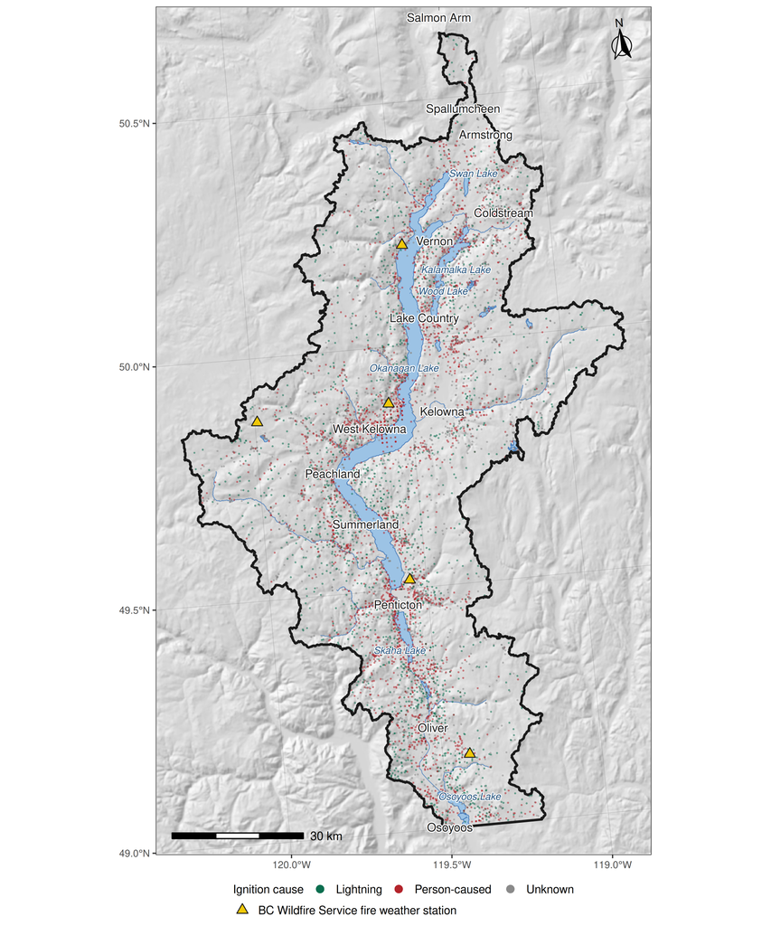

Figure 1. Study area, ignition record and weather record. Okanagan River watershed group, British Columbia Freshwater Atlas (GeoBC Branch, 2026d), 795,417 ha. Points were the 8,176 wildfire incidents recorded inside the basin between 1980 and 2025 in the BC Wildfire Service historical incident record (BC Wildfire Service, 2026c), coloured by reported cause. Incidents before 1991 preceded the study period. Of all incidents, 3,633 had no recorded cause and were drawn as unknown. Triangles were the 5 BC Wildfire Service fire weather stations inside the basin (BC Wildfire Service, 2026a), the entire weather record used. Lakes, streams and municipalities came from the Freshwater Atlas and the provincial administrative boundaries (GeoBC Branch, 2026b, 2026c; Governance and Structure Branch, 2026). Relief was a hillshade of a 99 m digital elevation model (Amazon Web Services, 2026). Coordinate reference system NAD83 / BC Albers, EPSG:3005; graticule labelled in WGS84 degrees. Representative fraction approximately 1:861,000 at a 132 mm panel width. Map lines delineate study areas and do not necessarily depict accepted national boundaries.

## 2.2 Fire Danger Systems

Fire danger was rated with both versions of the Canadian Forest Fire Weather Index System, FWI1987 and FWI2025 (Canadian Forest Service Fire Danger Group, 2025, p. 3). The System rated the weather against one standard fuel, “a generalized pine forest (similar to C-3)” (Canadian Forest Service Fire Danger Group, 2025, p. 3). C-3 was the mature jack pine fuel type of the Fire Behaviour Prediction System (Canadian Forest Service Fire Danger Group, 2025, p. 25). A danger trend here was therefore a trend in the weather rated against one fixed fuel.

FWI1987 was the version Van Wagner (1987a) specified. It had three fuel moisture codes, the Fine Fuel Moisture Code, the Duff Moisture Code and the Drought Code. Three fire behaviour indices were computed from them, the Initial Spread Index, the Buildup Index and the Fire Weather Index. Its inputs were air temperature, relative humidity, wind speed at ten metres in the open and rainfall over the previous 24 hours (Lawson and Armitage, 2008, pp. 1, 21). Each code was updated daily from its previous value with no reference period.

FWI2025 (Canadian Forest Service Fire Danger Group, 2025) kept those components and computed them hourly. The Fine Fuel Moisture Code followed the hourly method of Van Wagner (1977). The report modified it to give “a better approximation of the diurnal change in moisture associated with the actual day” (Canadian Forest Service Fire Danger Group, 2025, p. 17). Its drying time lag was halved “to better match field observations of litter moisture content variation throughout the day”, and it could dry overnight “under the right temperature and relative humidity conditions” (Canadian Forest Service Fire Danger Group, 2025, p. 18). The time lag was the time the litter took to lose most of the difference between its moisture and the value the air would bring it to. Canopy interception of the first 0.5 mm of rain became cumulative within a rain event. In place of the daily reset of FWI1987, “a six-hour time constant is introduced to account for canopy drying”, which the report called “a simple approximation of drying” (Canadian Forest Service Fire Danger Group, 2025, pp. 17–18). The 1.5 mm and 2.8 mm rain thresholds of the Duff Moisture Code and the Drought Code were applied the same way (Canadian Forest Service Fire Danger Group, 2025, pp. 20–21). The Initial Spread Index took the wind function of the Fire Behaviour Prediction System, which limited the effect of winds above 40 km h<sup>-1</sup> (Canadian Forest Service Fire Danger Group, 2025, p. 21; Forestry Canada Fire Danger Group, 1992, p. 32). The report’s reason was that “the original ISI formula in the FWI System can lead to excessively high values at extreme wind speeds” (Canadian Forest Service Fire Danger Group, 2025, p. 21). The report judged the change “primarily relevant for extreme fire conditions” and expected it to “not significantly impact fire agency classification thresholds” (Canadian Forest Service Fire Danger Group, 2025, p. 21). The Duff Moisture Code and the Drought Code dried only between sunrise and sunset, each hour “using a modification of the original drying rate functions” (Canadian Forest Service Fire Danger Group, 2025, p. 20). The report judged this hourly calculation “may be more granular than necessary” but said it “ensures consistency across all System components” (Canadian Forest Service Fire Danger Group, 2025, p. 20). Both codes kept their effective rainfall functions (Canadian Forest Service Fire Danger Group, 2025, p. 20). The report’s aim was “to modify the original methods such that they provided reasonable and consistent outputs in an hourly calculation” (Canadian Forest Service Fire Danger Group, 2025, p. 20).

FWI2025 added optional grassland codes, because grassland fuels “gain and lose moisture much more quickly than the litter layer” of a closed forest (Canadian Forest Service Fire Danger Group, 2025, pp. 13, 22). They were excluded, because the two versions were compared only where they overlapped.

## 2.3 Study Design

FWI1987 and FWI2025 differed at once in model version and in the time resolution of the weather, so a direct comparison could attribute a difference to neither. Three series were therefore computed from the one hourly weather record, so that each contrast between two of them changed one thing. The report set out three input pathways, A from hourly weather, B from daily maxima and minima and C from the 13:00 observation (Canadian Forest Service Fire Danger Group, 2025, p. 7). S1 was FWI1987 from the daily 13:00 local daylight time observation, the legacy configuration. That observation was the hour stamped 12:00 Pacific Standard Time in the record, and FWI2025 received every hour in standard time. S2 was FWI2025 from the same daily observation through pathway C. The report noted that the 13:00 observation “may be the only daily observation available for historical analysis” (Canadian Forest Service Fire Danger Group, 2025, p. 10). S3 was FWI2025 from the observed hourly weather through pathway A, which the report ranked best because it “provides the most accurate representation of diurnal weather patterns” (Canadian Forest Service Fire Danger Group, 2025, p. 7).

The contrast of S1 against S2 held the observation fixed and changed the version. The version change comprised the 2025 equations, the report’s reconstruction of hourly weather from the 13:00 observation and the daily value taken at 16:00. The contrast of S2 against S3 held the version fixed and replaced the reconstructed hourly weather with the observed. S1 against S3, called here the migration, was the change an agency met in moving from the old system to the new. All three ran on the same weather record, season window, startup values and gap filling, so every difference came from how a series treated that record.

Under pathway C, the 13:00 observation was converted to estimated daily maxima and minima with the report’s general constants (Canadian Forest Service Fire Danger Group, 2025, pp. 10–11). Their temperature and wind terms were estimated from central Canadian data (Canadian Forest Service Fire Danger Group, 2025, pp. 11–12). The report expected “these general methods for using the 13:00 weather observation should be adequate for most purposes” (Canadian Forest Service Fire Danger Group, 2025, p. 11). Those extremes were expanded to an hourly stream by the diurnal model of Beck and Trevitt (1989), as the report modified it (Canadian Forest Service Fire Danger Group, 2025, p. 9). The default offset and decay coefficients of its Table A-1 were used, a single set the report judged would “produce satisfactory results over the Canadian fire season” (Canadian Forest Service Fire Danger Group, 2025, p. 40). Rainfall was placed at the first hour after sunrise, “the way the 13:00 rainfall was treated in the FWI1987 System” (Canadian Forest Service Fire Danger Group, 2025, p. 12).

## 2.4 Weather Record

The weather record was the BC Wildfire Service Weather Data Mart (BC Wildfire Service, 2026b), a public directory of hourly station observations. Its catalogue layer (BC Wildfire Service, 2026a) listed 5 stations inside the basin, and each first appeared in the archive in the season it was installed (Table 2). The data mart gave hourly precipitation, temperature, relative humidity, wind speed and direction, and once a day the six FWI1987 codes the service computed operationally.

Table 2. The weather record. Season counts ran from 1988 to 2025. A season was kept when coverage reached 95 per cent and no single gap exceeded 24 hours, and was otherwise dropped. A station was not reporting in a season with no record. Coverage was the share of the 1 April to 30 September hours in which temperature, humidity and wind were all observed, before any gap filling.

| Station | Station number | Elevation (m) | Installed | First season kept | Last season kept | Seasons kept | Seasons dropped | Not reporting | Median coverage (%) |
| --- | --- | --- | --- | --- | --- | --- | --- | --- | --- |
| Penticton RS | 328 | 492 | 1988 | 1991 | 2025 | 27 | 11 | 0 | 100.0 |
| McCuddy | 334 | 1,023 | 1989 | 1994 | 2025 | 26 | 11 | 1 | 100.0 |
| Fintry | 298 | 526 | 1990 | 1996 | 2025 | 25 | 7 | 6 | 100.0 |
| Brenda Mines | 283 | 1,463 | 1989 | 1998 | 2025 | 20 | 17 | 1 | 99.9 |
| West Kelowna | 1277 | 650 | 2016 | 2017 | 2024 | 6 | 3 | 29 | 99.8 |

The record kept under the coverage rule was 104 station-seasons across 5 stations over 1991 to 2025, 31 distinct seasons.

```r
# The three facts the sentence below states, computed from the coverage table
# the station table reports: the seasons dropped, the share of them before
# 2000, and the first season each station reported at all.
n_dropped <- sum(cover$status == "dropped, coverage")
n_dropped_pre2000 <- sum(cover$status == "dropped, coverage" & cover$year < 2000)
first_report <- tapply(cover$year[cover$status != "station not reporting"],
                       cover$station_name[cover$status != "station not reporting"], min)
late_station <- names(first_report)[which.max(first_report)]
# The share of kept hours in which temperature, humidity or wind was filled,
# over the record and before 2000, and the most hours filled in one season.
fill_share <- function(rows) 100 * sum(rows$filled_hours) / sum(rows$expected_hours)
pct_filled <- fill_share(kept)
pct_filled_pre2000 <- fill_share(kept[kept$year < 2000, ])
max_filled <- max(kept$filled_hours)
```

Of the 49 seasons dropped for coverage, 33 fell before 2000, and the West Kelowna station reported only from 2016.

### 2.4.1 Season Window

The window was fixed by calendar in every season, 1 May to 30 September, 153 days, with the calculation started on 1 April. It replaced the Canadian start rules, which began the calculation three days after the snow cover disappeared (Canadian Forest Service Fire Danger Group, 2025, p. 48). Where snow cover was not significant, the calculation began “on the third successive day that noon temperatures of 12 °C or higher have been recorded” (Lawson and Armitage, 2008, p. 14). The 2025 report called both rules “simply surrogates for the harder to observe state where the organic layer in the forest has thawed” (Canadian Forest Service Fire Danger Group, 2025, p. 48). These stations, like the fire weather stations of Hanes et al. (2020), did not report through the winter. The calendar start could precede thaw at the two highest stations, Brenda Mines and McCuddy. At those two stations, the Duff Moisture Code and the Drought Code dried from 1 April whether or not the organic layer had thawed.

### 2.4.2 Gaps and Startup

Runs of missing temperature, humidity or wind up to 24 hours were filled by linear interpolation and missing precipitation was set to zero. Hours with a missing temperature, humidity or wind value were 0.13 per cent of the kept hours, 0.28 per cent before 2000, and no kept season had more than 56. A station-season was kept only where at least 95 per cent of the 1 April to 30 September hours were observed and no single gap exceeded 24 hours. Filling gaps with no rain biased danger upward, more in the early seasons where coverage was worse, so it worked against an increasing trend. The filling was the same in all three series and was unlikely to move a contrast. The two versions took rain differently, by event in FWI2025 and by day in FWI1987, so a filled rain gap need not have acted equally on each.

Each station-season started from a Fine Fuel Moisture Code of 85, a Duff Moisture Code of 6 and a Drought Code of 15, the startup values of both versions (Canadian Forest Service Fire Danger Group, 2025, p. 49; Lawson and Armitage, 2008, p. 14). The 2025 report described them as “estimates of moisture content in these fuel layers after three days of drying from a fully saturated starting point” (Canadian Forest Service Fire Danger Group, 2025, p. 49). The Drought Code was not overwintered, that is carried over the winter into the next spring, because the stations reported no winter weather. Operationally, “the western provinces regularly overwinter the DC” (Hanes et al., 2020, p. 2). The Drought Code therefore still reflected its startup value in early May in every season, as reported in Supplementary Material S1. The restart was shared, but the two versions dried the code at different rates from 1 April, so the three series had already separated by 1 May.

## 2.5 Index Computation

FWI2025 was computed with the reference implementation of the Canadian Forest Service Fire Danger Group (2026), run unmodified. Over the hourly Petawawa Research Forest test record, the hourly calculation reproduced the distributed standard output exactly in every one of its hours. FWI1987 was implemented for this study in Python and checked in two ways reported in Supplementary Material S1. The first check was against the `cffdrs` package, version 1.9.2 (Wang et al., 2017, 2025a). The second was against the codes that BC Wildfire Service computed operationally at these stations.

The coefficient that converted the Fine Fuel Moisture Code to a moisture content was printed as 147.2 by Van Wagner (1987a, p. 4) and in the Fortran listing of Van Wagner and Pickett (1985, pp. 5, 14). The implementation took 147.2772, which was $59.5 \times 250 / 101$ and gave a moisture content of exactly 250 per cent at a code of zero. The `cffdrs` package and the reference implementation of FWI2025 both used that value, so a rounded constant would have added a difference of its own to the version comparison.

## 2.6 Seasonal Metrics

```r
# How often the seasonal peak Drought Code fell on 30 September, the window's
# last day, read by the Methods sentence below. Ties take the latest day.
# Added 2026-11-18.
dc_day <- read.csv(file.path(derived, "fwi-series-daily.csv"))
dc_last <- sapply(c(s1 = "s1", s2 = "s2", s3 = "s3"), function(s) {
  d <- dc_day[!is.na(dc_day[[paste0(s, "_dc")]]), ]
  peak <- sapply(split(d, list(d$station_code, d$year), drop = TRUE), function(g) {
    dc <- g[[paste0(s, "_dc")]]
    max(g$date[dc == max(dc)]) == sprintf("%d-09-30", g$year[1])
  })
  c(n = length(peak), last = sum(peak))
})
stopifnot(length(unique(dc_last["n", ])) == 1)
```

For each station-season and series, twelve seasonal metrics were computed over the window. Six were levels, mean Fire Weather Index, seasonal severity rating, peak Buildup Index, mean Initial Spread Index, mean Duff Moisture Code and peak Drought Code. The seasonal severity rating was the sum of the Daily Severity Rating over the season. The other six were counts of days above the thresholds described next. The peak Drought Code fell on 30 September, the last day of the window, in 42 of the 104 station-seasons under S1, 41 under S2 and 37 under S3. In those seasons, the code was highest when the window closed, so the metric could understate the code’s annual peak. The FWI2025 series were summarised to a daily value at 16:00 local standard time (LST), with the daily maximum kept as a sensitivity only, reported in Supplementary Material S2. The hour was that of Van Wagner (1987a, p. 2), who wrote that the Fire Weather Index, though computed from noon readings, “really represents fire danger at its midafternoon peak, generally specified as 1600 hours”. The 2008 weather guide gave that hour in standard time, writing that the daily code “assumes that daily peak conditions occur at 1600 h LST” (Lawson and Armitage, 2008, p. 11). The 2025 report held that FWI1987 “lacks a precise definition for the time to which its outputs are correlated to the peak burning conditions of the day”, although “training material often suggests 16:00 or 17:00 as general approximations” (Canadian Forest Service Fire Danger Group, 2025, p. 27). It let users take the daily value “at a specific time the user selects as ‘peak burn,’ or from the actual time at which peak fire behaviour would be expected” (Canadian Forest Service Fire Danger Group, 2025, p. 8). Its own daily summary defined the peak burn as “the hour corresponding to a maximum, smoothed ISI during the day” (Canadian Forest Service Fire Danger Group, 2025, p. 27).

Absolute thresholds applied unchanged to all three series. A Fine Fuel Moisture Code of 91 was taken from section 4.1 of Canadian Forest Service Fire Danger Group (2025) so that days above it tested that report’s comparability sentence. It was also the threshold above which the Canadian Wildland Fire Information System classed the code as extreme (Field et al., 2015, p. 1409). A Fire Weather Index of 30 was that system’s extreme threshold for the index (Field et al., 2015, p. 1409). The same source warned that such thresholds “will be different in other regions” (Field et al., 2015, p. 1409). A Fire Weather Index above 19 was the fire spread day threshold recommended “Based on our results for Ontario” (Podur and Wotton, 2011, p. 506). Days above it counted weather conducive to spread, not observed spread. Across Canada, Wang et al. (2020) counted a realized spread day where a fire grew more than 240 m in a day (Wang et al., 2020, p. 3). That was “a nominal rate of spread of at least 1 m min<sup>-1</sup>” over a four hour burning period (Wang et al., 2020, p. 3).

Relative thresholds followed Zhang et al. (2011). They were the 90th and 95th percentiles of each series’ own Fire Weather Index distribution, and the 95th percentile of its Initial Spread Index distribution. The last was the fire weather day threshold of Richardson et al. (2022) applied to the spread index. Each was set at each station over the 1991 to 2020 reference period. Inside that period, the mean count above the 90th percentile was near ten per cent of days in every series by construction. Only the trend of a relative count therefore said anything about the version.

Counts above the relative thresholds in base-period seasons were estimated by the bootstrap of Zhang et al. (2005), adapted from a daily to a seasonal threshold. For each base season, the threshold was re-estimated with that season removed and each other base season duplicated in turn in its place. The count was the mean over those replacements. The last 5 seasons used the threshold from the whole base period.

Two further quantities were computed only under FWI2025, the hour of peak burning conditions and the number of hours a day the burning window stayed open. Both came from the daily summaries the report offered “as examples and starting points” (Canadian Forest Service Fire Danger Group, 2025, p. 27). The hour of peak burning conditions was the hour of the highest smoothed Initial Spread Index. On days whose highest Fine Fuel Moisture Code stayed below 85, the hour of peak burning conditions was set to 17:00 local standard time. The window opened when the smoothed Initial Spread Index first reached a threshold “equal to or greater than five, which corresponds to spreading surface fires” (Canadian Forest Service Fire Danger Group, 2025, p. 28). The window closed when the index last fell below that threshold. The report judged that the length of the window “might be useful for understanding the impacts of non-standard conditions” (Canadian Forest Service Fire Danger Group, 2025, p. 28).

## 2.7 Fire Activity

Ignitions came from the BC Wildfire Service historical incident record (BC Wildfire Service, 2026c), clipped to the basin, 8,176 incidents over the 1980 to 2025 seasons. Only 6,304 of them, 77.1 per cent, had an ignition date and could enter a daily series. The share with a recorded cause also changed over the record.

```r
# Both completeness measures by decade, read by the sentences that follow.
completeness$decade <- paste0(completeness$year %/% 10 * 10, "s")
cd <- do.call(rbind, lapply(split(completeness, completeness$decade), function(d) {
  data.frame(
    Decade = d$decade[1],
    Incidents = sum(d$n_incidents),
    Dated = sum(d$n_dated),
    `Dated %` = round(100 * sum(d$n_dated) / sum(d$n_incidents), 1),
    Attributed = sum(d$n_caused),
    `Attributed %` = round(100 * sum(d$n_caused) / sum(d$n_incidents), 1),
    check.names = FALSE)
}))
# The share of incidents recorded under 0.1 ha by decade, the measure of how the
# recording of small fires changed, read from the same incident layer.
# BC Wildfire Fire Incident Locations, Historical, BC Data Catalogue,
# https://catalogue.data.gov.bc.ca/dataset/bc-wildfire-fire-incident-locations-historical,
# clipped to the basin into the ignitions layer of study-area.gpkg.
ign_sz <- sf::st_drop_geometry(sf::st_read(
  file.path(inputs, "spatial", "study-area.gpkg"), "ignitions", quiet = TRUE))
ign_sz$size_ha <- suppressWarnings(as.numeric(ign_sz$CURRENT_SIZE))
ign_sz$decade <- paste0(as.integer(ign_sz$FIRE_YEAR) %/% 10 * 10, "s")
small <- do.call(rbind, lapply(split(ign_sz, ign_sz$decade), function(d) {
  sized <- d[!is.na(d$size_ha), ]
  data.frame(decade = d$decade[1], n_sized = nrow(sized),
             pct_small = round(100 * mean(sized$size_ha < 0.1), 1))
}))
stopifnot(sum(small$n_sized) == sum(completeness$n_sized))
```

By decade, the share of incidents with an ignition date was 100 per cent in the 1980s and 1990s and lowest at 45.6 per cent in the 2020s. The share with a recorded cause was highest at 95.2 per cent in the 1980s and lowest at 32.4 per cent in the 2000s.

```r
# Season-by-cause counts and the two completeness measures, with the pooled
# shares before 2000 and from 2000 onward computed here for the caption.
ibs <- read.csv(file.path(derived, "ignitions-by-season.csv"),
                stringsAsFactors = FALSE)
cause_tab <- xtabs(n ~ fire_cause + fire_year, ibs)
cause_tab <- cause_tab[c("Lightning", "Person", "Unknown"), , drop = FALSE]
share <- function(rows, col) 100 * sum(completeness[[col]][rows]) / sum(completeness$n_incidents[rows])
ign_cap <- sprintf(paste(
  "Ignitions by season and the completeness of their records. Upper panel,",
  "incidents per season by reported cause, %s in all. Lower panel, the share",
  "of incidents with an ignition date and the share with a recorded",
  "cause. The two shares were %.0f and %.0f per cent before 2000 and %.0f and %.0f per",
  "cent from 2000 onward."),
  n_fmt(n_total_incidents),
  share(completeness$year < 2000, "n_dated"), share(completeness$year < 2000, "n_caused"),
  share(completeness$year >= 2000, "n_dated"), share(completeness$year >= 2000, "n_caused"))
```

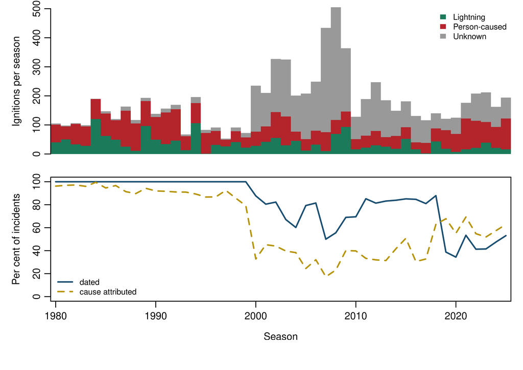

Figure 2. Ignitions by season and the completeness of their records. Upper panel, incidents per season by reported cause, 8,176 in all. Lower panel, the share of incidents with an ignition date and the share with a recorded cause. The two shares were 100 and 92 per cent before 2000 and 67 and 40 per cent from 2000 onward.

```r
# Two panels on one season axis. The bars are stacked by cause in the palette
# the study-area map uses; the lines are the two completeness measures from the
# same completeness table the decade table summarises.
cause_cols <- c(Lightning = "#1B7A5A", Person = "#B3242B", Unknown = "grey60")
yrs2 <- as.integer(colnames(cause_tab))
op <- par(mfrow = c(2, 1), mar = c(1.2, 4.2, 0.6, 1), oma = c(2.5, 0, 0, 0),
          mgp = c(2.4, 0.7, 0), cex = 0.75)
barplot(cause_tab, col = cause_cols[rownames(cause_tab)], border = NA,
        names.arg = rep("", ncol(cause_tab)), ylab = "Ignitions per season",
        space = 0, xaxs = "i")
legend("topright", legend = sub("^Person$", "Person-caused", rownames(cause_tab)),
       fill = cause_cols[rownames(cause_tab)],
       border = NA, bty = "n", cex = 0.8)
par(mar = c(3.2, 4.2, 0.6, 1))
plot(completeness$year, completeness$pct_dated, type = "l", lwd = 1.8,
     col = "#1B4F72", ylim = c(0, 100), xlab = "Season",
     ylab = "Per cent of incidents", xaxs = "i", xlim = range(yrs2) + c(-0.5, 0.5))
lines(completeness$year, completeness$pct_caused, lwd = 1.8, col = "#B7950B", lty = 2)
legend("bottomleft", legend = c("dated", "cause attributed"),
       col = c("#1B4F72", "#B7950B"), lwd = 1.8, lty = c(1, 2), bty = "n", cex = 0.8)
par(op)
```

Figure 2 showed the records season by season, and the fall of both completeness measures after 2000 made the cause split unreadable as an ignition trend. Three response series were therefore modelled, lightning, person-caused and all causes together, because the all-cause series was unaffected by cause coding and so decided any disagreement. Recording of small fires also changed over the record. Among incidents with a recorded size, the share under 0.1 ha was 2.5 per cent in the 1980s and 78.6 per cent in the 2000s. The all-cause danger coefficient was therefore estimated at three minimum fire sizes, no limit, one hectare and four hectares.

## 2.8 Statistical Analysis

### 2.8.1 Trends

Trends were estimated with the Theil-Sen slope (Sen, 1968) and tested with the Mann-Kendall test (Mann, 1945) at each station, over its kept seasons from 1991 to 2025. Both were computed on the actual season years, so that a gap was kept as a gap. A station entered the trend tests only with at least 15 kept seasons. That rule left out West Kelowna, which had 6 kept seasons.

Significance was assessed under the variance correction of Hamed and Rao (1998) for serial correlation, without which the test rejected too often on trendless series (Bayazit and Önöz, 2007; Yue et al., 2002). The correction multiplied the variance of the test statistic by the ratio of the nominal to the effective sample size. The effective sample size was the number of independent seasons the correlated record was worth. The ratio could exceed one, which raised the variance, or fall below one, which lowered it. The correction counted lags in observations rather than years, so across a gap left by the coverage rule it was understated. A q value was the p value after correction for multiple testing.

Within each station’s twelve metrics in each series, p values were corrected by the false discovery rate procedure of Benjamini and Hochberg (1995). Benjamini and Yekutieli (2001) proved that it still controlled that rate under positive regression dependency, assumed here. The families, one per station and series, shared one basin’s weather, so tests in different families were positively dependent as well as tests within one. The family was set at the station because each trend was a question about one station’s record. The confidence interval on a slope was the percentile interval over 2,000 moving-block bootstrap resamples of seasons.

### 2.8.2 Slope Differences

The difference between the Theil-Sen slopes of two series was tested by a moving-block bootstrap, because the three series were mutually dependent and serially correlated (Künsch, 1989; Politis and Romano, 1994). The difference was tested directly, not judged from the overlap of two slope intervals, because pairing removed “variability that is common to both time series” (Santer et al., 2000, p. 7348). Each of the 4,000 replicates drew blocks of consecutive seasons with replacement and recomputed both slopes on the same resampled seasons, keeping the pairing between series (Wilks, 1997). Each resampled season kept its own year, here and in the slope interval. The difference test drew twice the replicates of the slope interval, because its p value was read from the tail of the resampled distribution and then corrected for false discovery. Blocks were 3 seasons long for station records of 20 to 27 seasons, the cube root of the record length rounded up (Künsch, 1989). They were drawn in order of occurrence, so that a gap fell inside a block. The interval on the difference was the percentile interval. The two-sided p value followed the first guideline of Hall and Wilson (1991) and was corrected for false discovery rate within the twelve metrics of one contrast at one station. The resampled differences were centred on the observed difference, and p was the share of them at least as far from it as the observed difference was from zero.

### 2.8.3 Ignition Models

Daily ignition counts were modelled by negative binomial regression with a log link (Lawless, 1987), in the daily form of Plucinski et al. (2014). The linear predictor contained the series’ Fire Weather Index averaged over the 3 core stations that day. It also contained two annual harmonics in day of year after Martell et al. (1989), and season as a factor. The core stations were those present in at least 80 per cent of the kept seasons, and the number of them reporting that day was a further term. The season factor gave each season its own intercept, so the danger coefficient was identified only from day-to-day variation inside a season. Within a season, reporting completeness and cause coding did not change. The lightning model had no strike term, because no public record of strikes covered the seasons. The Canadian Lightning Detection Network “was established in 1998 and consists of over 80 lightning sensors distributed across Canada” (Environment and Climate Change Canada, 2016), 7 years after this record began. Environment and Climate Change Canada “does not have a website for historical lightning”, and historical data came “by contacting your weather service” (Environment and Climate Change Canada, 2018). Stationarity was tested by an interaction between the danger term and season number. This was the count form of the period by intensity interactions that Granville et al. (2022) fitted to industrial fires in Ontario from 1976 to 2019. The season effect followed Magnussen and Taylor (2012), whose year-specific British Columbia models showed coefficients varying between years “typically in excess of 100%” (Magnussen and Taylor, 2012, p. 346).

Predictive skill was compared by the blocked cross-validation that Roberts et al. (2017) recommended, in the leave-one-year-out form of Magnussen and Taylor (2012). Each season was left out in turn and scored by its log likelihood under the model refitted without it, the strictly proper logarithmic score of Gneiting and Raftery (2007). The scores were comparable because the three series were scored on the same days. The three were close to transformations of one another, so a small difference in held-out likelihood was not read as a difference in predictive power (Eastaugh et al., 2012).

### 2.8.4 Detectable Trend

Following Weatherhead et al. (1998), the minimum detectable trend was the slope at which a two-sided test at alpha 0.05 reached 90 per cent power. The detectable trend was computed for each metric at each station, over that station’s 20 to 27 kept seasons. The power was computed from the residual spread of that metric about its own Theil-Sen line. The slope was divided by 0.93, the efficiency taken for the Theil-Sen estimator against least squares under normal errors. It was then inflated for serial correlation by the factor Weatherhead et al. (1998) derived for first-order autoregressive noise, the square root of (1 + phi) / (1 − phi). Phi was the lag-one autocorrelation of the residuals in season order, bounded between 0 and 0.9.

# 3 Results

```r
series_daily <- read.csv(file.path(derived, "fwi-series-daily.csv"),
                         stringsAsFactors = FALSE)
series_daily$date <- as.Date(series_daily$date)
metrics <- read.csv(file.path(derived, "seasonal-metrics.csv"),
                    stringsAsFactors = FALSE)
thresh_pct <- read.csv(file.path(derived, "threshold-percentiles.csv"),
                       stringsAsFactors = FALSE)
basin <- read.csv(file.path(derived, "basin-daily.csv"), stringsAsFactors = FALSE)
basin$date <- as.Date(basin$date)

# Relative-threshold counts are replaced by the in-base bootstrap estimates of
# Zhang et al. (2005), computed from the same daily series and the same
# 1991 to 2020 base period. Out-of-base seasons are unchanged by construction;
# the check below stops the render if any is not.
corrected <- do.call(rbind, lapply(names(SERIES), function(s)
  inbase_corrected_counts(series_daily, s, probs = c(90, 95),
                          reference = c(1991, 2020))))
for (pp in c(90, 95)) {
  col <- paste0("n_fwi_p", pp)
  cc <- corrected[corrected$prob == pp, c("station_name", "series", "year", "count")]
  key_m <- paste(metrics$station_name, metrics$series, metrics$year)
  key_c <- paste(cc$station_name, cc$series, cc$year)
  new <- cc$count[match(key_m, key_c)]
  out_base <- metrics$year > 2020 & is.finite(metrics[[col]])
  if (any(abs(new[out_base] - metrics[[col]][out_base]) > 1e-9))
    stop("in-base correction changed an out-of-base count for ", col)
  metrics[[paste0(col, "_uncorrected")]] <- metrics[[col]]
  metrics[[col]] <- new
}
corrected_isi <- do.call(rbind, lapply(names(SERIES), function(s)
  inbase_corrected_counts(series_daily, s, probs = 95,
                          reference = c(1991, 2020), component = "isi")))
cc <- corrected_isi[, c("station_name", "series", "year", "count")]
key_m <- paste(metrics$station_name, metrics$series, metrics$year)
key_c <- paste(cc$station_name, cc$series, cc$year)
new <- cc$count[match(key_m, key_c)]
out_base <- metrics$year > 2020 & is.finite(metrics$n_isi_p95)
if (any(abs(new[out_base] - metrics$n_isi_p95[out_base]) > 1e-9))
  stop("in-base correction changed an out-of-base count for n_isi_p95")
metrics$n_isi_p95_uncorrected <- metrics$n_isi_p95
metrics$n_isi_p95 <- new
```

Results followed the order of the design. Where each absolute threshold fell in each series came first, then the diurnal mechanism that separated the series, then the three questions in turn.

## 3.1 Threshold Positions

```r
tp <- do.call(rbind, lapply(
  split(thresh_pct, list(thresh_pct$series, thresh_pct$component,
                         thresh_pct$threshold), drop = TRUE),
  function(d) data.frame(
    Series = unname(SERIES[d$series[1]]),
    Component = toupper(d$component[1]),
    Threshold = d$threshold[1],
    `Percentile of threshold` = round(mean(d$percentile_of_threshold, na.rm = TRUE), 1),
    `Days per season above` = NA_real_,
    `Reference median` = round(mean(d$reference_median, na.rm = TRUE), 1),
    check.names = FALSE)))
# Days per season above each absolute threshold, averaged over station-seasons.
days_above <- function(series, component, thr) {
  col <- switch(paste(component, thr),
                "ffmc 91" = "n_ffmc_gt91",
                "fwi 19" = "n_fwi_gt19",
                "fwi 30" = "n_fwi_gt30")
  mean(metrics[[col]][metrics$series == series], na.rm = TRUE)
}
key <- do.call(rbind, strsplit(rownames(tp), "\\."))
tp$`Days per season above` <- round(mapply(days_above, key[, 1], key[, 2],
                                           as.numeric(key[, 3])), 1)
tp <- tp[order(tp$Component, tp$Threshold, tp$Series), ]
rownames(tp) <- NULL
fmt_tbl(tp)
```

Table 3. Where each absolute threshold fell in each series’ own 1991 to 2020 reference distribution, averaged over stations. A threshold at the same percentile in every series would have meant the three series were interchangeable for counting extremes. The reference median was the median of that component over the same distribution. Days per season above were the mean over every kept station-season from 1991 to 2025.

| Series | Component | Threshold | Percentile of threshold | Days per season above | Reference median |
| --- | --- | --- | --- | --- | --- |
| S1: FWI1987, 13:00 observation | FFMC | 91 | 65.1 | 57.2 | 89.3 |
| S2: FWI2025, 13:00 observation | FFMC | 91 | 66.2 | 55.4 | 89.5 |
| S3: FWI2025, hourly observation | FFMC | 91 | 62.5 | 61.9 | 89.8 |
| S1: FWI1987, 13:00 observation | FWI | 19 | 52.5 | 78.1 | 19.3 |
| S2: FWI2025, 13:00 observation | FWI | 19 | 47.6 | 85.4 | 21.4 |
| S3: FWI2025, hourly observation | FWI | 19 | 52.6 | 77.8 | 19.5 |
| S1: FWI1987, 13:00 observation | FWI | 30 | 74.8 | 43.0 | 19.3 |
| S2: FWI2025, 13:00 observation | FWI | 30 | 72.4 | 46.7 | 21.4 |
| S3: FWI2025, hourly observation | FWI | 30 | 75.2 | 42.9 | 19.5 |

```r
ffmc91 <- subset(tp, Component == "FFMC" & Threshold == 91)
fwi19 <- subset(tp, Component == "FWI" & Threshold == 19)
p_s1 <- ffmc91$`Percentile of threshold`[grepl("S1", ffmc91$Series)]
p_s2 <- ffmc91$`Percentile of threshold`[grepl("S2", ffmc91$Series)]
p_s3 <- ffmc91$`Percentile of threshold`[grepl("S3", ffmc91$Series)]
d_s1 <- ffmc91$`Days per season above`[grepl("S1", ffmc91$Series)]
d_s2 <- ffmc91$`Days per season above`[grepl("S2", ffmc91$Series)]
d_s3 <- ffmc91$`Days per season above`[grepl("S3", ffmc91$Series)]
# Spread of the three reference medians, the level comparison the sentence states.
med_spread <- diff(range(ffmc91$`Reference median`))
```

```r
# The comparability claim is about where a value sits, so the reading is stated
# in the two units that matter and neither is rounded away: the percentile spread
# across series, and the difference in days per season an agency would count.
pct_spread <- max(abs(p_s3 - p_s1), abs(p_s2 - p_s1))
day_gap <- d_s3 - d_s1
day_gap_pct <- 100 * day_gap / d_s1
# The same migration gap at the two Fire Weather Index thresholds.
fwi30 <- subset(tp, Component == "FWI" & Threshold == 30)
gap_at <- function(d) d$`Days per season above`[grepl("S3", d$Series)] -
  d$`Days per season above`[grepl("S1", d$Series)]
gap19 <- gap_at(fwi19)
gap30 <- gap_at(fwi30)
```

The 2025 report stated that “an FFMC of 91 in FWI1987 should correspond to an FFMC of approximately 91 in FWI2025” (Canadian Forest Service Fire Danger Group, 2025, p. 17). Across the three series, the statement held for the value and not for the count of days above it (Table 3). Over the reference period of 1991 to 2020, the three reference medians of the Fine Fuel Moisture Code lay within 0.5 units of each other. A Fine Fuel Moisture Code of 91 fell at percentile 65.1 of the S1 distribution, 66.2 of S2 and 62.5 of S3. The percentile moved by up to 2.6 points from its S1 position. Across every kept station-season, the same threshold selected 4.7 more days per season under S3 than under S1, a difference of 8 per cent. Under the migration, the count above a Fire Weather Index of 19 moved by -0.3 days per season and above 30 by -0.1.

```r
# The level shift each change produces, per season, on the two absolute-threshold
# counts and on the three level metrics whose equations the 2025 revision
# rewrote. The sign is computed, not asserted, because the two changes do not
# necessarily push the same way. Moved here from the Discussion on 2026-11-05,
# since a shift between series is a result.
lvl <- function(metric, a, b) {
  mean(metrics[[metric]][metrics$series == b], na.rm = TRUE) -
    mean(metrics[[metric]][metrics$series == a], na.rm = TRUE)
}
shift_cols <- c("n_ffmc_gt91", "n_fwi_gt19", "mean_isi", "mean_dmc", "peak_dc")
shift <- data.frame(
  metric = c("Days FFMC > 91", "Days FWI > 19", "Mean ISI", "Mean DMC", "Peak DC"),
  unit = c("days", "days", "ISI units", "DMC units", "DC units"),
  version = sapply(shift_cols, lvl, a = "s1", b = "s2"),
  input = sapply(shift_cols, lvl, a = "s2", b = "s3"),
  migration = sapply(shift_cols, lvl, a = "s1", b = "s3"),
  row.names = NULL
)
# The migration shift as a share of the FWI1987 level of the same metric.
base_s1 <- sapply(shift_cols, function(m) mean(metrics[[m]][metrics$series == "s1"], na.rm = TRUE))
shift$migration_pct <- 100 * shift$migration / base_s1
write.csv(shift, file.path(outputs, "level-shifts.csv"), row.names = FALSE)
# Direction words for the prose, computed so that a sentence cannot assert a
# sign the numbers do not show.
up_down <- function(x, up = "raised", down = "lowered") if (x >= 0) up else down
```

Across the kept station-seasons, the version change at fixed 13:00 input moved the count of days above a Fine Fuel Moisture Code of 91 by -1.8 days per season. The input resolution change moved it by +6.5. On the count above a Fire Weather Index of 19, the two changes moved it by +7.3 and -7.6 days. The version change raised the mean Duff Moisture Code by 5.8 units and raised the peak Drought Code by 59.6 units. The hourly input then moved them by -9.2 and -1.5 units. The mean Initial Spread Index moved by +0.80 under the version change and by -0.10 under the input change. Over both changes, the migration’s net change was +4.7 days at the first threshold and -0.3 at the second. The migration left the Duff Moisture Code 4.5 per cent lower and the Drought Code 7.9 per cent higher than under FWI1987.

## 3.2 Mechanism

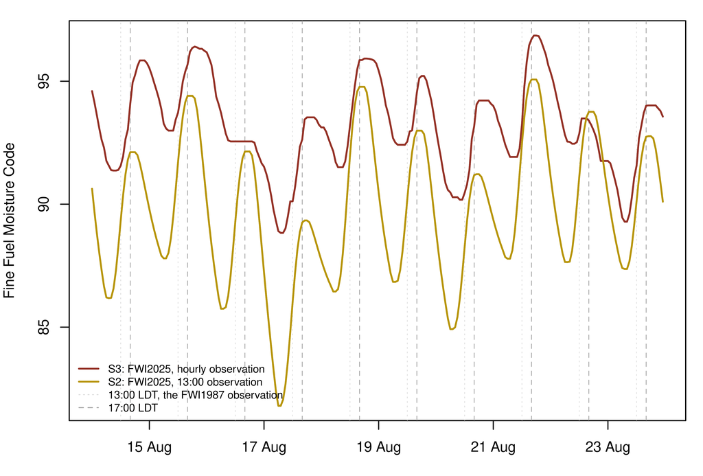

Figure 3. Ten days of the hourly Fine Fuel Moisture Code at Penticton RS in August 2003, under FWI2025. One line was driven by the observed hourly weather and the other by the 13:00 observation alone. Both lines were FWI2025 on the same days, and they differed only in the weather input. The vertical lines marked 13:00 and 17:00 local daylight time (LDT). FWI1987 took its observation at 13:00 LDT, and 17:00 LDT was 16:00 local standard time, the hour of the daily value.

```r
# One colour per series, shared by every figure that follows.
cols <- c(s1 = "#1B4F72", s2 = "#B7950B", s3 = "#943126")
ex <- read.csv(file.path(derived, "example-season-hourly.csv"),
               stringsAsFactors = FALSE)
ex$t <- as.POSIXct(sprintf("%04d-%02d-%02d %02d:00:00", ex$yr, ex$mon, ex$day, ex$hr),
                   tz = "UTC")
win <- ex[ex$mon == 8 & ex$day >= 14 & ex$day <= 23, ]

op <- par(mar = c(3.2, 4, 1.2, 1), cex = 0.8)
plot(win$t, win$s3_ffmc, type = "l", col = cols["s3"], lwd = 1.6,
     ylim = range(c(win$s3_ffmc, win$s2_ffmc), na.rm = TRUE),
     xlab = "", ylab = "Fine Fuel Moisture Code", xaxt = "n")
lines(win$t, win$s2_ffmc, col = cols["s2"], lwd = 1.6)
axis.POSIXct(1, win$t, format = "%d %b")
# The hour markers are drawn thin and pale on purpose: they locate the two
# sampling hours without competing with the curves, which are the subject.
abline(v = win$t[win$hr == 12], col = "grey86", lty = 3, lwd = 0.6)
abline(v = win$t[win$hr == 16], col = "grey62", lty = 2, lwd = 0.6)
lines(win$t, win$s3_ffmc, col = cols["s3"], lwd = 1.6)
lines(win$t, win$s2_ffmc, col = cols["s2"], lwd = 1.6)
legend("bottomleft", bty = "n", cex = 0.75,
       legend = c(unname(SERIES[c("s3", "s2")]),
                  "13:00 LDT, the FWI1987 observation", "17:00 LDT"),
       col = c(cols["s3"], cols["s2"], "grey86", "grey62"),
       lwd = c(1.6, 1.6, 0.8, 0.8), lty = c(1, 1, 3, 2))
par(op)
```

```r
# The two quantities FWI2025 reports and FWI1987 cannot, the hour of peak burning
# conditions and the hours per day the burning window stays open, as the
# specification's own daily summary computes them, averaged over kept
# station-seasons. Read by the sentences below and by the Conclusions.
cap <- metrics[metrics$series %in% c("s2", "s3") &
                 !is.na(metrics$mean_peak_hr), ]
if (nrow(cap)) {
  ct <- do.call(rbind, lapply(split(cap, cap$series), function(d) data.frame(
    Series = unname(SERIES[d$series[1]]),
    `Mean peak hour (LST)` = round(mean(d$mean_peak_hr, na.rm = TRUE), 2),
    `Mean burning window (h)` = round(mean(d$mean_duration, na.rm = TRUE), 2),
    `Days per season with window >= 6 h` = round(mean(d$n_duration_ge6, na.rm = TRUE), 1),
    # Spread across station-seasons, so that each mean carries its dispersion.
    `SD peak hour (h)` = round(sd(d$mean_peak_hr, na.rm = TRUE), 2),
    `SD burning window (h)` = round(sd(d$mean_duration, na.rm = TRUE), 2),
    `SD days with window >= 6 h` = round(sd(d$n_duration_ge6, na.rm = TRUE), 1),
    check.names = FALSE)))
  rownames(ct) <- NULL
} else {
  stop("seasonal-metrics.csv carries no daily summary columns; re-run build_seasonal_metrics.py")
}
```

```r
# The two readings the figure supports, computed from the same window it draws.
night <- win$hr %in% c(2, 3, 4, 5)
day <- win$hr %in% c(14, 15, 16, 17)
night_gap <- mean(win$s3_ffmc[night] - win$s2_ffmc[night], na.rm = TRUE)
day_gap <- mean(win$s3_ffmc[day] - win$s2_ffmc[day], na.rm = TRUE)
range_s3 <- mean(tapply(win$s3_ffmc, win$day, function(v) diff(range(v))))
range_s2 <- mean(tapply(win$s2_ffmc, win$day, function(v) diff(range(v))))
# The capability summary by series, and a decimal hour written as a clock time.
cap_s2 <- ct[grepl("S2", ct$Series), ]
cap_s3 <- ct[grepl("S3", ct$Series), ]
clock <- function(h) sprintf("%02d:%02d", floor(h), round((h - floor(h)) * 60))
```

At Penticton RS over ten days in August 2003, the hourly Fine Fuel Moisture Code under S2 differed in shape from the code under S3 (Figure 3). S2 was reconstructed from the 13:00 observation and S3 ran on the observed hourly weather. The reconstructed code moved 6.6 units between its daily minimum and maximum against 4.2 for the observed series. The two ran 1.5 units apart in mid-afternoon and 5.4 units apart before dawn, so the reconstruction estimated the nights wetter than observed. Over kept station-seasons, the mean burning window was 7.3 hours under S2 and 11.0 hours under S3, with standard deviations of 2.0 and 2.6 hours. Days per season with a window of at least six hours numbered 87.2 under S2 and 96.0 under S3, with standard deviations of 18.4 and 18.8 days.

## 3.3 Trends

```r
# The metric family. Each entry is a column of the seasonal metric table, a
# label, and which thresholding scheme it belongs to. The family is declared
# here, once, and the false discovery rate correction is applied within it.
METRICS <- data.frame(
  col = c("mean_fwi", "ssr", "peak_bui", "mean_isi", "mean_dmc", "peak_dc",
          "n_ffmc_gt91", "n_fwi_gt19", "n_fwi_gt30",
          "n_fwi_p90", "n_fwi_p95", "n_isi_p95"),
  label = c("Mean FWI", "Seasonal severity rating", "Peak BUI",
            "Mean ISI", "Mean DMC", "Peak DC",
            "Days FFMC > 91", "Days FWI > 19", "Days FWI > 30",
            "Days FWI above own 90th percentile",
            "Days FWI above own 95th percentile",
            "Days ISI above own 95th percentile"),
  scheme = c("level", "level", "level", "level", "level", "level",
             "absolute", "absolute", "absolute",
             "relative", "relative", "relative"),
  stringsAsFactors = FALSE)

# Trends are estimated per station and per series, then combined, rather than on
# a basin average, because the set of reporting stations changes between seasons
# and a basin average would move when a station joins or leaves.
trend_rows <- list()
for (s in names(SERIES)) {
  for (i in seq_len(nrow(METRICS))) {
    m <- METRICS$col[i]
    for (stn in unique(metrics$station_name)) {
      d <- metrics[metrics$series == s & metrics$station_name == stn, ]
      d <- d[is.finite(d[[m]]), ]
      if (nrow(d) < 15) next
      tt <- trend_test(d$year, d[[m]])
      tt$series <- s; tt$metric <- m; tt$station <- stn
      tt$mdt <- minimum_detectable_trend(d$year, d[[m]])
      trend_rows[[length(trend_rows) + 1]] <- tt
    }
  }
}
trends <- do.call(rbind, trend_rows)
if (is.null(trends) || !nrow(trends))
  stop("No station has the 15 seasons the trend estimator requires. ",
       "Kept station-seasons: ", n_kept, " over ", n_seasons, " seasons. ",
       "Delete the weather record and the daily series and render again ",
       "to rebuild them over the full archive.")
# The family is the twelve metrics within one series at one station.
trends$q <- ave(trends$p_corrected,
                paste(trends$series, trends$station), FUN = fdr)
write.csv(trends, file.path(outputs, "trend-estimates.csv"), row.names = FALSE)
```

```r
tr <- do.call(rbind, lapply(split(trends, list(trends$series, trends$metric),
                                  drop = TRUE), function(d) {
  data.frame(
    Series = unname(SERIES[d$series[1]]),
    Metric = METRICS$label[match(d$metric[1], METRICS$col)],
    Stations = nrow(d),
    `Median slope` = round(median(d$slope, na.rm = TRUE), 3),
    # Rounded first and added to zero, so that a small negative slope prints as
    # 0.00 and not as -0.00.
    `Slope range` = sprintf("%.2f to %.2f", round(min(d$slope, na.rm = TRUE), 2) + 0,
                            round(max(d$slope, na.rm = TRUE), 2) + 0),
    `Stations q < 0.05` = sum(d$q < 0.05, na.rm = TRUE),
    `Min detectable` = round(median(d$mdt, na.rm = TRUE), 3),
    check.names = FALSE)
}))
tr <- tr[order(match(tr$Metric, METRICS$label), tr$Series), ]
rownames(tr) <- NULL
fmt_tbl(tr, size = 8, numeric = "center")
```

Table 4. Theil-Sen slopes per season for each seasonal metric under each series, pooled across stations as the median station slope, with the range across stations. Significance was tested by Mann-Kendall with the Hamed and Rao variance correction. The count was of stations at which the false discovery rate adjusted p value fell below 0.05 within that station’s twelve-metric family. The minimum detectable trend was the slope this record could resolve at 90 per cent power.

| Series | Metric | Stations | Median slope | Slope range | Stations q < 0.05 | Min detectable |
| --- | --- | --- | --- | --- | --- | --- |
| S1: FWI1987, 13:00 observation | Mean FWI | 4 | 0.176 | 0.07 to 0.37 | 1 | 0.308 |
| S2: FWI2025, 13:00 observation | Mean FWI | 4 | 0.166 | 0.09 to 0.36 | 1 | 0.311 |
| S3: FWI2025, hourly observation | Mean FWI | 4 | 0.181 | 0.04 to 0.38 | 1 | 0.319 |
| S1: FWI1987, 13:00 observation | Seasonal severity rating | 4 | 13.376 | 7.29 to 28.06 | 1 | 25.835 |
| S2: FWI2025, 13:00 observation | Seasonal severity rating | 4 | 13.884 | 5.24 to 29.93 | 1 | 26.960 |
| S3: FWI2025, hourly observation | Seasonal severity rating | 4 | 14.817 | 7.17 to 29.85 | 1 | 26.996 |
| S1: FWI1987, 13:00 observation | Peak BUI | 4 | 1.606 | 0.78 to 2.76 | 0 | 5.400 |
| S2: FWI2025, 13:00 observation | Peak BUI | 4 | 1.671 | 0.91 to 3.05 | 0 | 6.215 |
| S3: FWI2025, hourly observation | Peak BUI | 4 | 1.918 | 1.32 to 3.20 | 0 | 7.008 |
| S1: FWI1987, 13:00 observation | Mean ISI | 4 | 0.038 | 0.00 to 0.09 | 1 | 0.086 |
| S2: FWI2025, 13:00 observation | Mean ISI | 4 | 0.034 | 0.00 to 0.10 | 1 | 0.096 |
| S3: FWI2025, hourly observation | Mean ISI | 4 | 0.044 | 0.01 to 0.09 | 1 | 0.090 |
| S1: FWI1987, 13:00 observation | Mean DMC | 4 | 0.881 | 0.48 to 1.30 | 1 | 2.202 |
| S2: FWI2025, 13:00 observation | Mean DMC | 4 | 0.917 | 0.57 to 1.34 | 1 | 2.399 |
| S3: FWI2025, hourly observation | Mean DMC | 4 | 0.778 | 0.60 to 1.66 | 1 | 2.601 |
| S1: FWI1987, 13:00 observation | Peak DC | 4 | 3.593 | 3.15 to 7.84 | 1 | 10.121 |
| S2: FWI2025, 13:00 observation | Peak DC | 4 | 3.756 | 2.95 to 9.01 | 1 | 10.862 |
| S3: FWI2025, hourly observation | Peak DC | 4 | 3.894 | 3.44 to 9.08 | 1 | 10.744 |
| S1: FWI1987, 13:00 observation | Days FFMC > 91 | 4 | 0.761 | 0.28 to 1.33 | 1 | 1.135 |
| S2: FWI2025, 13:00 observation | Days FFMC > 91 | 4 | 0.715 | 0.33 to 1.23 | 1 | 1.045 |
| S3: FWI2025, hourly observation | Days FFMC > 91 | 4 | 0.751 | 0.26 to 1.22 | 1 | 1.040 |
| S1: FWI1987, 13:00 observation | Days FWI > 19 | 4 | 0.798 | 0.45 to 1.50 | 1 | 1.594 |
| S2: FWI2025, 13:00 observation | Days FWI > 19 | 4 | 0.710 | 0.48 to 1.70 | 1 | 1.580 |
| S3: FWI2025, hourly observation | Days FWI > 19 | 4 | 0.696 | 0.40 to 1.35 | 1 | 1.509 |
| S1: FWI1987, 13:00 observation | Days FWI > 30 | 4 | 0.711 | 0.20 to 1.43 | 1 | 1.327 |
| S2: FWI2025, 13:00 observation | Days FWI > 30 | 4 | 0.654 | 0.10 to 1.44 | 1 | 1.317 |
| S3: FWI2025, hourly observation | Days FWI > 30 | 4 | 0.606 | 0.36 to 1.25 | 1 | 1.295 |
| S1: FWI1987, 13:00 observation | Days FWI above own 90th percentile | 4 | 0.337 | 0.17 to 0.72 | 2 | 0.991 |
| S2: FWI2025, 13:00 observation | Days FWI above own 90th percentile | 4 | 0.450 | 0.09 to 0.78 | 1 | 0.857 |
| S3: FWI2025, hourly observation | Days FWI above own 90th percentile | 4 | 0.333 | 0.16 to 0.79 | 2 | 0.863 |
| S1: FWI1987, 13:00 observation | Days FWI above own 95th percentile | 4 | 0.141 | 0.12 to 0.37 | 1 | 0.700 |
| S2: FWI2025, 13:00 observation | Days FWI above own 95th percentile | 4 | 0.172 | 0.11 to 0.43 | 1 | 0.571 |
| S3: FWI2025, hourly observation | Days FWI above own 95th percentile | 4 | 0.148 | 0.14 to 0.26 | 1 | 0.594 |
| S1: FWI1987, 13:00 observation | Days ISI above own 95th percentile | 4 | 0.087 | -0.04 to 0.32 | 1 | 0.472 |
| S2: FWI2025, 13:00 observation | Days ISI above own 95th percentile | 4 | 0.058 | -0.08 to 0.36 | 1 | 0.454 |
| S3: FWI2025, hourly observation | Days ISI above own 95th percentile | 4 | 0.114 | -0.07 to 0.24 | 1 | 0.380 |

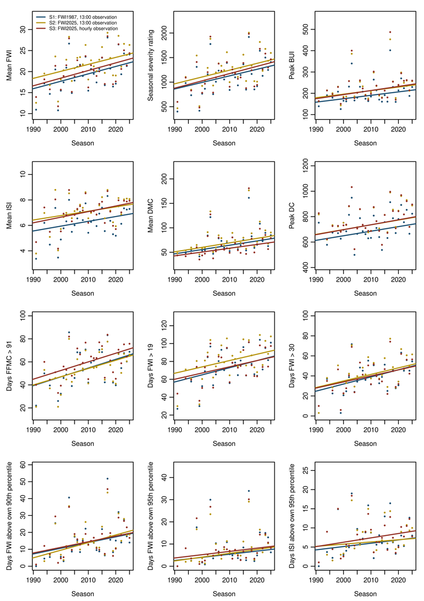

Figure 4. Seasonal metrics by season under the three series, pooled across stations as the station mean. The set of stations reporting changed between seasons, so the points did not follow a fixed set of stations. Each line was drawn through the median point of the station means, with the slope the trend table reported, the median of the per-station Theil-Sen slopes for that series. The second question concerned the extreme-day counts, under the prediction that the absolute counts separated between series and the relative counts did not. FWI was the Fire Weather Index, BUI the Buildup Index and ISI the Initial Spread Index. DMC was the Duff Moisture Code, DC the Drought Code and FFMC the Fine Fuel Moisture Code.

```r
show <- METRICS$col
# Generous bottom margin and tightened axis title placement: at four rows on one
# page the default margin clips the x axis label against the panel below.
op <- par(mfrow = c(4, 3), mar = c(3.8, 4, 1.4, 1), mgp = c(2.4, 0.7, 0),
          cex = 0.62)
for (m in show) {
  ylab <- METRICS$label[match(m, METRICS$col)]
  rng <- range(metrics[[m]], na.rm = TRUE)
  plot(NA, xlim = range(metrics$year), ylim = rng, xlab = "Season", ylab = ylab,
       main = "")
  for (s in names(SERIES)) {
    d <- metrics[metrics$series == s, ]
    a <- aggregate(d[[m]], list(year = d$year), mean, na.rm = TRUE)
    points(a$year, a$x, col = cols[s], pch = 16, cex = 0.6)
    # The line carries the reported estimate, the median of the per-station
    # Theil-Sen slopes in the trend table, through the median point of the
    # station means. A line fitted to the station means would be the basin
    # average the trend chunk avoids, which drops when a cooler station joins.
    sl <- median(trends$slope[trends$series == s & trends$metric == m], na.rm = TRUE)
    abline(a = median(a$x) - sl * median(a$year), b = sl, col = cols[s], lwd = 1.6)
  }
  if (m == show[1])
    legend("topleft", legend = unname(SERIES), col = cols, lwd = 1.6, bty = "n",
           cex = 0.7)
}
par(op)
```

```r
# The direction and strength of the trend picture, computed rather than eyeballed
# off the table, so the sentence below cannot say something the numbers do not.
tr_up <- sum(trends$slope > 0, na.rm = TRUE)
tr_n <- sum(is.finite(trends$slope))
tr_sig <- sum(trends$q < 0.05, na.rm = TRUE)
tr_sig_up <- sum(trends$q < 0.05 & trends$slope > 0, na.rm = TRUE)
# What the autocorrelation correction changed, in tests that would pass on the
# uncorrected variance, corrected within the same families as the reported q
# values, each station's twelve metrics within a series.
would_pass <- sum(unlist(lapply(split(trends$p_uncorrected, list(trends$series, trends$station), drop = TRUE),
  function(p) p.adjust(p, "BH"))) < 0.05, na.rm = TRUE)
infl <- median(trends$n_over_nstar, na.rm = TRUE)
# The two extremes among the extreme-day counts, which share the unit days per
# season, so that the paragraph names its highest and lowest cases rather than
# reporting only a count of how many passed.
day_tr <- trends[trends$metric %in% METRICS$col[METRICS$scheme != "level"], ]
hi <- day_tr[which.max(day_tr$slope), ]
lo <- day_tr[which.min(day_tr$slope), ]
# The twelve metrics as they read inside a sentence, where a table label with
# its symbol would not.
METRIC_PROSE <- c(
  mean_fwi    = "mean Fire Weather Index",
  ssr         = "seasonal severity rating",
  peak_bui    = "peak Buildup Index",
  mean_isi    = "mean Initial Spread Index",
  mean_dmc    = "mean Duff Moisture Code",
  peak_dc     = "peak Drought Code",
  n_ffmc_gt91 = "days with a Fine Fuel Moisture Code above 91",
  n_fwi_gt19  = "days with a Fire Weather Index above 19",
  n_fwi_gt30  = "days with a Fire Weather Index above 30",
  n_fwi_p90   = "days with a Fire Weather Index above the series' own 90th percentile",
  n_fwi_p95   = "days with a Fire Weather Index above the series' own 95th percentile",
  n_isi_p95   = "days with an Initial Spread Index above the series' own 95th percentile")
name_case <- function(r) sprintf("at %s, in %s under %s",
  station_prose(r$station), METRIC_PROSE[[r$metric]], toupper(r$series))
slope_case <- function(r) sprintf("%+.2f days per season, 95 per cent interval %+.2f to %+.2f, q = %s",
  r$slope, r$lower, r$upper, ifelse(r$q < 0.001, "< 0.001", sprintf("%.3f", r$q)))
# Where the trends that passed sit, by station, so that the paragraph names the
# stations rather than leaving the count pooled across them.
sig_station <- sort(tapply(trends$q < 0.05, trends$station, sum, na.rm = TRUE),
                    decreasing = TRUE)
top <- names(sig_station)[1]
top_miss <- unique(trends$metric[trends$station == top & !(trends$q < 0.05)])
top_phrase <- if (length(top_miss)) {
  sprintf("%s, every metric except %s", station_prose(top),
          paste(METRIC_PROSE[top_miss], collapse = " and "))
} else sprintf("%s, every metric", station_prose(top))
min_q_station <- tapply(trends$q, trends$station, min, na.rm = TRUE)
none <- names(sig_station)[sig_station == 0]
none <- none[order(min_q_station[none])]
none_stations <- paste(station_prose(none), collapse = " or ")
none_q <- paste(sprintf("%.3f", min_q_station[none]), collapse = " and ")
# Where the test and the interval disagree, because they answer different
# questions and a reader will set them side by side.
n_sig_inc0 <- sum(trends$q < 0.05 & trends$lower <= 0, na.rm = TRUE)
n_nonsig_excl0 <- sum(trends$q >= 0.05 & (trends$lower > 0 | trends$upper < 0), na.rm = TRUE)
# Where the negative slopes sat, so that the count of positive slopes is read by
# station and metric.
neg <- trends[which(trends$slope < 0), ]
neg_sentence <- if (!nrow(neg)) "" else sprintf(
  "The %d negative slopes were %sat %s, in %s.", nrow(neg),
  if (length(unique(neg$station)) == 1) "all " else "",
  paste(station_prose(unique(neg$station)), collapse = " and "),
  paste(METRIC_PROSE[unique(neg$metric)], collapse = " and in "))
# What the variance correction changed, by direction, and which passing trends
# passed only with it. The uncorrected q values use the same families as would_pass.
n_var_down <- sum(trends$n_over_nstar < 1, na.rm = TRUE)
n_var_up <- sum(trends$n_over_nstar > 1, na.rm = TRUE)
q_unc <- ave(trends$p_uncorrected, trends$series, trends$station,
             FUN = function(p) p.adjust(p, "BH"))
stopifnot(sum(q_unc < 0.05, na.rm = TRUE) == would_pass)
unc_st <- unique(trends$station[which(q_unc < 0.05)])
unc_where <- if (length(unc_st) == 1) paste("all at", station_prose(unc_st)) else
  paste("at", paste(station_prose(unc_st), collapse = " and "))
only_corr <- trends[which(trends$q < 0.05 & !(q_unc < 0.05)), ]
only_corr_sentence <- if (!nrow(only_corr)) "" else sprintf(
  "The %d trends at %s passed only with the correction, which set their variance at %s per cent of its uncorrected value.",
  nrow(only_corr), paste(station_prose(unique(only_corr$station)), collapse = " and "),
  paste(sprintf("%.0f", 100 * only_corr$n_over_nstar), collapse = " and "))
# Passing trends whose interval included zero and whose test variance the
# correction had lowered.
n_sig_inc0_low <- sum(trends$q < 0.05 & trends$lower <= 0 & trends$n_over_nstar < 1, na.rm = TRUE)
# The median slope of the mean Fire Weather Index by station, across series.
fwi_slope_station <- tapply(trends$slope[trends$metric == "mean_fwi"],
                            trends$station[trends$metric == "mean_fwi"], median, na.rm = TRUE)
```

```r
# Whether the station that carried most of the passing trends rose relative to
# its neighbours. The difference between two stations' seasonal means removes
# whatever the basin's weather did to both, so a trend in the difference points
# to the station or its surroundings rather than to the basin. Same estimator
# and test as the trends themselves, on the seasons the two stations share.
nb_rows <- list()
for (s in names(SERIES)) {
  a <- metrics[metrics$series == s & metrics$station_name == top, c("year", "mean_fwi")]
  for (st in setdiff(unique(trends$station), top)) {
    b <- metrics[metrics$series == s & metrics$station_name == st, c("year", "mean_fwi")]
    d <- merge(a, b, by = "year", suffixes = c("_top", "_nb"))
    d <- d[order(d$year), ]
    dd <- d$mean_fwi_top - d$mean_fwi_nb
    mk <- modifiedmk::mmkh(as.vector(dd))
    nb_rows[[length(nb_rows) + 1]] <- data.frame(
      series = s, station = st, n = nrow(d), slope = theil_sen(d$year, dd),
      tau = unname(mk["Tau"]), p = unname(mk["new P-value"]))
  }
}
neighbour <- do.call(rbind, nb_rows)
write.csv(neighbour, file.path(outputs, "neighbour-differences.csv"), row.names = FALSE)
# The neighbour named in the prose is the one sharing most seasons with the
# station, under S1.
nb_main <- neighbour[neighbour$series == "s1", ]
nb_main <- nb_main[which.max(nb_main$n), ]
nb_all_up <- all(neighbour$slope > 0)
# How many neighbours the difference rose against at p below 0.05, by series.
nb_n05 <- tapply(neighbour$p < 0.05, neighbour$series, sum)
nb_word <- function(n) c("none", "one", "two", "three")[n + 1]
```

Across the study window, trends were tested at the 4 stations with at least 15 kept seasons. Of the 144 station, series and metric combinations, 140 had a positive Theil-Sen slope (Table 4, Figure 4). The 4 negative slopes were all at Brenda Mines, in mean Initial Spread Index and in days with an Initial Spread Index above the series’ own 95th percentile. The Mann-Kendall test was run with the Hamed and Rao variance correction and the false discovery rate correction within each station’s twelve-metric family. After both corrections, 35 combinations had a q value below 0.05, all of them positive. Of those, 33 were at Fintry, every metric except peak Buildup Index, and 2 at McCuddy. None was at Penticton RS or Brenda Mines, where the smallest q values were 0.066 and 0.709. Of the 35, 13 had a bootstrap interval that excluded zero and 22 had one that included it. Of the other 109 combinations, 2 had an interval that excluded zero. The ratio of the nominal to the effective sample size had a median of 1.00 and ranged from 0.19 to 1.57. The correction lowered the variance in 19 tests and raised it in 5. On the uncorrected variance, 33 combinations would have passed the same threshold, all at Fintry. The 2 trends at McCuddy passed only with the correction, which set their variance at 19 and 30 per cent of its uncorrected value. The extreme-day counts shared the unit days per season, so their slopes could be ranked. The steepest rise was at Fintry, in days with a Fire Weather Index above 19 under S2. Its slope was +1.70 days per season, 95 per cent interval +0.00 to +3.95, q = 0.007. The steepest fall was at Brenda Mines, in days with an Initial Spread Index above the series’ own 95th percentile under S2. Its slope was -0.08 days per season, 95 per cent interval -0.48 to +0.23, q = 0.717. Across the three series, the median slope of the mean Fire Weather Index was 0.37 units per season at Fintry and 0.17 at Penticton RS. The mean Fire Weather Index at Fintry was also compared with each other station’s on the seasons they shared. Against Penticton RS, the station sharing most seasons with it, the difference rose 0.23 units per season under S1, Kendall tau 0.35, p = 0.020. No p value for these differences was corrected for multiple testing. Across the three series and three neighbours, the slopes of the differences were all positive and the p values ranged from 0.020 to 0.902. The p value was below 0.05 against two of the three neighbours under S1, one under S2 and none under S3.

## 3.4 Version Dependence

```r
CONTRASTS <- list(
  c("s1", "s2", "Version change, input held at 13:00"),
  c("s2", "s3", "Input resolution change, version held at FWI2025"),
  c("s1", "s3", "Operational migration, both changes")
)

diff_rows <- list()
for (cn in CONTRASTS) {
  for (i in seq_len(nrow(METRICS))) {
    m <- METRICS$col[i]
    for (stn in unique(metrics$station_name)) {
      a <- metrics[metrics$series == cn[1] & metrics$station_name == stn,
                   c("year", m)]
      b <- metrics[metrics$series == cn[2] & metrics$station_name == stn,
                   c("year", m)]
      w <- merge(a, b, by = "year", suffixes = c(".a", ".b"))
      names(w)[2:3] <- c("a", "b")
      if (nrow(w) < 15) next
      sd_ <- slope_difference(w)
      sd_$contrast <- cn[3]; sd_$metric <- m; sd_$station <- stn
      sd_$scheme <- METRICS$scheme[i]
      diff_rows[[length(diff_rows) + 1]] <- sd_
    }
  }
}
sdiff <- do.call(rbind, diff_rows)
if (is.null(sdiff) || !nrow(sdiff))
  stop("No station-series pair has the 15 paired seasons the bootstrap requires.")
# The family here is the twelve metrics within one contrast at one station: one
# station's answer to one of the three questions the design asks.
sdiff$q <- ave(sdiff$p_two_sided, paste(sdiff$contrast, sdiff$station), FUN = fdr)
write.csv(sdiff, file.path(outputs, "slope-differences.csv"), row.names = FALSE)
```

```r
sd_tab <- do.call(rbind, lapply(
  split(sdiff, list(sdiff$contrast, sdiff$metric), drop = TRUE), function(d) {
    data.frame(
      Contrast = d$contrast[1],
      Scheme = d$scheme[1],
      Metric = METRICS$label[match(d$metric[1], METRICS$col)],
      Stations = nrow(d),
      `Median difference` = round(median(d$difference, na.rm = TRUE), 3),
      `Stations excluding zero` = sum(d$lower > 0 | d$upper < 0, na.rm = TRUE),
      `Stations q < 0.05` = sum(d$q < 0.05, na.rm = TRUE),
      check.names = FALSE)
  }))
sd_tab <- sd_tab[order(match(sd_tab$Contrast, vapply(CONTRASTS, `[`, "", 3)),
                       match(sd_tab$Metric, METRICS$label)), ]
rownames(sd_tab) <- NULL
fmt_tbl(sd_tab, size = 8)
```

Table 5. Difference in Theil-Sen slope between series, by metric and contrast, pooled across stations as the median. Intervals were paired moving-block bootstrap percentile intervals over 4,000 resamples of blocks of consecutive seasons. The resampling preserved both the dependence between series that shared a weather record and the serial correlation within each. Stations excluding zero counted the stations whose own interval did not contain zero. The last column applied the Benjamini and Hochberg correction within each station’s twelve-metric family for that contrast.

| Contrast | Scheme | Metric | Stations | Median difference | Stations excluding zero | Stations q < 0.05 |
| --- | --- | --- | --- | --- | --- | --- |
| Version change, input held at 13:00 | level | Mean FWI | 4 | -0.005 | 0 | 0 |
| Version change, input held at 13:00 | level | Seasonal severity rating | 4 | -0.085 | 0 | 0 |
| Version change, input held at 13:00 | level | Peak BUI | 4 | 0.146 | 0 | 0 |
| Version change, input held at 13:00 | level | Mean ISI | 4 | -0.001 | 0 | 0 |
| Version change, input held at 13:00 | level | Mean DMC | 4 | 0.042 | 0 | 0 |
| Version change, input held at 13:00 | level | Peak DC | 4 | 0.455 | 0 | 0 |
| Version change, input held at 13:00 | absolute | Days FFMC > 91 | 4 | -0.029 | 0 | 0 |
| Version change, input held at 13:00 | absolute | Days FWI > 19 | 4 | -0.023 | 0 | 0 |
| Version change, input held at 13:00 | absolute | Days FWI > 30 | 4 | -0.057 | 0 | 0 |
| Version change, input held at 13:00 | relative | Days FWI above own 90th percentile | 4 | 0.044 | 0 | 0 |
| Version change, input held at 13:00 | relative | Days FWI above own 95th percentile | 4 | 0.031 | 0 | 0 |
| Version change, input held at 13:00 | relative | Days ISI above own 95th percentile | 4 | -0.020 | 0 | 0 |
| Input resolution change, version held at FWI2025 | level | Mean FWI | 4 | 0.011 | 0 | 0 |
| Input resolution change, version held at FWI2025 | level | Seasonal severity rating | 4 | 0.923 | 0 | 0 |
| Input resolution change, version held at FWI2025 | level | Peak BUI | 4 | 0.247 | 0 | 0 |
| Input resolution change, version held at FWI2025 | level | Mean ISI | 4 | 0.010 | 0 | 0 |
| Input resolution change, version held at FWI2025 | level | Mean DMC | 4 | -0.022 | 0 | 0 |
| Input resolution change, version held at FWI2025 | level | Peak DC | 4 | 0.271 | 0 | 0 |
| Input resolution change, version held at FWI2025 | absolute | Days FFMC > 91 | 4 | -0.021 | 0 | 0 |
| Input resolution change, version held at FWI2025 | absolute | Days FWI > 19 | 4 | -0.062 | 0 | 0 |
| Input resolution change, version held at FWI2025 | absolute | Days FWI > 30 | 4 | -0.048 | 0 | 0 |
| Input resolution change, version held at FWI2025 | relative | Days FWI above own 90th percentile | 4 | -0.038 | 0 | 0 |
| Input resolution change, version held at FWI2025 | relative | Days FWI above own 95th percentile | 4 | -0.030 | 0 | 0 |
| Input resolution change, version held at FWI2025 | relative | Days ISI above own 95th percentile | 4 | 0.017 | 0 | 0 |
| Operational migration, both changes | level | Mean FWI | 4 | 0.005 | 0 | 0 |
| Operational migration, both changes | level | Seasonal severity rating | 4 | 1.006 | 0 | 0 |
| Operational migration, both changes | level | Peak BUI | 4 | 0.373 | 0 | 0 |
| Operational migration, both changes | level | Mean ISI | 4 | 0.006 | 0 | 0 |
| Operational migration, both changes | level | Mean DMC | 4 | 0.036 | 0 | 0 |
| Operational migration, both changes | level | Peak DC | 4 | 0.593 | 0 | 0 |
| Operational migration, both changes | absolute | Days FFMC > 91 | 4 | -0.061 | 0 | 0 |
| Operational migration, both changes | absolute | Days FWI > 19 | 4 | -0.101 | 0 | 0 |
| Operational migration, both changes | absolute | Days FWI > 30 | 4 | -0.105 | 0 | 0 |
| Operational migration, both changes | relative | Days FWI above own 90th percentile | 4 | 0.019 | 0 | 0 |
| Operational migration, both changes | relative | Days FWI above own 95th percentile | 4 | 0.001 | 0 | 0 |
| Operational migration, both changes | relative | Days ISI above own 95th percentile | 4 | -0.035 | 0 | 0 |

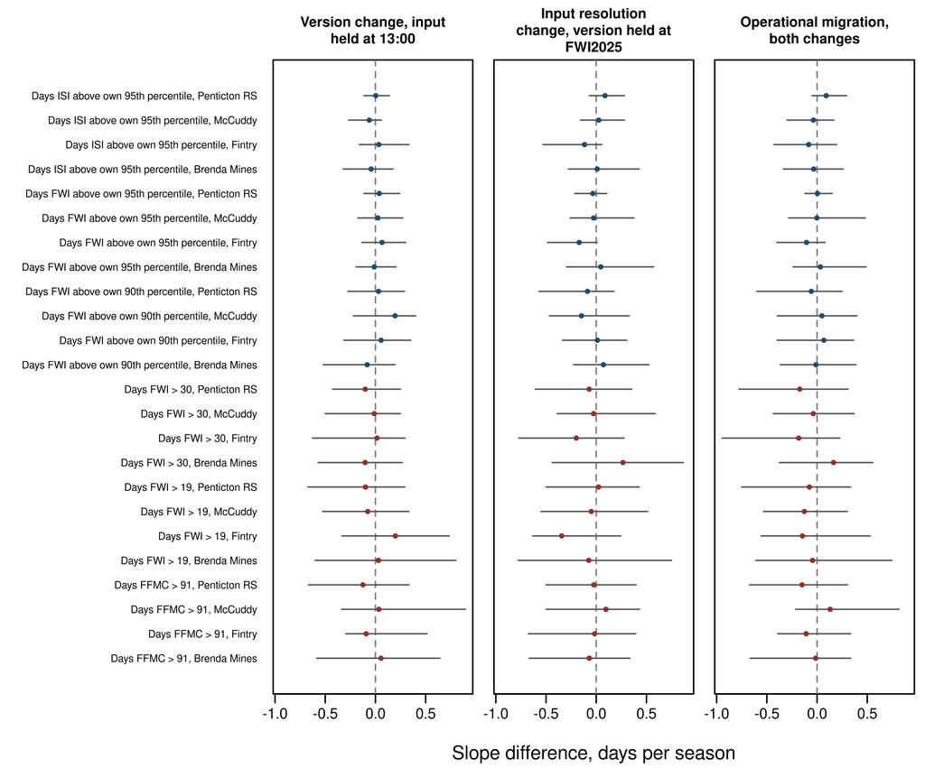

Figure 5. Difference in Theil-Sen slope between series for the six extreme-day counts, which were all measured in days per season and shared one axis. Points were station estimates, and bars were paired moving-block bootstrap 95 per cent intervals over 4,000 resamples of blocks of consecutive seasons. Red marked the three absolute thresholds and blue the three thresholds internal to each series. The prediction under test was that the red points separated from zero and the blue ones did not. FFMC was the Fine Fuel Moisture Code, FWI the Fire Weather Index and ISI the Initial Spread Index.

```r
# Only the metrics measured in days per season are drawn, so one x axis means the
# same thing everywhere on the figure. A common range across the three panels
# keeps the contrasts comparable, and the labels are drawn once on the left.
DAY_METRICS <- METRICS$col[METRICS$scheme %in% c("absolute", "relative")]
sd_plot <- sdiff[sdiff$metric %in% DAY_METRICS, ]
sd_plot$mi <- match(sd_plot$metric, METRICS$col)
xr <- range(c(sd_plot$lower, sd_plot$upper, 0), na.rm = TRUE)

# The left outer margin is sized from the longest row label, so that a longer
# metric name cannot clip the labels as a fixed width did on 2026-10-26.
lab_w <- max(nchar(paste0(METRICS$label[sd_plot$mi], ", ", station_prose(sd_plot$station))))
op <- par(mfrow = c(1, 3), oma = c(1.6, 0.31 * lab_w, 0, 0), mgp = c(2.2, 0.6, 0), cex = 0.62)
for (k in seq_along(CONTRASTS)) {
  cn <- CONTRASTS[[k]]
  d <- sd_plot[sd_plot$contrast == cn[3], ]
  par(mar = c(2.6, 0.6, 3.4, 0.6))
  if (!nrow(d)) { plot.new(); next }
  d <- d[order(d$mi, d$station), ]
  y <- seq_len(nrow(d))
  plot(NA, xlim = xr, ylim = c(0.5, max(y) + 0.5), yaxt = "n",
       xlab = "", ylab = "",
       main = paste(strwrap(cn[3], 24), collapse = "\n"), cex.main = 0.95)
  abline(v = 0, col = "grey50", lty = 2)
  segments(d$lower, y, d$upper, y, col = "grey35")
  points(d$difference, y, pch = 16, cex = 0.8,
         col = ifelse(d$scheme == "absolute", "#943126", "#1B4F72"))
  if (k == 1)
    axis(2, at = y, labels = paste0(METRICS$label[d$mi], ", ", station_prose(d$station)),
         las = 1, cex.axis = 0.7, tick = FALSE, line = -0.3, outer = TRUE)
}
# One axis title under all three panels, because the panels share the axis and
# three titles side by side ran into one another.
mtext("Slope difference, days per season", side = 1, outer = TRUE, line = 0.3, cex = 0.8)
par(op)
```

```r
# The hypothesis has a specific shape: absolute-threshold counts should separate
# between series and relative-threshold counts should not. That shape is scored
# here as two rates, so the sentence below reports what the numbers show rather
# than what the hypothesis predicted.
score <- function(contrast, scheme) {
  d <- sdiff[sdiff$contrast == contrast & sdiff$scheme == scheme, ]
  if (!nrow(d)) return(c(n = 0, sig = 0, rate = NA_real_, med = NA_real_))
  sig <- sum(d$q < 0.05, na.rm = TRUE)
  c(n = nrow(d), sig = sig, rate = 100 * sig / nrow(d),
    med = median(d$difference, na.rm = TRUE))
}
ver_label <- CONTRASTS[[1]][3]
inp_label <- CONTRASTS[[2]][3]
mig_label <- CONTRASTS[[3]][3]
sc <- rbind(
  `version, absolute`   = score(ver_label, "absolute"),
  `version, relative`   = score(ver_label, "relative"),
  `input, absolute`     = score(inp_label, "absolute"),
  `input, relative`     = score(inp_label, "relative"),
  `migration, absolute` = score(mig_label, "absolute"),
  `migration, relative` = score(mig_label, "relative"))
sc <- as.data.frame(sc)
mig_cnt <- sdiff[sdiff$contrast == mig_label & sdiff$scheme %in% c("absolute", "relative"), ]
mig_excl <- sum(mig_cnt$lower > 0 | mig_cnt$upper < 0, na.rm = TRUE)
mig_below <- tapply(mig_cnt$difference < 0, mig_cnt$scheme, sum)
mig_n <- table(mig_cnt$scheme)
mig_dir <- if (mig_below[["absolute"]] > mig_n[["absolute"]] / 2) "the opposite of the prediction" else "the direction predicted"
halves_sentence <- if (sc["version, absolute", "sig"] == 0 && sc["input, absolute", "sig"] == 0)
  "The version change alone, S1 against S2, gave no absolute-threshold slope difference that excluded zero, and neither did the input resolution change alone, S2 against S3." else
  sprintf("The version change alone, S1 against S2, gave %.0f per cent of absolute-metric slope differences excluding zero. The input resolution change alone, S2 against S3, gave %.0f per cent.",
          sc["version, absolute", "rate"], sc["input, absolute", "rate"])
write.csv(sc, file.path(outputs, "hypothesis-scoring.csv"))

# The resolution of the difference test, so that a null is readable. The half
# width of the bootstrap interval is the smallest difference this record could
# have separated from zero at each station and metric.
sdiff$halfwidth <- (sdiff$upper - sdiff$lower) / 2
res_abs <- median(sdiff$halfwidth[sdiff$scheme == "absolute"], na.rm = TRUE)
res_rel <- median(sdiff$halfwidth[sdiff$scheme == "relative"], na.rm = TRUE)
n_any_sig <- sum(sdiff$q < 0.05, na.rm = TRUE)
# The largest difference among the metrics measured in days per season, named
# with its contrast, so that the null is reported beside its nearest case.
day_sd <- sdiff[sdiff$scheme != "level", ]
big <- day_sd[which.max(abs(day_sd$difference)), ]
big_i <- match(big$contrast, vapply(CONTRASTS, `[`, "", 3))
big_a <- toupper(CONTRASTS[[big_i]][1])
big_b <- toupper(CONTRASTS[[big_i]][2])
CONTRAST_PROSE <- c("version change", "input resolution change", "migration")
big_case <- sprintf("at %s, in %s under the %s", station_prose(big$station),
                    METRIC_PROSE[[big$metric]], CONTRAST_PROSE[big_i])

abs_rate <- sc["migration, absolute", "rate"]
rel_rate <- sc["migration, relative", "rate"]
verdict <- if (!is.finite(abs_rate) || !is.finite(rel_rate)) {
  "could not be scored"
} else if (abs_rate == 0 && rel_rate == 0) {
  "divergence under neither scheme, which the design had set as grounds for rejecting the mechanism"
} else if (abs_rate > rel_rate) {
  "the pattern the mechanism predicted"
} else if (abs_rate > 0) {
  "divergence under both schemes, which the design had set as grounds for rejecting the mechanism"
} else {
  "divergence under the percentile scheme alone, the opposite of the pattern the mechanism predicted"
}
```

Across the study window, the migration contrast, S1 against S3, gave divergence under neither scheme, which the design had set as grounds for rejecting the mechanism. None of the migration’s 24 station slope differences in the six extreme-day counts excluded zero (Table 5, Figure 5). Under absolute thresholds, the slope under S3 was below that under S1 in 10 of the 12, the opposite of the prediction, against 7 of 12 under percentile thresholds. Across all 144 station, metric and contrast combinations, none gave a slope difference with a corrected p value below 0.05. The smallest uncorrected p value was 0.125. The largest difference among the day-count metrics was at Fintry, in days with a Fire Weather Index above 19 under the input resolution change. At that station, the slope under S3 was 0.34 days per season below that under S2, 95 per cent interval -0.63 to +0.24, q = 0.771. The bootstrap intervals on the slope differences were summarised by their median half width across the three contrasts. That half width was 0.494 days per season for the absolute-threshold metrics and 0.296 for the relative ones. Over the 34 years from 1991 to 2025, those half widths were 16.8 and 10.1 days respectively. The migration contrast was then split into its two halves. The version change alone, S1 against S2, gave no absolute-threshold slope difference that excluded zero, and neither did the input resolution change alone, S2 against S3. The median differences were -0.044 and -0.038 days per season respectively against -0.092 for the two together.

## 3.5 Ignition Skill

```r
mod_dat <- merge(basin, ign_daily, by = c("date", "year", "doy"))
mod_dat <- mod_dat[format(mod_dat$date, "%m") %in% c("05", "06", "07", "08", "09"), ]

SKILL_RESPONSES <- c("n_lightning_all", "n_total_all")

RESPONSES <- c(n_lightning_all = "Lightning, no size limit",
               n_person_all = "Person-caused, no size limit",
               n_total_all = "All causes, no size limit",
               n_total_ge1ha = "All causes, at least 1 ha",
               n_total_ge4ha = "All causes, at least 4 ha")

ign_rows <- list()
for (r in names(RESPONSES)) {
  for (s in names(SERIES)) {
    dcol <- paste0(s, "_fwi")
    if (!dcol %in% names(mod_dat)) next
    m <- tryCatch(ignition_model(mod_dat, r, dcol, extra = "n_stations"),
                  error = function(e) NULL)
    if (is.null(m)) next
    # Held-out skill is computed only for the two responses the comparison
    # between series is read from. It refits the model once per season, so
    # running it on all five responses costs several hundred fits for numbers
    # the text does not use, and the cost is reported rather than hidden.
    sk <- if (r %in% SKILL_RESPONSES)
      tryCatch(loso_skill(mod_dat, r, dcol), error = function(e) NULL) else NULL
    # Wald interval on the danger coefficient rather than a profile likelihood
    # one. Profiling a negative binomial with a factor per season means refitting
    # once per grid point per model, which dominated the render, and the two
    # agree closely at this sample size. The interval is reported as Wald.
    se <- summary(m)$coefficients[".x", 2]
    ci <- coef(m)[".x"] + c(-1, 1) * qnorm(0.975) * se
    ign_rows[[length(ign_rows) + 1]] <- data.frame(
      response = r, series = s,
      coef = unname(coef(m)[".x"]),
      lower = ci[1], upper = ci[2],
      p = summary(m)$coefficients[".x", 4],
      theta = m$theta,
      loso_loglik = if (is.null(sk)) NA_real_ else sk$mean_loglik,
      n_days = nrow(mod_dat))
  }
}
ign_res <- do.call(rbind, ign_rows)
write.csv(ign_res, file.path(outputs, "ignition-models.csv"), row.names = FALSE)
```

```r
it <- data.frame(
  Response = unname(RESPONSES[ign_res$response]),
  Series = unname(SERIES[ign_res$series]),
  `Coefficient` = round(ign_res$coef, 4),
  `95% Wald interval` = sprintf("%.4f to %.4f", ign_res$lower, ign_res$upper),
  `Rate ratio per 10 FWI` = round(exp(10 * ign_res$coef), 2),
  `Held-out log likelihood` = round(ign_res$loso_loglik, 4),
  check.names = FALSE)
it <- it[order(match(it$Response, unname(RESPONSES)), it$Series), ]
rownames(it) <- NULL
fmt_tbl(it)
```

Table 6. Negative binomial models of daily ignition counts on daily basin Fire Weather Index (FWI), over the 1 May to 30 September window. Each model also included season as a fixed effect, two annual harmonics in day of year and the number of contributing stations. The coefficient was the log change in expected count per unit of Fire Weather Index, identified from within-season variation only. Held-out log likelihood was the mean per day under leave-one-season-out refitting. A larger value was better, and the comparison between series, not the absolute value, was the quantity of interest. The held-out log likelihood was computed for the lightning and all-cause responses with no size limit.

| Response | Series | Coefficient | 95% Wald interval | Rate ratio per 10 FWI | Held-out log likelihood |
| --- | --- | --- | --- | --- | --- |
| Lightning, no size limit | S1: FWI1987, 13:00 observation | 0.0161 | 0.0052 to 0.0269 | 1.17 | -0.4201 |
| Lightning, no size limit | S2: FWI2025, 13:00 observation | 0.0110 | -0.0005 to 0.0225 | 1.12 | -0.4206 |
| Lightning, no size limit | S3: FWI2025, hourly observation | 0.0099 | -0.0003 to 0.0200 | 1.10 | -0.4206 |
| Person-caused, no size limit | S1: FWI1987, 13:00 observation | 0.0480 | 0.0421 to 0.0539 | 1.62 |  |
| Person-caused, no size limit | S2: FWI2025, 13:00 observation | 0.0489 | 0.0428 to 0.0550 | 1.63 |  |
| Person-caused, no size limit | S3: FWI2025, hourly observation | 0.0412 | 0.0360 to 0.0465 | 1.51 |  |
| All causes, no size limit | S1: FWI1987, 13:00 observation | 0.0332 | 0.0289 to 0.0375 | 1.39 | -1.1637 |
| All causes, no size limit | S2: FWI2025, 13:00 observation | 0.0329 | 0.0283 to 0.0374 | 1.39 | -1.1664 |
| All causes, no size limit | S3: FWI2025, hourly observation | 0.0287 | 0.0247 to 0.0327 | 1.33 | -1.1672 |
| All causes, at least 1 ha | S1: FWI1987, 13:00 observation | 0.0706 | 0.0585 to 0.0827 | 2.03 |  |
| All causes, at least 1 ha | S2: FWI2025, 13:00 observation | 0.0702 | 0.0582 to 0.0823 | 2.02 |  |
| All causes, at least 1 ha | S3: FWI2025, hourly observation | 0.0670 | 0.0568 to 0.0772 | 1.95 |  |
| All causes, at least 4 ha | S1: FWI1987, 13:00 observation | 0.0846 | 0.0673 to 0.1018 | 2.33 |  |
| All causes, at least 4 ha | S2: FWI2025, 13:00 observation | 0.0826 | 0.0660 to 0.0992 | 2.28 |  |
| All causes, at least 4 ha | S3: FWI2025, hourly observation | 0.0845 | 0.0706 to 0.0984 | 2.33 |  |

```r
best <- ign_res[ign_res$response == "n_lightning_all", ]
best <- best[order(-best$loso_loglik), ]
skill_gap <- diff(range(best$loso_loglik))

# Does the danger term survive at every size threshold, and does it separate the
# lightning series from the person-caused control? The control matters: human
# ignition tracks population and access, so a danger signal appearing equally in
# both would point to a shared confounder rather than to fuel moisture.
sig_by_response <- tapply(ign_res$p, ign_res$response, function(p) sum(p < 0.05))
rr <- function(resp, s) {
  v <- ign_res$coef[ign_res$response == resp & ign_res$series == s]
  if (!length(v)) NA_real_ else exp(10 * v)
}
rr_light <- rr("n_lightning_all", "s3")
rr_person <- rr("n_person_all", "s3")
rr_ci <- function(resp, s) {
  r <- ign_res[ign_res$response == resp & ign_res$series == s, ]
  sprintf("%.2f to %.2f", exp(10 * r$lower), exp(10 * r$upper))
}
p_light <- setNames(ign_res$p[ign_res$response == "n_lightning_all"],
                    ign_res$series[ign_res$response == "n_lightning_all"])
# The lightning coefficient under each series, and whether its three intervals
# shared a common range, so that near-equal estimates are not split on the 0.05 line.
ign_light <- ign_res[ign_res$response == "n_lightning_all", ]
cf_light <- setNames(ign_light$coef, ign_light$series)
light_overlap <- if (max(ign_light$lower) < min(ign_light$upper)) "overlapped" else "did not all overlap"
# The same held-out comparison for all causes, so that the lightning gap is
# read beside the other response the models scored.
best_all <- ign_res[ign_res$response == "n_total_all", ]
best_all <- best_all[order(-best_all$loso_loglik), ]
skill_gap_all <- diff(range(best_all$loso_loglik))
same_order <- best_all$series[1] == best$series[1] &&
  best_all$series[nrow(best_all)] == best$series[nrow(best)]
order_phrase <- if (same_order) "with the same series first and last" else
  sprintf("with %s first and %s last", toupper(best_all$series[1]),
          toupper(best_all$series[nrow(best_all)]))
# The all-cause danger coefficient at the three minimum fire sizes, the one
# response fitted at each size. The two sentences are chosen from the fits.
size_resp <- c("n_total_all", "n_total_ge1ha", "n_total_ge4ha")
ign_size <- ign_res[ign_res$response %in% size_resp, ]
stopifnot(nrow(ign_size) == length(size_resp) * length(SERIES))
size_all_sig <- all(ign_size$coef > 0 & ign_size$p < 0.05)
size_rises <- all(vapply(names(SERIES), function(s) {
  d <- ign_size[ign_size$series == s, ]
  all(diff(d$coef[match(size_resp, d$response)]) > 0)
}, logical(1)))
size_sig_sentence <- if (size_all_sig)
  "At all three sizes and under every series, the coefficient was positive with a p value below 0.05." else
  "The coefficient was not positive with a p value below 0.05 at every size and under every series."
size_rise_sentence <- if (size_rises)
  "Under every series, the coefficient rose with each increase in the minimum size." else
  "The coefficient did not rise with each increase in the minimum size under every series."
```

Over the summer window, the danger term in the negative binomial ignition models was the coefficient on the daily basin Fire Weather Index. The coefficient was positive with a p value below 0.05 for 13 of the 15 response and series combinations (Table 6). The person-caused response was significant under every series. The lightning coefficient was 0.016 under S1, 0.011 under S2 and 0.010 under S3, with p = 0.004, 0.062 and 0.057. The three 95 per cent intervals of the lightning coefficient overlapped. Under S3, ten units of Fire Weather Index multiplied the expected daily person-caused count by 1.51, 95 per cent interval 1.43 to 1.59. The same ten units multiplied the expected daily lightning count by 1.10, interval 1.00 to 1.22. Under S1, the fitted dispersion parameter was 0.11 for the lightning series against 2.97 for the person-caused one, a smaller value meaning more clustered counts. The all-cause coefficient was also estimated for fires of at least one hectare and of at least four hectares. At all three sizes and under every series, the coefficient was positive with a p value below 0.05. Under every series, the coefficient rose with each increase in the minimum size.

The third question was whether the Fire Weather Index of any series predicted daily ignitions better. On held-out seasons, the three series differed by 0.0005 in mean log likelihood per day for lightning ignitions. S1 was first at -0.4201 and S3 last at -0.4206. Over the 4,743 days in the window, the lightning gap totalled about 2.3 log likelihood units. For all causes, the gap was 0.0035 per day and about 16.5 units in total, with the same series first and last.

```r
# Is the danger to ignition relationship stationary? The test is an interaction
# between the danger term and season number. Season is already a fixed effect,
# so the interaction asks whether the within-season slope changes over the
# record, which is a different question from whether the intercept does.
stat_rows <- list()
for (r in c("n_lightning_all", "n_total_all")) {
  for (s in names(SERIES)) {
    dcol <- paste0(s, "_fwi")
    d <- mod_dat
    d$.yc <- d$year - mean(d$year)
    m <- tryCatch(ignition_model(d, r, dcol, extra = "I(.x * .yc)"),
                  error = function(e) NULL)
    if (is.null(m)) next
    cf <- summary(m)$coefficients
    nm <- grep("I\\(.x", rownames(cf), value = TRUE)[1]
    stat_rows[[length(stat_rows) + 1]] <- data.frame(
      response = r, series = s,
      interaction = cf[nm, 1], se = cf[nm, 2], p = cf[nm, 4])
  }
}
stationarity <- do.call(rbind, stat_rows)
write.csv(stationarity, file.path(outputs, "stationarity-tests.csv"),
          row.names = FALSE)
n_stat_sig <- sum(stationarity$p < 0.05, na.rm = TRUE)
```

Across the record, an interaction between the danger term and season number tested whether the danger to ignition relationship changed linearly with time. The interaction was fitted for the lightning and all-cause responses under each series. None of the 6 interaction terms had a p value below 0.05, and the p values ranged from 0.715 to 0.947.

# 4 Discussion

```r
# The basin's percentile-day trend beside the published global rate, as a share,
# so that the sentence states the comparison and not two numbers side by side.
rel95_season <- median(trends$slope[trends$metric == "n_fwi_p95"], na.rm = TRUE)
rel95_decade <- 10 * rel95_season
GLOBAL_P95_DECADE <- 2.65   # Matteo et al. (2025), days per decade over 1980 to 2023
# The trend this record could detect in the same count, per decade, so that the
# basin's rate is read against it and not as a share of the global rate.
rel95_mdt_decade <- 10 * median(trends$mdt[trends$metric == "n_fwi_p95"], na.rm = TRUE)
rel95_word <- if (rel95_decade < rel95_mdt_decade) "smaller than" else "not smaller than"
# The station that carried most passing trends against its named neighbour, on
# the median slope of the mean Fire Weather Index.
fwi_slope_station <- tapply(trends$slope[trends$metric == "mean_fwi"],
                            trends$station[trends$metric == "mean_fwi"], median, na.rm = TRUE)
# Which neighbours the station pulled away from under S1, named, so that a flat
# difference is reported beside the rising ones.
nb_s1 <- neighbour[neighbour$series == "s1", ]
nb_up <- nb_s1$station[nb_s1$p < 0.05]
nb_flat <- nb_s1$station[nb_s1$p >= 0.05]
nb_phrase <- if (!length(nb_flat)) {
  sprintf("against every neighbour, %s", paste(station_prose(nb_up), collapse = " and "))
} else if (!length(nb_up)) {
  "against none of the three neighbours at p below 0.05 with no correction for multiple testing"
} else sprintf("against %s, at p below 0.05 with no correction for multiple testing, and not against %s",
               paste(station_prose(nb_up), collapse = " and "),
               paste(station_prose(nb_flat), collapse = " or "))
# Direction words for the prose, computed so that a sentence cannot assert a sign
# the numbers do not show. Rows 3 to 5 of shift are the spread index and the two
# slow codes.
slow_phrase <- if (all(shift$version[4:5] > 0)) {
  "the Duff Moisture Code and the Drought Code to the dry side"
} else if (all(shift$version[4:5] < 0)) {
  "the Duff Moisture Code and the Drought Code to the wet side"
} else "the Duff Moisture Code and the Drought Code in opposite directions"
reverse_phrase <- if (sign(shift$input[1]) == -sign(shift$version[1]) &&
                      sign(shift$input[2]) == -sign(shift$version[2])) {
  "The input change did the reverse."
} else "The input change did not simply reverse it."
# Slope differences excluding zero among the four metrics added for the rewritten
# components, over all three contrasts.
new_metric_names <- c("mean_isi", "mean_dmc", "peak_dc", "n_isi_p95",
                      "Mean ISI", "Mean DMC", "Peak DC", "Days ISI above own 95th percentile")
sd_new <- sdiff[sdiff$metric %in% new_metric_names, ]
stopifnot(nrow(sd_new) == 4 * length(unique(sdiff$station)) * length(unique(sdiff$contrast)))
n_excl_new <- sum(sd_new$lower > 0 | sd_new$upper < 0, na.rm = TRUE)
excl_word <- if (n_excl_new == 0) "None" else as.character(n_excl_new)
# Where the two changes oppose, what survives is the residual, and how much
# survives is the whole point. Cancellation is measured as the migration shift
# relative to the larger of the two component shifts.
same_sign <- function(i) sign(shift$version[i]) == sign(shift$input[i])
ffmc_word <- if (same_sign(1)) "compounded" else "opposed one another"
fwi_word <- if (same_sign(2)) "compounded" else "opposed one another"
residual <- function(i) {
  abs(shift$migration[i]) / max(abs(shift$version[i]), abs(shift$input[i]))
}
ffmc_res <- residual(1); fwi_res <- residual(2)
bigger <- function(i) if (abs(shift$version[i]) > abs(shift$input[i]))
  "the version change" else "the input resolution change"
# The slope a line would read from a step of the migration's size placed at
# mid-record, under the estimator the study used, so that the consequence of
# joining a count series across the change is a number rather than a warning.
yrs <- yr_first:yr_last
step <- c(rep(0, floor(length(yrs) / 2)), rep(shift$migration[1], ceiling(length(yrs) / 2)))
step_slope <- theil_sen(yrs, step)
step_window <- step_slope * (yr_last - yr_first)
step_pct <- 100 * step_slope / median(trends$slope[trends$metric == "n_ffmc_gt91"], na.rm = TRUE)
```

Over 1991 to 2025 in the Okanagan basin of British Columbia, the Canadian Forest Fire Weather Index System was run as three series on one weather record. One pair of series held the 13:00 observation fixed and changed the version, which included the report’s reconstruction of hourly weather and the 16:00 daily value. The other pair held the version fixed and replaced the reconstructed hourly weather with the observed. The revision moved the count of extreme days and moved no trend this record could resolve. The predicted divergence in slope appeared under neither thresholding scheme, so the mechanism was not supported at this record’s resolution. On held-out seasons, the Fire Weather Index of the three series differed in skill by 0.0005 log likelihood units per day for lightning ignitions and 0.0035 for all causes.

## 4.1 Trends

Over 1991 to 2025, days with a Fire Weather Index above the series’ own 95th percentile rose by a median of 0.15 per season across stations and series. That rate was 1.5 days per decade. Worldwide over 1980 to 2023 in a reanalysis, the same count “increased by 2.65 days per decade” (Matteo et al., 2025). The basin’s median rate was smaller than the 6.0 days per decade this record could detect at 90 per cent power.

Of the 35 trends with q below 0.05, 33 were at Fintry. At that station, the median slope of the mean Fire Weather Index was 0.37 units per season, against 0.17 at Penticton RS. The difference between two stations’ seasonal means removed whatever the basin’s weather did to both. A trend in that difference would therefore indicate a change at the station or its surroundings rather than across the basin. Under S1, the difference rose against Penticton RS and McCuddy, at p below 0.05 with no correction for multiple testing, and not against Brenda Mines. Under S3, the p value was below 0.05 against none of the three neighbours. A change at the station entered all three series through the one weather record, so it was unlikely to move the comparison between series. The sensor history was unavailable, so a change at the site could not be separated from a local change in the weather.

The Mann-Kendall test asked whether a series rose, and the block bootstrap asked how far the slope could lie under resampled seasons. Of the 35 trends that passed the test, 13 had an interval that excluded zero and 22 had one that included it. In 6 of those 22, the variance correction had lowered the variance of the test. The test and the interval therefore agreed on 13 trends.

## 4.2 Version and Input

The two changes were large and had opposite signs, so a straight comparison of FWI1987 against FWI2025 would have been uninterpretable. On the count of days above a Fine Fuel Moisture Code of 91, the two opposed one another and the input resolution change was the larger. On the count above a Fire Weather Index of 19, the two opposed one another almost exactly, and the migration’s net change was 4 per cent of the larger component. That near cancellation was a coincidence of two large effects at one place. It was not to be expected at a site with a different diurnal range, the difference in temperature and humidity between night and day. Before the revision, Hanes et al. (2021, p. 2) had written that “while modifications to the FWI System are being planned to reproduce the general existing range in observed outputs, some differences in the frequency of occurrence of different codes or index values may result”. The counts of days above fixed thresholds differed in that way in this basin.

The two changes did not move the counts in the directions expected. In the Northwest Territories, the hourly code of 1977 and the diurnally adjusted code had both “consistently overestimated the minimum moisture content” of needle litter and feathermoss on dry days (Beck and Armitage, 2004, pp. 213, 218). FWI2025 cut in half the time lag of the 1977 hourly Fine Fuel Moisture Code, so that fine fuels dried faster (Canadian Forest Service Fire Danger Group, 2025, p. 18). It nonetheless lowered the count of days above a Fine Fuel Moisture Code of 91 and raised the count above a Fire Weather Index of 19. The input change did the reverse. At five stations in the Alps over 1951 to 2010, “Regional differences were highest for the FFMC, followed by the DMC and the DC, and could be attributed to the time lag of different forest soil layers” (Wastl et al., 2013, abstract). Faster drying should therefore have acted most strongly on the Fine Fuel Moisture Code and the counts built from it, which this record did not show. Rodrigues et al. (2020) noted of the Fire Weather Index that “a same result may be produced by different combinations of weather variables” (Rodrigues et al., 2020, abstract). Two changes acting on different parts of the calculation could therefore offset in the combined index while remaining visible in its parts.

At fixed 13:00 input, the version change moved the Duff Moisture Code and the Drought Code to the dry side. The report had expected its cumulative rain thresholds to “err to the dry side of fuel moisture” on “days where two rainfall events are spaced apart by more than six hours” (Canadian Forest Service Fire Danger Group, 2025, p. 21). On days with one main rain event, it expected “little to no difference” (Canadian Forest Service Fire Danger Group, 2025, p. 21). Pathway C placed each day’s rain in the first hour after sunrise, so the rain thresholds could explain little of the rise at fixed input. Drying over each daylight hour, in place of the monthly day length factors (Canadian Forest Service Fire Danger Group, 2025, p. 20; Van Wagner, 1987a, pp. 12, 14), was consistent with that rise. The migration left the Duff Moisture Code lower and the Drought Code higher than under FWI1987. The hourly input lowered the mean Duff Moisture Code by 9.2 units. The report noted that placing once-daily rain after sunrise, with drying over the full day, “can bias the fuel moisture calculations to the drier side” (Canadian Forest Service Fire Danger Group, 2025, p. 9). S2 had that placement and S3 took rain at its observed hour. The mean Initial Spread Index rose under the version change despite the new wind cap. That was consistent with a 16:00 daily value taken nearer the afternoon peak than the 13:00 observation. Four metrics measured the rewritten components, the mean Initial Spread Index, the mean Duff Moisture Code, the peak Drought Code and days above the spread index’s own 95th percentile. None of the four had a slope difference that excluded zero in any contrast.

At Camden, New South Wales, three fire danger systems were compared on thirteen years of station data, each at its own observation time (Matthews, 2009). Differences in how each took in the weather “cancelled out some of the differences in structure” (Matthews, 2009, p. 41). The version and input effects did the same here for days above a Fire Weather Index of 19. That study followed no trend through the change. The one measured effect of input timing on a slope came from a global count of extreme days. In that count, the difference between daily aggregates and noon weather had a trend of 0.22 to 0.39 days per decade (Matteo et al., 2025). Over this window, that would have amounted to 0.7 to 1.3 days, against a median interval half width of 10.1 days for the percentile counts here. The null slope result therefore bounded the effect rather than excluding it.

The clearest difference between the two FWI2025 series was not in any level but in the burning window. Both series followed the report’s own procedures, so an agency that migrated to FWI2025 while still supplying a 13:00 observation would receive outputs computed from an assumed diurnal curve. The report had said as much, warning that “any weather estimate, including those derived from our methods, involves inherent assumptions” (Canadian Forest Service Fire Danger Group, 2025, p. 30). A daily index could not say when the peak arrived or how long it lasted. The report noted that its hour of peak burn “represents a mathematical maximum and does not provide an indication of how sharp or flat that ‘peak’ is” (Canadian Forest Service Fire Danger Group, 2025, p. 27). It added that “the width of the burning window on a particular day may also be a useful addition” (Canadian Forest Service Fire Danger Group, 2025, p. 27). The hourly series reported both without predicting ignitions better.

The small difference in ignition skill between series was consistent with comparisons of danger indices against fire records elsewhere. In Mediterranean France, “the Canadian FWI remains the most skillful indicator among the tested indices” (Castel-Clavera et al., 2025, abstract). The same study found that “relying solely on fire-weather indices is insufficient” and that “the inclusion of spatial and seasonal effects in the models is crucial” (Castel-Clavera et al., 2025, abstract). The models here included the seasonal effect, and a model of one basin mean had no spatial effect to include. Across 11 regions from the European Alps to the Mediterranean basin, models that ranked fire occurrence well could still perform poorly on burned area (Bekar et al., 2023). The ignition counts tested here therefore could not show whether the three series would differ on area burned. The 2008 weather guide had warned that a change in how day length entered the Duff Moisture and Drought Codes would leave past calibrations “rendered invalid” (Lawson and Armitage, 2008, p. 71). The ignition models used only the Fire Weather Index, each fitted under its own series, so they did not test whether a calibration fitted under FWI1987 held under FWI2025. Under each series, no interaction between danger and season had a p value below 0.05, so no change in the relationship over the record was detected.

## 4.3 Published Trends

No slope difference under the migration excluded zero at any station, under either thresholding scheme. The consequence for the published record therefore rested on the level result alone. Within its reference period, a count of percentile exceedances was set by the percentile and not by the version, because each threshold came from its own series’ distribution. In the United States system at Missoula, Montana, over 1999 to 2008, changing the fuel model moved the 97th percentile of the Energy Release Component from 69 to 39 (Heinsch et al., 2009, p. 4). The Energy Release Component was one of that system’s fire danger indices (Heinsch et al., 2009, p. 1). With the classes set at percentiles, “a similar number of days fall in each class” under either fuel model (Heinsch et al., 2009, p. 4).

A series of counts above a fixed danger class included the level shift. Joined across the change, such a series would have a step at the join, which a fitted line would estimate as a trend. A step of 4.7 days per season at mid-record, the migration’s size at a Fine Fuel Moisture Code of 91, gave a Theil-Sen slope of 0.15 days per season. That slope amounted to 5.1 days over the window and was 20 per cent of the median slope observed in that count, 0.75 days per season. An archive of operational index values could hold such a join with no record of it. In mainland Portugal, Nunes and Guerra (2026) took the Fire Weather Index stored with each fire record of 2001 to 2024, without recalculating it (Nunes and Guerra, 2026, p. 3). The “exact procedure used to assign daily FWI to individual ignitions could not be independently reconstructed” (Nunes and Guerra, 2026, p. 12).

Of the trends cited here, the extreme days of Matteo et al. (2025) were percentile exceedances, whose count within a reference period no version change altered. The spread days of Jain et al. (2017), the threshold days of Wastl et al. (2012) and the mean index of Queen et al. (2025) were fixed thresholds or levels. In this basin, the version change at fixed input moved the count above a Fire Weather Index of 19 by +7.3 days per season. The migration moved the same count by -0.3 days. The fire weather days of Richardson et al. (2022) were counted on the McArthur Forest Fire Danger Index, which the version change did not touch (Richardson et al., 2022, p. 7). A percentile trend was comparable across the version change only when its reference period was stated and kept fixed, with the base-period bias corrected where the record ran beyond it (Zhang et al., 2005).

Fixed classes were already regional and tied to the period that calibrated them. In 1977, British Columbia rated fire danger in five classes, of which Class V was the highest (Lawson, 1977, p. 15). The province’s Class V needed a Fire Weather Index above 46 and a Buildup Index above 90 in the region holding the Thompson-Okanagan valleys (Lawson, 1977, pp. 14–15). In its coast and wet interior region, every day above a Fire Weather Index of 30 was Class V (Lawson, 1977, p. 15). In Ontario, the classes were set so that the Extreme class held “2% of fire season days” (Hanes et al., 2021, abstract). By 2021, modifications “would still be warranted as the values no longer reflect the original frequency of occurrence expectations”, even if Ontario kept its existing classes (Hanes et al., 2021, abstract). In Canada’s forests over 2001 to 2021, the Fire Weather Index below which half the area burned was 20.1, with a standard deviation of 0.5 (Wang et al., 2025b, p. 5). By ecozone, the same threshold ran from 12.9 in the Taiga Cordillera to 25.3 in the Montane Cordillera, with standard deviations of 1.9 and 3.0 (Wang et al., 2025b, p. 6).

Nothing here showed the published trends to be wrong, but they were statements about FWI1987. Restating them under FWI2025 would change the level of some by an amount set by the metric’s definition rather than by the weather. A level shift that did not alter the relative change had been reported before in this index. Quilcaille et al. (2023) found that computing the Fire Weather Index from mean rather than minimum humidity reduced it “by about −33 % (June) above 20° N” (Quilcaille et al., 2023, p. 2162). The reduction was “roughly identical during the fire seasons across the planet, be it over 1994–2014 or 2081–2100” (Quilcaille et al., 2023, p. 2164). Mortelmans et al. (2024), working with the peatland-specific land surface model PEATCLSM, instead “matched the temporal cumulative density functions (CDFs) of the PEATCLSM output variables” to those of the moisture codes in each grid cell (Mortelmans et al., 2024, p. 448). That step kept the percentile of a day fixed within the matching period, and so the counts above percentile thresholds, while leaving the absolute counts to move. It was the same split between the two threshold families reported here. A historical trend re-expressed in the new system’s units should therefore be recomputed over the whole record rather than joined across the change, and reported with its metric family.

In 2024, the introduction to a joint special issue on good modelling practice named a last phase, model perpetuation, for models that support “ongoing decision making or operational processes” (Jakeman et al., 2024, p. 3). The phase included “ensuring that plans and mechanisms are in place for appropriately monitoring, maintaining and updating the model” (Jakeman et al., 2024, p. 3). Jakeman et al. (2024, p. 3) judged that existing suggestions of good practice “tend to focus on the model set up (phase 3), whereas the other phases are at least equally important”. Their conclusion named “a next crucial step”, the “more thorough justification of decisions, wherever possible stating the comparative effect of decision options on the outcomes of the modeling” (Jakeman et al., 2024, p. 11). The 2025 revision updated a model in operational use, and the three series stated that effect for two decision options an agency faced, the version and the input resolution.

## 4.4 Limitations

```r
# The quantitative limits statement. For each metric the minimum detectable trend
# is the slope this record could resolve at 90 per cent power, given the residual
# spread of that metric about its own Theil-Sen line. Expressing it over the whole
# window rather than per season is what makes it legible: a slope of 0.3 days per
# season is 10 days over 34 seasons, and the second number is the one a reader can
# judge.
lim <- do.call(rbind, lapply(split(trends, trends$metric), function(d) {
  mdt <- median(d$mdt, na.rm = TRUE)
  data.frame(
    Metric = METRICS$label[match(d$metric[1], METRICS$col)],
    `Median observed slope` = round(median(d$slope, na.rm = TRUE), 3),
    `Minimum detectable trend` = round(mdt, 3),
    `Minimum detectable change over the window` =
      round(mdt * (yr_last - yr_first), 2),
    `Observed change over the window` =
      round(median(d$slope, na.rm = TRUE) * (yr_last - yr_first), 2),
    check.names = FALSE)
}))
lim <- lim[order(match(lim$Metric, METRICS$label)), ]
rownames(lim) <- NULL
write.csv(lim, file.path(outputs, "detectability.csv"), row.names = FALSE)
# How many metrics moved by less over the window than the record could detect.
n_below <- sum(abs(lim[["Observed change over the window"]]) <
                 lim[["Minimum detectable change over the window"]])
```

```r
fmt_tbl(lim)
```

Table 7. What a window of this length could and could not resolve. The minimum detectable trend was the slope at which a two-sided test at alpha 0.05 reached 90 per cent power. The power was computed from the residual spread of that metric about its own Theil-Sen line. The slope was adjusted for the efficiency of the Theil-Sen estimator relative to least squares and inflated for lag-one autocorrelation of the residuals. A metric whose observed change was smaller than its minimum detectable change was not evidence of no trend. Such a metric was evidence that this record could not detect a trend of that size.

| Metric | Median observed slope | Minimum detectable trend | Minimum detectable change over the window | Observed change over the window |
| --- | --- | --- | --- | --- |
| Mean FWI | 0.180 | 0.308 | 10.46 | 6.14 |
| Seasonal severity rating | 13.486 | 26.895 | 914.43 | 458.54 |
| Peak BUI | 1.740 | 6.024 | 204.81 | 59.17 |
| Mean ISI | 0.040 | 0.089 | 3.04 | 1.37 |
| Mean DMC | 0.883 | 2.363 | 80.34 | 30.02 |
| Peak DC | 3.639 | 10.650 | 362.11 | 123.72 |
| Days FFMC > 91 | 0.751 | 1.081 | 36.76 | 25.54 |
| Days FWI > 19 | 0.739 | 1.551 | 52.74 | 25.11 |
| Days FWI > 30 | 0.625 | 1.295 | 44.04 | 21.25 |
| Days FWI above own 90th percentile | 0.372 | 0.900 | 30.60 | 12.66 |
| Days FWI above own 95th percentile | 0.149 | 0.598 | 20.33 | 5.07 |
| Days ISI above own 95th percentile | 0.070 | 0.443 | 15.06 | 2.39 |

Table 7 gave the quantitative form of what this study could not say. A null result and an underpowered result looked identical in a table of p values and were different claims. The median observed change over the window was smaller than the minimum detectable change in all 12 metrics.

The study covered only the Canadian part of one basin, so whether the version effect had the same size elsewhere was untested. The study detected change and did not attribute it, because attribution required a comparison against a world without anthropogenic forcing, the human contribution to climate change (Kirchmeier-Young et al., 2019, p. 4). Four further limits applied to the absolute trends. Each limit applied in the same way to all three series, so it was unlikely to move the comparison between series. No index of the El Niño Southern Oscillation or the Pacific Decadal Oscillation entered any model. A window that began and ended in different phases of those oscillations therefore biased the absolute trends. The sensor history of the stations was not available. At 75 airport stations across Canada, van Wijngaarden and Vincent (2005) found that replacing the psychrometer by the dewcel “produced a decreasing step in relative humidity at a number of stations” (van Wijngaarden and Vincent, 2005, p. 1). Fuel typing did not vary through time, so a danger effect was not distinguished from fuel accumulation. The fixed window from 1 May to 30 September could not register a season that lengthened at either end. If the true season lengthened, trends in window counts understated trends in the season.

A year-round climate station, of the kind Hanes et al. (2020) used for winter precipitation, would recover the season from this basin. It would also allow the Drought Code to be overwintered rather than restarted each spring. McElhinny et al. (2020) showed that the restart changed the count of spread days.

# 5 Conclusions

```r
# The numbers the conclusions rest on, pulled from the objects above rather than
# retyped. A missing object stops the render rather than printing a hedge.
c_days_gap <- d_s3 - d_s1
c_pct_gap <- 100 * c_days_gap / d_s1
c_dur <- ct$`Mean burning window (h)`[grepl("S3", ct$Series)] -
  ct$`Mean burning window (h)`[grepl("S2", ct$Series)]
stopifnot(length(c_dur) == 1, is.finite(c_dur))
c_abs_rate <- sc["migration, absolute", "rate"]
c_rel_rate <- sc["migration, relative", "rate"]
# The verdict as a sentence of its own, under the same five conditions the
# Results chunk scores, so the conclusion cannot assert a pattern the rates do
# not show.
c_verdict <- if (!is.finite(c_abs_rate) || !is.finite(c_rel_rate)) {
  "The divergence could not be scored."
} else if (c_abs_rate == 0 && c_rel_rate == 0) {
  "Divergence appeared under neither scheme, which the design had set as grounds for rejecting the mechanism."
} else if (c_abs_rate > c_rel_rate) {
  "That was the pattern the mechanism predicted."
} else if (c_abs_rate > 0) {
  "Divergence appeared under both schemes, which the design had set as grounds for rejecting the mechanism."
} else {
  "Divergence appeared under the percentile scheme alone, the opposite of the pattern the mechanism predicted."
}
# When nothing diverged, one sentence says so; otherwise the two rates and the
# verdict are printed in full.
c_migration <- if (is.finite(c_abs_rate) && is.finite(c_rel_rate) &&
                   c_abs_rate == 0 && c_rel_rate == 0) {
  "No slope difference under the migration excluded zero at any station, under fixed or percentile thresholds, so the predicted mechanism was not supported."
} else {
  sprintf("Under the migration, the slope difference excluded zero at %.0f per cent of station-metric combinations under fixed thresholds and at %.0f per cent under percentile thresholds. %s",
          c_abs_rate, c_rel_rate, c_verdict)
}
```

Over 31 seasons in the Okanagan basin, the Canadian Forest Fire Weather Index System was run in both versions, FWI1987 and FWI2025, on one record. Slopes were positive in 140 of 144 station, series and metric combinations, and 35 passed the corrected test. Of those, 33 were at Fintry. Under FWI1987, the mean Fire Weather Index at Fintry also rose relative to two of its three neighbours, at p below 0.05 with no correction for multiple testing. The 2025 report gave a Fine Fuel Moisture Code of 91 as its example of continuity. That threshold selected 4.7 more days per season under FWI2025 on hourly weather than under FWI1987, a change of 8 per cent. No slope difference under the migration excluded zero at any station, under fixed or percentile thresholds, so the predicted mechanism was not supported. Across the three contrasts, the 95 per cent intervals had a median half width of 16.8 days over the window under fixed thresholds and 10.1 under percentile ones. At fixed input, the version change moved the Duff Moisture Code and the Drought Code to the dry side and raised the mean Initial Spread Index. No slope difference in the metrics of those components excluded zero.

Fire danger trends should be reported as days above a percentile of the series itself, not as counts above a fixed danger class. The percentile moved with its distribution across the version change and the class boundary did not. A count series joined across the change at mid-record would have a step of 4.7 days per season. A Theil-Sen line fitted to that step alone had a slope of 0.15 days per season. Each version’s threshold should come from that version’s own series over one stated and fixed reference period. The base-period bias should be corrected where the record ran beyond that period. A record spanning the change should be recomputed under one stated version and not joined across the change. The recommendation rested on the level result in one basin, and the study attributed no change to a cause. For daily ignition counts, the Fire Weather Index of the three series gave held-out log likelihoods within 0.0035 per day of one another. No change in the relationship between danger and ignitions over the record was detected. In this basin, the mean burning window was 3.7 hours per day shorter under the reconstructed diurnal curve than under the observed hourly weather.